# Data wrangling WeRateDogs DAND project

# Introduction

Data wrangling is one of the core skill that everyone who works with data should be familiar with since so much of the world's data isn't clean. We need to wrangle our data for good outcomes, otherwise there could be consequences. If we analyze, visualize, or model our data before we wrangle it, our consequences could be making mistakes, missing out on cool insights, and wasting time. So best practices say wrangle. Always.

Through this project will gather data from a variety of sources and in a variety of formats, assess its quality and tidiness, then clean it.

The dataset that we will be wrangling (and analyzing and visualizing) is the tweet archive of Twitter user **@dog_rates**, also known as WeRateDogs.

# Gather

Gathering Data for this Project composed from three pieces of data as described below:

•The WeRateDogs Twitter archive. We will download this file manually the file name: twitter_archive_enhanced.csv

•The tweet image predictions, i.e., what breed of dog (or other object, animal, etc.) is present in each tweet according to a neural network. This file (image_predictions.tsv) hosted on Udacity's servers and should be downloaded programmatically using the Requests library and the following URL: https://d17h27t6h515a5.cloudfront.net/topher/2017/August/599fd2ad_image-predictions/image-predictions.tsv

•Each tweet's retweet count and favorite (i.e. "like") count at minimum, and any additional data we will find interesting. Using the tweet IDs in the WeRateDogs Twitter archive, we will query the Twitter API for each tweet's JSON data using Python's Tweepy library and store each tweet's entire set of JSON data in a file called tweet_json.txt file. Each tweet's JSON data should be written to its own line. Then we will read this .txt file line by line into a pandas DataFrame with (at minimum) tweet ID, retweet count, and favorite count.

#### Lets Start

```python
import pandas as pd
import numpy as np
import requests
import tweepy
import json
import time
from IPython.display import clear_output
import re
import matplotlib.pyplot as plt
import seaborn as sns
% matplotlib inline
```

```python
# check the twitter archive csv file, which is downloaded manually
twitter_archive = pd.read_csv('twitter-archive-enhanced.csv')
twitter_archive.head()
```

|  | tweet_id | in_reply_to_status_id | in_reply_to_user_id | timestamp | source | text | retweeted_status_id | retweeted_status_user_id | retweeted_status_timestamp | expanded_urls | rating_numerator | rating_denominator | name | doggo | floofer | pupper | puppo |
| --- | --- | --- | --- | --- | --- | --- | --- | --- | --- | --- | --- | --- | --- | --- | --- | --- | --- |
| 0 | 892420643555336193 | NaN | NaN | 2017-08-01 16:23:56 +0000 | <a href="http://twitter.com/download/iphone" r... | This is Phineas. He's a mystical boy. Only eve... | NaN | NaN | NaN | https://twitter.com/dog_rates/status/892420643... | 13 | 10 | Phineas | None | None | None | None |
| 1 | 892177421306343426 | NaN | NaN | 2017-08-01 00:17:27 +0000 | <a href="http://twitter.com/download/iphone" r... | This is Tilly. She's just checking pup on you.... | NaN | NaN | NaN | https://twitter.com/dog_rates/status/892177421... | 13 | 10 | Tilly | None | None | None | None |
| 2 | 891815181378084864 | NaN | NaN | 2017-07-31 00:18:03 +0000 | <a href="http://twitter.com/download/iphone" r... | This is Archie. He is a rare Norwegian Pouncin... | NaN | NaN | NaN | https://twitter.com/dog_rates/status/891815181... | 12 | 10 | Archie | None | None | None | None |
| 3 | 891689557279858688 | NaN | NaN | 2017-07-30 15:58:51 +0000 | <a href="http://twitter.com/download/iphone" r... | This is Darla. She commenced a snooze mid meal... | NaN | NaN | NaN | https://twitter.com/dog_rates/status/891689557... | 13 | 10 | Darla | None | None | None | None |
| 4 | 891327558926688256 | NaN | NaN | 2017-07-29 16:00:24 +0000 | <a href="http://twitter.com/download/iphone" r... | This is Franklin. He would like you to stop ca... | NaN | NaN | NaN | https://twitter.com/dog_rates/status/891327558... | 12 | 10 | Franklin | None | None | None | None |

```python
# download tsv file from Udacity's server programmatically using the requests library
url = 'https://d17h27t6h515a5.cloudfront.net/topher/2017/August/599fd2ad_image-predictions/image-predictions.tsv'
response = requests.get(url)

with open (url.split('/')[-1], mode='wb') as file:
    file.write(response.content)
```

```python
# check the tsv file to make sure that the download is successful
image_predictions = pd.read_csv('image-predictions.tsv', sep='\t')
image_predictions.head()
```

|  | tweet_id | jpg_url | img_num | p1 | p1_conf | p1_dog | p2 | p2_conf | p2_dog | p3 | p3_conf | p3_dog |
| --- | --- | --- | --- | --- | --- | --- | --- | --- | --- | --- | --- | --- |
| 0 | 666020888022790149 | https://pbs.twimg.com/media/CT4udn0WwAA0aMy.jpg | 1 | Welsh_springer_spaniel | 0.465074 | True | collie | 0.156665 | True | Shetland_sheepdog | 0.061428 | True |
| 1 | 666029285002620928 | https://pbs.twimg.com/media/CT42GRgUYAA5iDo.jpg | 1 | redbone | 0.506826 | True | miniature_pinscher | 0.074192 | True | Rhodesian_ridgeback | 0.072010 | True |
| 2 | 666033412701032449 | https://pbs.twimg.com/media/CT4521TWwAEvMyu.jpg | 1 | German_shepherd | 0.596461 | True | malinois | 0.138584 | True | bloodhound | 0.116197 | True |
| 3 | 666044226329800704 | https://pbs.twimg.com/media/CT5Dr8HUEAA-lEu.jpg | 1 | Rhodesian_ridgeback | 0.408143 | True | redbone | 0.360687 | True | miniature_pinscher | 0.222752 | True |
| 4 | 666049248165822465 | https://pbs.twimg.com/media/CT5IQmsXIAAKY4A.jpg | 1 | miniature_pinscher | 0.560311 | True | Rottweiler | 0.243682 | True | Doberman | 0.154629 | True |

```python
# check the twitter archive csv file, which is downloaded manually
twitter_archive = pd.read_csv('twitter-archive-enhanced.csv')
twitter_archive.head()
```

[output not shown]

```python
consumer_key = 'Hidden'
consumer_secret = 'Hidden'
access_token = 'Hidden'
access_secret = 'Hidden'
```

```python
auth = tweepy.OAuthHandler(consumer_key, consumer_secret)
auth.set_access_token(access_token, access_secret)

api = tweepy.API(auth,
                 parser=tweepy.parsers.JSONParser(),
                 wait_on_rate_limit=True,
                 wait_on_rate_limit_notify=True)
```

```python
error_list = list()
query_success_count = 0
for tweet_id in twitter_archive.tweet_id:
    try:
        # get the start time of query
        start_time = time.time()
        # query each id using get_status
        tweet = api.get_status(tweet_id, tweet_mode='extended')
        # open the tweet_json.txt file in append mode
        with open('tweet_json.txt', 'a') as file:
            # write each tweet's JSON data in a new line
            file.write(json.dumps(tweet) + '\n')
        # count the number of successes in querying the status and recording its data
        query_success_count += 1
        # get the end time of query
        end_time = time.time()
        clear_output()
        print('Query for id {} successful. Time taken (s): {}'.format(tweet_id, end_time-start_time))
    except Exception as e:
        # record exceptions in a list of dictionaries
        error_list.append({'tweet_id': int(tweet_id), 'error': e})
        clear_output()
        print('Query for id {} unsuccessful. Error recorded in error_list'.format(tweet_id))
clear_output()
print('Query completed.')
```

```
Query completed.
```

```python
# create an empty list
df_list = list()
# read the .txt file, line by line, and append the json data in each line to the list
with open('tweet_json.txt') as json_file:
    for line in json_file:
        json_data = json.loads(line)
        tweet_id = json_data['id']
        fav_count = json_data['favorite_count']
        ret_count = json_data['retweet_count']
        df_list.append({'tweet_id': int(tweet_id),
                        'favorite_count': int(fav_count),
                        'retweet_count': int(ret_count)})

# create a pandas DataFrame using the list
df = pd.DataFrame(df_list, columns = ['tweet_id', 'favorite_count', 'retweet_count'])
df.head()
```

|  | tweet_id | favorite_count | retweet_count |
| --- | --- | --- | --- |
| 0 | 892420643555336193 | 38251 | 8377 |
| 1 | 892177421306343426 | 32789 | 6184 |
| 2 | 891815181378084864 | 24691 | 4092 |
| 3 | 891689557279858688 | 41579 | 8519 |
| 4 | 891327558926688256 | 39751 | 9226 |

```python
df.info()
```

```
<class 'pandas.core.frame.DataFrame'>
RangeIndex: 2342 entries, 0 to 2341
Data columns (total 3 columns):
tweet_id          2342 non-null int64
favorite_count    2342 non-null int64
retweet_count     2342 non-null int64
dtypes: int64(3)
memory usage: 55.0 KB
```

```python
# save the dataframe to a csv file
df.to_csv('fav_ret_count.csv', index=False)
```

```python
# convert the list of exceptions into a dataframe
error_df = pd.DataFrame(error_list, columns = ['tweet_id', 'error'])
error_df
```

|  | tweet_id | error |
| --- | --- | --- |
| 0 | 888202515573088257 | [{'code': 144, 'message': 'No status found wit... |
| 1 | 873697596434513921 | [{'code': 144, 'message': 'No status found wit... |
| 2 | 872668790621863937 | [{'code': 144, 'message': 'No status found wit... |
| 3 | 869988702071779329 | [{'code': 144, 'message': 'No status found wit... |
| 4 | 866816280283807744 | [{'code': 144, 'message': 'No status found wit... |
| 5 | 861769973181624320 | [{'code': 144, 'message': 'No status found wit... |
| 6 | 845459076796616705 | [{'code': 144, 'message': 'No status found wit... |
| 7 | 842892208864923648 | [{'code': 144, 'message': 'No status found wit... |
| 8 | 837012587749474308 | [{'code': 144, 'message': 'No status found wit... |
| 9 | 827228250799742977 | [{'code': 144, 'message': 'No status found wit... |
| 10 | 802247111496568832 | [{'code': 144, 'message': 'No status found wit... |
| 11 | 775096608509886464 | [{'code': 144, 'message': 'No status found wit... |
| 12 | 770743923962707968 | [{'code': 144, 'message': 'No status found wit... |
| 13 | 754011816964026368 | [{'code': 144, 'message': 'No status found wit... |

```python
# save the exceptions dataframe to a csv file
error_df.to_csv('query_errors.csv', index=False)
```

# Assessing Data: Iteration 1

```python
twitter_archive = pd.read_csv('twitter-archive-enhanced.csv')
image_predictions = pd.read_csv('image-predictions.tsv', sep='\t')
fav_retweet_counts = pd.read_csv('fav_ret_count.csv')
```

```python
twitter_archive
```

|  | tweet_id | in_reply_to_status_id | in_reply_to_user_id | timestamp | source | text | retweeted_status_id | retweeted_status_user_id | retweeted_status_timestamp | expanded_urls | rating_numerator | rating_denominator | name | doggo | floofer | pupper | puppo |
| --- | --- | --- | --- | --- | --- | --- | --- | --- | --- | --- | --- | --- | --- | --- | --- | --- | --- |
| 0 | 892420643555336193 | NaN | NaN | 2017-08-01 16:23:56 +0000 | <a href="http://twitter.com/download/iphone" r... | This is Phineas. He's a mystical boy. Only eve... | NaN | NaN | NaN | https://twitter.com/dog_rates/status/892420643... | 13 | 10 | Phineas | None | None | None | None |
| 1 | 892177421306343426 | NaN | NaN | 2017-08-01 00:17:27 +0000 | <a href="http://twitter.com/download/iphone" r... | This is Tilly. She's just checking pup on you.... | NaN | NaN | NaN | https://twitter.com/dog_rates/status/892177421... | 13 | 10 | Tilly | None | None | None | None |
| 2 | 891815181378084864 | NaN | NaN | 2017-07-31 00:18:03 +0000 | <a href="http://twitter.com/download/iphone" r... | This is Archie. He is a rare Norwegian Pouncin... | NaN | NaN | NaN | https://twitter.com/dog_rates/status/891815181... | 12 | 10 | Archie | None | None | None | None |
| 3 | 891689557279858688 | NaN | NaN | 2017-07-30 15:58:51 +0000 | <a href="http://twitter.com/download/iphone" r... | This is Darla. She commenced a snooze mid meal... | NaN | NaN | NaN | https://twitter.com/dog_rates/status/891689557... | 13 | 10 | Darla | None | None | None | None |
| 4 | 891327558926688256 | NaN | NaN | 2017-07-29 16:00:24 +0000 | <a href="http://twitter.com/download/iphone" r... | This is Franklin. He would like you to stop ca... | NaN | NaN | NaN | https://twitter.com/dog_rates/status/891327558... | 12 | 10 | Franklin | None | None | None | None |
| 5 | 891087950875897856 | NaN | NaN | 2017-07-29 00:08:17 +0000 | <a href="http://twitter.com/download/iphone" r... | Here we have a majestic great white breaching ... | NaN | NaN | NaN | https://twitter.com/dog_rates/status/891087950... | 13 | 10 | None | None | None | None | None |
| 6 | 890971913173991426 | NaN | NaN | 2017-07-28 16:27:12 +0000 | <a href="http://twitter.com/download/iphone" r... | Meet Jax. He enjoys ice cream so much he gets ... | NaN | NaN | NaN | https://gofundme.com/ydvmve-surgery-for-jax,ht... | 13 | 10 | Jax | None | None | None | None |
| 7 | 890729181411237888 | NaN | NaN | 2017-07-28 00:22:40 +0000 | <a href="http://twitter.com/download/iphone" r... | When you watch your owner call another dog a g... | NaN | NaN | NaN | https://twitter.com/dog_rates/status/890729181... | 13 | 10 | None | None | None | None | None |
| 8 | 890609185150312448 | NaN | NaN | 2017-07-27 16:25:51 +0000 | <a href="http://twitter.com/download/iphone" r... | This is Zoey. She doesn't want to be one of th... | NaN | NaN | NaN | https://twitter.com/dog_rates/status/890609185... | 13 | 10 | Zoey | None | None | None | None |
| 9 | 890240255349198849 | NaN | NaN | 2017-07-26 15:59:51 +0000 | <a href="http://twitter.com/download/iphone" r... | This is Cassie. She is a college pup. Studying... | NaN | NaN | NaN | https://twitter.com/dog_rates/status/890240255... | 14 | 10 | Cassie | doggo | None | None | None |
| 10 | 890006608113172480 | NaN | NaN | 2017-07-26 00:31:25 +0000 | <a href="http://twitter.com/download/iphone" r... | This is Koda. He is a South Australian decksha... | NaN | NaN | NaN | https://twitter.com/dog_rates/status/890006608... | 13 | 10 | Koda | None | None | None | None |
| 11 | 889880896479866881 | NaN | NaN | 2017-07-25 16:11:53 +0000 | <a href="http://twitter.com/download/iphone" r... | This is Bruno. He is a service shark. Only get... | NaN | NaN | NaN | https://twitter.com/dog_rates/status/889880896... | 13 | 10 | Bruno | None | None | None | None |
| 12 | 889665388333682689 | NaN | NaN | 2017-07-25 01:55:32 +0000 | <a href="http://twitter.com/download/iphone" r... | Here's a puppo that seems to be on the fence a... | NaN | NaN | NaN | https://twitter.com/dog_rates/status/889665388... | 13 | 10 | None | None | None | None | puppo |
| 13 | 889638837579907072 | NaN | NaN | 2017-07-25 00:10:02 +0000 | <a href="http://twitter.com/download/iphone" r... | This is Ted. He does his best. Sometimes that'... | NaN | NaN | NaN | https://twitter.com/dog_rates/status/889638837... | 12 | 10 | Ted | None | None | None | None |
| 14 | 889531135344209921 | NaN | NaN | 2017-07-24 17:02:04 +0000 | <a href="http://twitter.com/download/iphone" r... | This is Stuart. He's sporting his favorite fan... | NaN | NaN | NaN | https://twitter.com/dog_rates/status/889531135... | 13 | 10 | Stuart | None | None | None | puppo |
| 15 | 889278841981685760 | NaN | NaN | 2017-07-24 00:19:32 +0000 | <a href="http://twitter.com/download/iphone" r... | This is Oliver. You're witnessing one of his m... | NaN | NaN | NaN | https://twitter.com/dog_rates/status/889278841... | 13 | 10 | Oliver | None | None | None | None |
| 16 | 888917238123831296 | NaN | NaN | 2017-07-23 00:22:39 +0000 | <a href="http://twitter.com/download/iphone" r... | This is Jim. He found a fren. Taught him how t... | NaN | NaN | NaN | https://twitter.com/dog_rates/status/888917238... | 12 | 10 | Jim | None | None | None | None |
| 17 | 888804989199671297 | NaN | NaN | 2017-07-22 16:56:37 +0000 | <a href="http://twitter.com/download/iphone" r... | This is Zeke. He has a new stick. Very proud o... | NaN | NaN | NaN | https://twitter.com/dog_rates/status/888804989... | 13 | 10 | Zeke | None | None | None | None |
| 18 | 888554962724278272 | NaN | NaN | 2017-07-22 00:23:06 +0000 | <a href="http://twitter.com/download/iphone" r... | This is Ralphus. He's powering up. Attempting ... | NaN | NaN | NaN | https://twitter.com/dog_rates/status/888554962... | 13 | 10 | Ralphus | None | None | None | None |
| 19 | 888202515573088257 | NaN | NaN | 2017-07-21 01:02:36 +0000 | <a href="http://twitter.com/download/iphone" r... | RT @dog_rates: This is Canela. She attempted s... | 8.874740e+17 | 4.196984e+09 | 2017-07-19 00:47:34 +0000 | https://twitter.com/dog_rates/status/887473957... | 13 | 10 | Canela | None | None | None | None |
| 20 | 888078434458587136 | NaN | NaN | 2017-07-20 16:49:33 +0000 | <a href="http://twitter.com/download/iphone" r... | This is Gerald. He was just told he didn't get... | NaN | NaN | NaN | https://twitter.com/dog_rates/status/888078434... | 12 | 10 | Gerald | None | None | None | None |
| 21 | 887705289381826560 | NaN | NaN | 2017-07-19 16:06:48 +0000 | <a href="http://twitter.com/download/iphone" r... | This is Jeffrey. He has a monopoly on the pool... | NaN | NaN | NaN | https://twitter.com/dog_rates/status/887705289... | 13 | 10 | Jeffrey | None | None | None | None |
| 22 | 887517139158093824 | NaN | NaN | 2017-07-19 03:39:09 +0000 | <a href="http://twitter.com/download/iphone" r... | I've yet to rate a Venezuelan Hover Wiener. Th... | NaN | NaN | NaN | https://twitter.com/dog_rates/status/887517139... | 14 | 10 | such | None | None | None | None |
| 23 | 887473957103951883 | NaN | NaN | 2017-07-19 00:47:34 +0000 | <a href="http://twitter.com/download/iphone" r... | This is Canela. She attempted some fancy porch... | NaN | NaN | NaN | https://twitter.com/dog_rates/status/887473957... | 13 | 10 | Canela | None | None | None | None |
| 24 | 887343217045368832 | NaN | NaN | 2017-07-18 16:08:03 +0000 | <a href="http://twitter.com/download/iphone" r... | You may not have known you needed to see this ... | NaN | NaN | NaN | https://twitter.com/dog_rates/status/887343217... | 13 | 10 | None | None | None | None | None |
| 25 | 887101392804085760 | NaN | NaN | 2017-07-18 00:07:08 +0000 | <a href="http://twitter.com/download/iphone" r... | This... is a Jubilant Antarctic House Bear. We... | NaN | NaN | NaN | https://twitter.com/dog_rates/status/887101392... | 12 | 10 | None | None | None | None | None |
| 26 | 886983233522544640 | NaN | NaN | 2017-07-17 16:17:36 +0000 | <a href="http://twitter.com/download/iphone" r... | This is Maya. She's very shy. Rarely leaves he... | NaN | NaN | NaN | https://twitter.com/dog_rates/status/886983233... | 13 | 10 | Maya | None | None | None | None |
| 27 | 886736880519319552 | NaN | NaN | 2017-07-16 23:58:41 +0000 | <a href="http://twitter.com/download/iphone" r... | This is Mingus. He's a wonderful father to his... | NaN | NaN | NaN | https://www.gofundme.com/mingusneedsus,https:/... | 13 | 10 | Mingus | None | None | None | None |
| 28 | 886680336477933568 | NaN | NaN | 2017-07-16 20:14:00 +0000 | <a href="http://twitter.com/download/iphone" r... | This is Derek. He's late for a dog meeting. 13... | NaN | NaN | NaN | https://twitter.com/dog_rates/status/886680336... | 13 | 10 | Derek | None | None | None | None |
| 29 | 886366144734445568 | NaN | NaN | 2017-07-15 23:25:31 +0000 | <a href="http://twitter.com/download/iphone" r... | This is Roscoe. Another pupper fallen victim t... | NaN | NaN | NaN | https://twitter.com/dog_rates/status/886366144... | 12 | 10 | Roscoe | None | None | pupper | None |
| ... | ... | ... | ... | ... | ... | ... | ... | ... | ... | ... | ... | ... | ... | ... | ... | ... | ... |
| 2326 | 666411507551481857 | NaN | NaN | 2015-11-17 00:24:19 +0000 | <a href="http://twitter.com/download/iphone" r... | This is quite the dog. Gets really excited whe... | NaN | NaN | NaN | https://twitter.com/dog_rates/status/666411507... | 2 | 10 | quite | None | None | None | None |
| 2327 | 666407126856765440 | NaN | NaN | 2015-11-17 00:06:54 +0000 | <a href="http://twitter.com/download/iphone" r... | This is a southern Vesuvius bumblegruff. Can d... | NaN | NaN | NaN | https://twitter.com/dog_rates/status/666407126... | 7 | 10 | a | None | None | None | None |
| 2328 | 666396247373291520 | NaN | NaN | 2015-11-16 23:23:41 +0000 | <a href="http://twitter.com/download/iphone" r... | Oh goodness. A super rare northeast Qdoba kang... | NaN | NaN | NaN | https://twitter.com/dog_rates/status/666396247... | 9 | 10 | None | None | None | None | None |
| 2329 | 666373753744588802 | NaN | NaN | 2015-11-16 21:54:18 +0000 | <a href="http://twitter.com/download/iphone" r... | Those are sunglasses and a jean jacket. 11/10 ... | NaN | NaN | NaN | https://twitter.com/dog_rates/status/666373753... | 11 | 10 | None | None | None | None | None |
| 2330 | 666362758909284353 | NaN | NaN | 2015-11-16 21:10:36 +0000 | <a href="http://twitter.com/download/iphone" r... | Unique dog here. Very small. Lives in containe... | NaN | NaN | NaN | https://twitter.com/dog_rates/status/666362758... | 6 | 10 | None | None | None | None | None |
| 2331 | 666353288456101888 | NaN | NaN | 2015-11-16 20:32:58 +0000 | <a href="http://twitter.com/download/iphone" r... | Here we have a mixed Asiago from the Galápagos... | NaN | NaN | NaN | https://twitter.com/dog_rates/status/666353288... | 8 | 10 | None | None | None | None | None |
| 2332 | 666345417576210432 | NaN | NaN | 2015-11-16 20:01:42 +0000 | <a href="http://twitter.com/download/iphone" r... | Look at this jokester thinking seat belt laws ... | NaN | NaN | NaN | https://twitter.com/dog_rates/status/666345417... | 10 | 10 | None | None | None | None | None |
| 2333 | 666337882303524864 | NaN | NaN | 2015-11-16 19:31:45 +0000 | <a href="http://twitter.com/download/iphone" r... | This is an extremely rare horned Parthenon. No... | NaN | NaN | NaN | https://twitter.com/dog_rates/status/666337882... | 9 | 10 | an | None | None | None | None |
| 2334 | 666293911632134144 | NaN | NaN | 2015-11-16 16:37:02 +0000 | <a href="http://twitter.com/download/iphone" r... | This is a funny dog. Weird toes. Won't come do... | NaN | NaN | NaN | https://twitter.com/dog_rates/status/666293911... | 3 | 10 | a | None | None | None | None |
| 2335 | 666287406224695296 | NaN | NaN | 2015-11-16 16:11:11 +0000 | <a href="http://twitter.com/download/iphone" r... | This is an Albanian 3 1/2 legged Episcopalian... | NaN | NaN | NaN | https://twitter.com/dog_rates/status/666287406... | 1 | 2 | an | None | None | None | None |
| 2336 | 666273097616637952 | NaN | NaN | 2015-11-16 15:14:19 +0000 | <a href="http://twitter.com/download/iphone" r... | Can take selfies 11/10 https://t.co/ws2AMaNwPW | NaN | NaN | NaN | https://twitter.com/dog_rates/status/666273097... | 11 | 10 | None | None | None | None | None |
| 2337 | 666268910803644416 | NaN | NaN | 2015-11-16 14:57:41 +0000 | <a href="http://twitter.com/download/iphone" r... | Very concerned about fellow dog trapped in com... | NaN | NaN | NaN | https://twitter.com/dog_rates/status/666268910... | 10 | 10 | None | None | None | None | None |
| 2338 | 666104133288665088 | NaN | NaN | 2015-11-16 04:02:55 +0000 | <a href="http://twitter.com/download/iphone" r... | Not familiar with this breed. No tail (weird).... | NaN | NaN | NaN | https://twitter.com/dog_rates/status/666104133... | 1 | 10 | None | None | None | None | None |
| 2339 | 666102155909144576 | NaN | NaN | 2015-11-16 03:55:04 +0000 | <a href="http://twitter.com/download/iphone" r... | Oh my. Here you are seeing an Adobe Setter giv... | NaN | NaN | NaN | https://twitter.com/dog_rates/status/666102155... | 11 | 10 | None | None | None | None | None |
| 2340 | 666099513787052032 | NaN | NaN | 2015-11-16 03:44:34 +0000 | <a href="http://twitter.com/download/iphone" r... | Can stand on stump for what seems like a while... | NaN | NaN | NaN | https://twitter.com/dog_rates/status/666099513... | 8 | 10 | None | None | None | None | None |
| 2341 | 666094000022159362 | NaN | NaN | 2015-11-16 03:22:39 +0000 | <a href="http://twitter.com/download/iphone" r... | This appears to be a Mongolian Presbyterian mi... | NaN | NaN | NaN | https://twitter.com/dog_rates/status/666094000... | 9 | 10 | None | None | None | None | None |
| 2342 | 666082916733198337 | NaN | NaN | 2015-11-16 02:38:37 +0000 | <a href="http://twitter.com/download/iphone" r... | Here we have a well-established sunblockerspan... | NaN | NaN | NaN | https://twitter.com/dog_rates/status/666082916... | 6 | 10 | None | None | None | None | None |
| 2343 | 666073100786774016 | NaN | NaN | 2015-11-16 01:59:36 +0000 | <a href="http://twitter.com/download/iphone" r... | Let's hope this flight isn't Malaysian (lol). ... | NaN | NaN | NaN | https://twitter.com/dog_rates/status/666073100... | 10 | 10 | None | None | None | None | None |
| 2344 | 666071193221509120 | NaN | NaN | 2015-11-16 01:52:02 +0000 | <a href="http://twitter.com/download/iphone" r... | Here we have a northern speckled Rhododendron.... | NaN | NaN | NaN | https://twitter.com/dog_rates/status/666071193... | 9 | 10 | None | None | None | None | None |
| 2345 | 666063827256086533 | NaN | NaN | 2015-11-16 01:22:45 +0000 | <a href="http://twitter.com/download/iphone" r... | This is the happiest dog you will ever see. Ve... | NaN | NaN | NaN | https://twitter.com/dog_rates/status/666063827... | 10 | 10 | the | None | None | None | None |
| 2346 | 666058600524156928 | NaN | NaN | 2015-11-16 01:01:59 +0000 | <a href="http://twitter.com/download/iphone" r... | Here is the Rand Paul of retrievers folks! He'... | NaN | NaN | NaN | https://twitter.com/dog_rates/status/666058600... | 8 | 10 | the | None | None | None | None |
| 2347 | 666057090499244032 | NaN | NaN | 2015-11-16 00:55:59 +0000 | <a href="http://twitter.com/download/iphone" r... | My oh my. This is a rare blond Canadian terrie... | NaN | NaN | NaN | https://twitter.com/dog_rates/status/666057090... | 9 | 10 | a | None | None | None | None |
| 2348 | 666055525042405380 | NaN | NaN | 2015-11-16 00:49:46 +0000 | <a href="http://twitter.com/download/iphone" r... | Here is a Siberian heavily armored polar bear ... | NaN | NaN | NaN | https://twitter.com/dog_rates/status/666055525... | 10 | 10 | a | None | None | None | None |
| 2349 | 666051853826850816 | NaN | NaN | 2015-11-16 00:35:11 +0000 | <a href="http://twitter.com/download/iphone" r... | This is an odd dog. Hard on the outside but lo... | NaN | NaN | NaN | https://twitter.com/dog_rates/status/666051853... | 2 | 10 | an | None | None | None | None |
| 2350 | 666050758794694657 | NaN | NaN | 2015-11-16 00:30:50 +0000 | <a href="http://twitter.com/download/iphone" r... | This is a truly beautiful English Wilson Staff... | NaN | NaN | NaN | https://twitter.com/dog_rates/status/666050758... | 10 | 10 | a | None | None | None | None |
| 2351 | 666049248165822465 | NaN | NaN | 2015-11-16 00:24:50 +0000 | <a href="http://twitter.com/download/iphone" r... | Here we have a 1949 1st generation vulpix. Enj... | NaN | NaN | NaN | https://twitter.com/dog_rates/status/666049248... | 5 | 10 | None | None | None | None | None |
| 2352 | 666044226329800704 | NaN | NaN | 2015-11-16 00:04:52 +0000 | <a href="http://twitter.com/download/iphone" r... | This is a purebred Piers Morgan. Loves to Netf... | NaN | NaN | NaN | https://twitter.com/dog_rates/status/666044226... | 6 | 10 | a | None | None | None | None |
| 2353 | 666033412701032449 | NaN | NaN | 2015-11-15 23:21:54 +0000 | <a href="http://twitter.com/download/iphone" r... | Here is a very happy pup. Big fan of well-main... | NaN | NaN | NaN | https://twitter.com/dog_rates/status/666033412... | 9 | 10 | a | None | None | None | None |
| 2354 | 666029285002620928 | NaN | NaN | 2015-11-15 23:05:30 +0000 | <a href="http://twitter.com/download/iphone" r... | This is a western brown Mitsubishi terrier. Up... | NaN | NaN | NaN | https://twitter.com/dog_rates/status/666029285... | 7 | 10 | a | None | None | None | None |
| 2355 | 666020888022790149 | NaN | NaN | 2015-11-15 22:32:08 +0000 | <a href="http://twitter.com/download/iphone" r... | Here we have a Japanese Irish Setter. Lost eye... | NaN | NaN | NaN | https://twitter.com/dog_rates/status/666020888... | 8 | 10 | None | None | None | None | None |

2356 rows × 17 columns

```python
twitter_archive.info()
```

```
<class 'pandas.core.frame.DataFrame'>
RangeIndex: 2356 entries, 0 to 2355
Data columns (total 17 columns):
tweet_id                      2356 non-null int64
in_reply_to_status_id         78 non-null float64
in_reply_to_user_id           78 non-null float64
timestamp                     2356 non-null object
source                        2356 non-null object
text                          2356 non-null object
retweeted_status_id           181 non-null float64
retweeted_status_user_id      181 non-null float64
retweeted_status_timestamp    181 non-null object
expanded_urls                 2297 non-null object
rating_numerator              2356 non-null int64
rating_denominator            2356 non-null int64
name                          2356 non-null object
doggo                         2356 non-null object
floofer                       2356 non-null object
pupper                        2356 non-null object
puppo                         2356 non-null object
dtypes: float64(4), int64(3), object(10)
memory usage: 313.0+ KB
```

```python
twitter_archive[twitter_archive.in_reply_to_status_id.notnull()]
```

|  | tweet_id | in_reply_to_status_id | in_reply_to_user_id | timestamp | source | text | retweeted_status_id | retweeted_status_user_id | retweeted_status_timestamp | expanded_urls | rating_numerator | rating_denominator | name | doggo | floofer | pupper | puppo |
| --- | --- | --- | --- | --- | --- | --- | --- | --- | --- | --- | --- | --- | --- | --- | --- | --- | --- |
| 30 | 886267009285017600 | 8.862664e+17 | 2.281182e+09 | 2017-07-15 16:51:35 +0000 | <a href="http://twitter.com/download/iphone" r... | @NonWhiteHat @MayhewMayhem omg hello tanner yo... | NaN | NaN | NaN | NaN | 12 | 10 | None | None | None | None | None |
| 55 | 881633300179243008 | 8.816070e+17 | 4.738443e+07 | 2017-07-02 21:58:53 +0000 | <a href="http://twitter.com/download/iphone" r... | @roushfenway These are good dogs but 17/10 is ... | NaN | NaN | NaN | NaN | 17 | 10 | None | None | None | None | None |
| 64 | 879674319642796034 | 8.795538e+17 | 3.105441e+09 | 2017-06-27 12:14:36 +0000 | <a href="http://twitter.com/download/iphone" r... | @RealKentMurphy 14/10 confirmed | NaN | NaN | NaN | NaN | 14 | 10 | None | None | None | None | None |
| 113 | 870726314365509632 | 8.707262e+17 | 1.648776e+07 | 2017-06-02 19:38:25 +0000 | <a href="http://twitter.com/download/iphone" r... | @ComplicitOwl @ShopWeRateDogs &gt;10/10 is res... | NaN | NaN | NaN | NaN | 10 | 10 | None | None | None | None | None |
| 148 | 863427515083354112 | 8.634256e+17 | 7.759620e+07 | 2017-05-13 16:15:35 +0000 | <a href="http://twitter.com/download/iphone" r... | @Jack_Septic_Eye I'd need a few more pics to p... | NaN | NaN | NaN | NaN | 12 | 10 | None | None | None | None | None |
| 149 | 863079547188785154 | 6.671522e+17 | 4.196984e+09 | 2017-05-12 17:12:53 +0000 | <a href="http://twitter.com/download/iphone" r... | Ladies and gentlemen... I found Pipsy. He may ... | NaN | NaN | NaN | https://twitter.com/dog_rates/status/863079547... | 14 | 10 | None | None | None | None | None |
| 179 | 857214891891077121 | 8.571567e+17 | 1.806710e+08 | 2017-04-26 12:48:51 +0000 | <a href="http://twitter.com/download/iphone" r... | @Marc_IRL pixelated af 12/10 | NaN | NaN | NaN | NaN | 12 | 10 | None | None | None | None | None |
| 184 | 856526610513747968 | 8.558181e+17 | 4.196984e+09 | 2017-04-24 15:13:52 +0000 | <a href="http://twitter.com/download/iphone" r... | THIS IS CHARLIE, MARK. HE DID JUST WANT TO SAY... | NaN | NaN | NaN | https://twitter.com/dog_rates/status/856526610... | 14 | 10 | None | None | None | None | None |
| 186 | 856288084350160898 | 8.562860e+17 | 2.792810e+08 | 2017-04-23 23:26:03 +0000 | <a href="http://twitter.com/download/iphone" r... | @xianmcguire @Jenna_Marbles Kardashians wouldn... | NaN | NaN | NaN | NaN | 14 | 10 | None | None | None | None | None |
| 188 | 855862651834028034 | 8.558616e+17 | 1.943518e+08 | 2017-04-22 19:15:32 +0000 | <a href="http://twitter.com/download/iphone" r... | @dhmontgomery We also gave snoop dogg a 420/10... | NaN | NaN | NaN | NaN | 420 | 10 | None | None | None | None | None |
| 189 | 855860136149123072 | 8.558585e+17 | 1.361572e+07 | 2017-04-22 19:05:32 +0000 | <a href="http://twitter.com/download/iphone" r... | @s8n You tried very hard to portray this good ... | NaN | NaN | NaN | NaN | 666 | 10 | None | None | None | None | None |
| 218 | 850333567704068097 | 8.503288e+17 | 2.195506e+07 | 2017-04-07 13:04:55 +0000 | <a href="http://twitter.com/download/iphone" r... | @markhoppus MARK THAT DOG HAS SEEN AND EXPERIE... | NaN | NaN | NaN | NaN | 13 | 10 | None | None | None | None | None |
| 228 | 848213670039564288 | 8.482121e+17 | 4.196984e+09 | 2017-04-01 16:41:12 +0000 | <a href="http://twitter.com/download/iphone" r... | Jerry just apuppologized to me. He said there ... | NaN | NaN | NaN | NaN | 11 | 10 | None | None | None | None | None |
| 234 | 847617282490613760 | 8.476062e+17 | 4.196984e+09 | 2017-03-31 01:11:22 +0000 | <a href="http://twitter.com/download/iphone" r... | .@breaannanicolee PUPDATE: Cannon has a heart ... | NaN | NaN | NaN | NaN | 13 | 10 | None | None | None | None | None |
| 251 | 844979544864018432 | 7.590995e+17 | 4.196984e+09 | 2017-03-23 18:29:57 +0000 | <a href="http://twitter.com/download/iphone" r... | PUPDATE: I'm proud to announce that Toby is 23... | NaN | NaN | NaN | https://twitter.com/dog_rates/status/844979544... | 13 | 10 | None | None | None | None | None |
| 274 | 840698636975636481 | 8.406983e+17 | 8.405479e+17 | 2017-03-11 22:59:09 +0000 | <a href="http://twitter.com/download/iphone" r... | @0_kelvin_0 &gt;10/10 is reserved for puppos s... | NaN | NaN | NaN | NaN | 10 | 10 | None | None | None | None | None |
| 290 | 838150277551247360 | 8.381455e+17 | 2.195506e+07 | 2017-03-04 22:12:52 +0000 | <a href="http://twitter.com/download/iphone" r... | @markhoppus 182/10 | NaN | NaN | NaN | NaN | 182 | 10 | None | None | None | None | None |
| 291 | 838085839343206401 | 8.380855e+17 | 2.894131e+09 | 2017-03-04 17:56:49 +0000 | <a href="http://twitter.com/download/iphone" r... | @bragg6of8 @Andy_Pace_ we are still looking fo... | NaN | NaN | NaN | NaN | 15 | 10 | None | None | None | None | None |
| 313 | 835246439529840640 | 8.352460e+17 | 2.625958e+07 | 2017-02-24 21:54:03 +0000 | <a href="http://twitter.com/download/iphone" r... | @jonnysun @Lin_Manuel ok jomny I know you're e... | NaN | NaN | NaN | NaN | 960 | 0 | None | None | None | None | None |
| 342 | 832088576586297345 | 8.320875e+17 | 3.058208e+07 | 2017-02-16 04:45:50 +0000 | <a href="http://twitter.com/download/iphone" r... | @docmisterio account started on 11/15/15 | NaN | NaN | NaN | NaN | 11 | 15 | None | None | None | None | None |
| 346 | 831926988323639298 | 8.319030e+17 | 2.068372e+07 | 2017-02-15 18:03:45 +0000 | <a href="http://twitter.com/download/iphone" r... | @UNC can confirm 12/10 | NaN | NaN | NaN | NaN | 12 | 10 | None | None | None | None | None |
| 387 | 826598799820865537 | 8.265984e+17 | 4.196984e+09 | 2017-02-01 01:11:25 +0000 | <a href="http://twitter.com/download/iphone" r... | I was going to do 007/10, but the joke wasn't ... | NaN | NaN | NaN | NaN | 7 | 10 | None | None | None | None | None |
| 409 | 823333489516937216 | 8.233264e+17 | 1.582854e+09 | 2017-01-23 00:56:15 +0000 | <a href="http://twitter.com/download/iphone" r... | @HistoryInPics 13/10 | NaN | NaN | NaN | NaN | 13 | 10 | None | None | None | None | None |
| 427 | 821153421864615936 | 8.211526e+17 | 1.132119e+08 | 2017-01-17 00:33:26 +0000 | <a href="http://twitter.com/download/iphone" r... | @imgur for a polar bear tho I'd say 13/10 is a... | NaN | NaN | NaN | NaN | 13 | 10 | None | None | None | None | None |
| 498 | 813130366689148928 | 8.131273e+17 | 4.196984e+09 | 2016-12-25 21:12:41 +0000 | <a href="http://twitter.com/download/iphone" r... | I've been informed by multiple sources that th... | NaN | NaN | NaN | NaN | 12 | 10 | None | None | None | None | None |
| 513 | 811647686436880384 | 8.116272e+17 | 4.196984e+09 | 2016-12-21 19:01:02 +0000 | <a href="http://twitter.com/download/iphone" r... | PUPDATE: I've been informed that Augie was act... | NaN | NaN | NaN | NaN | 11 | 10 | None | None | None | None | None |
| 565 | 802265048156610565 | 7.331095e+17 | 4.196984e+09 | 2016-11-25 21:37:47 +0000 | <a href="http://twitter.com/download/iphone" r... | Like doggo, like pupper version 2. Both 11/10 ... | NaN | NaN | NaN | https://twitter.com/dog_rates/status/802265048... | 11 | 10 | None | doggo | None | pupper | None |
| 570 | 801854953262350336 | 8.018543e+17 | 1.185634e+07 | 2016-11-24 18:28:13 +0000 | <a href="http://twitter.com/download/iphone" r... | .@NBCSports OMG THE TINY HAT I'M GOING TO HAVE... | NaN | NaN | NaN | NaN | 11 | 10 | None | None | None | None | None |
| 576 | 800859414831898624 | 8.008580e+17 | 2.918590e+08 | 2016-11-22 00:32:18 +0000 | <a href="http://twitter.com/download/iphone" r... | @SkyWilliams doggo simply protecting you from ... | NaN | NaN | NaN | NaN | 11 | 10 | None | doggo | None | None | None |
| 611 | 797165961484890113 | 7.971238e+17 | 2.916630e+07 | 2016-11-11 19:55:50 +0000 | <a href="http://twitter.com/download/iphone" r... | @JODYHiGHROLLER it may be an 11/10 but what do... | NaN | NaN | NaN | NaN | 11 | 10 | None | None | None | None | None |
| ... | ... | ... | ... | ... | ... | ... | ... | ... | ... | ... | ... | ... | ... | ... | ... | ... | ... |
| 1479 | 693582294167244802 | 6.935722e+17 | 1.198989e+09 | 2016-01-30 23:51:19 +0000 | <a href="http://twitter.com/download/iphone" r... | Personally I'd give him an 11/10. Not sure why... | NaN | NaN | NaN | NaN | 11 | 10 | None | None | None | None | None |
| 1497 | 692423280028966913 | 6.924173e+17 | 4.196984e+09 | 2016-01-27 19:05:49 +0000 | <a href="http://twitter.com/download/iphone" r... | PUPDATE: just noticed this dog has some extra ... | NaN | NaN | NaN | NaN | 9 | 10 | None | None | None | None | None |
| 1501 | 692142790915014657 | 6.920419e+17 | 4.196984e+09 | 2016-01-27 00:31:15 +0000 | <a href="http://twitter.com/download/iphone" r... | These are some pictures of Teddy that further ... | NaN | NaN | NaN | https://twitter.com/dog_rates/status/692142790... | 13 | 10 | None | None | None | None | None |
| 1523 | 690607260360429569 | 6.903413e+17 | 4.670367e+08 | 2016-01-22 18:49:36 +0000 | <a href="http://twitter.com/download/iphone" r... | 12/10 @LightningHoltt | NaN | NaN | NaN | NaN | 12 | 10 | None | None | None | None | None |
| 1598 | 686035780142297088 | 6.860340e+17 | 4.196984e+09 | 2016-01-10 04:04:10 +0000 | <a href="http://twitter.com/download/iphone" r... | Yes I do realize a rating of 4/20 would've bee... | NaN | NaN | NaN | NaN | 4 | 20 | None | None | None | None | None |
| 1605 | 685681090388975616 | 6.855479e+17 | 4.196984e+09 | 2016-01-09 04:34:45 +0000 | <a href="http://twitter.com/download/iphone" r... | Jack deserves another round of applause. If yo... | NaN | NaN | NaN | NaN | 14 | 10 | None | None | None | None | None |
| 1618 | 684969860808454144 | 6.849598e+17 | 4.196984e+09 | 2016-01-07 05:28:35 +0000 | <a href="http://twitter.com/download/iphone" r... | For those who claim this is a goat, u are wron... | NaN | NaN | NaN | NaN | 5 | 10 | None | None | None | None | None |
| 1630 | 684538444857667585 | 6.844811e+17 | 4.196984e+09 | 2016-01-06 00:54:18 +0000 | <a href="http://twitter.com/download/iphone" r... | After watching this video, we've determined th... | NaN | NaN | NaN | https://twitter.com/dog_rates/status/684538444... | 12 | 10 | None | None | None | None | None |
| 1634 | 684225744407494656 | 6.842229e+17 | 4.196984e+09 | 2016-01-05 04:11:44 +0000 | <a href="http://twitter.com/download/iphone" r... | Two sneaky puppers were not initially seen, mo... | NaN | NaN | NaN | https://twitter.com/dog_rates/status/684225744... | 143 | 130 | None | None | None | None | None |
| 1663 | 682808988178739200 | 6.827884e+17 | 4.196984e+09 | 2016-01-01 06:22:03 +0000 | <a href="http://twitter.com/download/iphone" r... | I'm aware that I could've said 20/16, but here... | NaN | NaN | NaN | NaN | 20 | 16 | None | None | None | None | None |
| 1689 | 681340665377193984 | 6.813394e+17 | 4.196984e+09 | 2015-12-28 05:07:27 +0000 | <a href="http://twitter.com/download/iphone" r... | I've been told there's a slight possibility he... | NaN | NaN | NaN | NaN | 5 | 10 | None | None | None | None | None |
| 1774 | 678023323247357953 | 6.780211e+17 | 4.196984e+09 | 2015-12-19 01:25:31 +0000 | <a href="http://twitter.com/download/iphone" r... | After getting lost in Reese's eyes for several... | NaN | NaN | NaN | NaN | 13 | 10 | None | None | None | None | None |
| 1819 | 676590572941893632 | 6.765883e+17 | 4.196984e+09 | 2015-12-15 02:32:17 +0000 | <a href="http://twitter.com/download/iphone" r... | After some outrage from the crowd. Bubbles is ... | NaN | NaN | NaN | NaN | 7 | 10 | None | None | None | None | None |
| 1842 | 675870721063669760 | 6.757073e+17 | 4.196984e+09 | 2015-12-13 02:51:51 +0000 | <a href="http://twitter.com/download/iphone" r... | &amp; this is Yoshi. Another world record cont... | NaN | NaN | NaN | https://twitter.com/dog_rates/status/675870721... | 11 | 10 | None | None | None | None | None |
| 1844 | 675849018447167488 | 6.758457e+17 | 4.196984e+09 | 2015-12-13 01:25:37 +0000 | <a href="http://twitter.com/download/iphone" r... | This dog is being demoted to a 9/10 for not we... | NaN | NaN | NaN | NaN | 9 | 10 | None | None | None | None | None |
| 1852 | 675707330206547968 | 6.754971e+17 | 4.196984e+09 | 2015-12-12 16:02:36 +0000 | <a href="http://twitter.com/download/iphone" r... | We've got ourselves a battle here. Watch out R... | NaN | NaN | NaN | https://twitter.com/dog_rates/status/675707330... | 11 | 10 | None | None | None | None | None |
| 1866 | 675349384339542016 | 6.749998e+17 | 4.196984e+09 | 2015-12-11 16:20:15 +0000 | <a href="http://twitter.com/download/iphone" r... | Yea I lied. Here's more. All 13/10 https://t.c... | NaN | NaN | NaN | https://twitter.com/dog_rates/status/675349384... | 13 | 10 | None | None | None | None | None |
| 1882 | 674999807681908736 | 6.747934e+17 | 4.196984e+09 | 2015-12-10 17:11:09 +0000 | <a href="http://twitter.com/download/iphone" r... | Ok last one of these. I may try to make some m... | NaN | NaN | NaN | https://twitter.com/dog_rates/status/674999807... | 13 | 10 | None | None | None | None | None |
| 1885 | 674793399141146624 | 6.717299e+17 | 4.196984e+09 | 2015-12-10 03:30:58 +0000 | <a href="http://twitter.com/download/iphone" r... | I have found another. 13/10 https://t.co/HwroP... | NaN | NaN | NaN | https://twitter.com/dog_rates/status/674793399... | 13 | 10 | None | None | None | None | None |
| 1892 | 674754018082705410 | 6.747522e+17 | 4.196984e+09 | 2015-12-10 00:54:28 +0000 | <a href="http://twitter.com/download/iphone" r... | Just received another perfect photo of dogs an... | NaN | NaN | NaN | https://twitter.com/dog_rates/status/674754018... | 12 | 10 | None | None | None | None | None |
| 1895 | 674742531037511680 | 6.747400e+17 | 4.196984e+09 | 2015-12-10 00:08:50 +0000 | <a href="http://twitter.com/download/iphone" r... | Some clarification is required. The dog is sin... | NaN | NaN | NaN | NaN | 11 | 10 | None | None | None | None | None |
| 1905 | 674606911342424069 | 6.744689e+17 | 4.196984e+09 | 2015-12-09 15:09:55 +0000 | <a href="http://twitter.com/download/iphone" r... | The 13/10 also takes into account this impecca... | NaN | NaN | NaN | NaN | 13 | 10 | None | None | None | None | None |
| 1914 | 674330906434379776 | 6.658147e+17 | 1.637468e+07 | 2015-12-08 20:53:11 +0000 | <a href="http://twitter.com/download/iphone" r... | 13/10\n@ABC7 | NaN | NaN | NaN | NaN | 13 | 10 | None | None | None | None | None |
| 1940 | 673716320723169284 | 6.737159e+17 | 4.196984e+09 | 2015-12-07 04:11:02 +0000 | <a href="http://twitter.com/download/iphone" r... | The millennials have spoken and we've decided ... | NaN | NaN | NaN | NaN | 1 | 10 | None | None | None | None | None |
| 2036 | 671729906628341761 | 6.715610e+17 | 4.196984e+09 | 2015-12-01 16:37:44 +0000 | <a href="http://twitter.com/download/iphone" r... | I'm just going to leave this one here as well.... | NaN | NaN | NaN | https://twitter.com/dog_rates/status/671729906... | 13 | 10 | None | None | None | None | None |
| 2038 | 671550332464455680 | 6.715449e+17 | 4.196984e+09 | 2015-12-01 04:44:10 +0000 | <a href="http://twitter.com/download/iphone" r... | After 22 minutes of careful deliberation this ... | NaN | NaN | NaN | NaN | 1 | 10 | None | None | None | None | None |
| 2149 | 669684865554620416 | 6.693544e+17 | 4.196984e+09 | 2015-11-26 01:11:28 +0000 | <a href="http://twitter.com/download/iphone" r... | After countless hours of research and hundreds... | NaN | NaN | NaN | NaN | 11 | 10 | None | None | None | None | None |
| 2169 | 669353438988365824 | 6.678065e+17 | 4.196984e+09 | 2015-11-25 03:14:30 +0000 | <a href="http://twitter.com/download/iphone" r... | This is Tessa. She is also very pleased after ... | NaN | NaN | NaN | https://twitter.com/dog_rates/status/669353438... | 10 | 10 | Tessa | None | None | None | None |
| 2189 | 668967877119254528 | 6.689207e+17 | 2.143566e+07 | 2015-11-24 01:42:25 +0000 | <a href="http://twitter.com/download/iphone" r... | 12/10 good shit Bubka\n@wane15 | NaN | NaN | NaN | NaN | 12 | 10 | None | None | None | None | None |
| 2298 | 667070482143944705 | 6.670655e+17 | 4.196984e+09 | 2015-11-18 20:02:51 +0000 | <a href="http://twitter.com/download/iphone" r... | After much debate this dog is being upgraded t... | NaN | NaN | NaN | NaN | 10 | 10 | None | None | None | None | None |

78 rows × 17 columns

```python
twitter_archive.source.unique()
```

```
array(['<a href="http://twitter.com/download/iphone" rel="nofollow">Twitter for iPhone</a>',
       '<a href="http://twitter.com" rel="nofollow">Twitter Web Client</a>',
       '<a href="http://vine.co" rel="nofollow">Vine - Make a Scene</a>',
       '<a href="https://about.twitter.com/products/tweetdeck" rel="nofollow">TweetDeck</a>'],
      dtype=object)
```

```python
sum(twitter_archive.duplicated())
```

```
0
```

```python
twitter_archive.doggo.unique()
```

```
array(['None', 'doggo'], dtype=object)
```

```python
twitter_archive.pupper.unique()
```

```
array(['None', 'pupper'], dtype=object)
```

```python
twitter_archive.puppo.unique()
```

```
array(['None', 'puppo'], dtype=object)
```

```python
twitter_archive.rating_denominator.value_counts()
```

```
10     2333
11        3
50        3
80        2
20        2
2         1
16        1
40        1
70        1
15        1
90        1
110       1
120       1
130       1
150       1
170       1
7         1
0         1
Name: rating_denominator, dtype: int64
```

```python
twitter_archive[twitter_archive.expanded_urls.isnull()]
```

|  | tweet_id | in_reply_to_status_id | in_reply_to_user_id | timestamp | source | text | retweeted_status_id | retweeted_status_user_id | retweeted_status_timestamp | expanded_urls | rating_numerator | rating_denominator | name | doggo | floofer | pupper | puppo |
| --- | --- | --- | --- | --- | --- | --- | --- | --- | --- | --- | --- | --- | --- | --- | --- | --- | --- |
| 30 | 886267009285017600 | 8.862664e+17 | 2.281182e+09 | 2017-07-15 16:51:35 +0000 | <a href="http://twitter.com/download/iphone" r... | @NonWhiteHat @MayhewMayhem omg hello tanner yo... | NaN | NaN | NaN | NaN | 12 | 10 | None | None | None | None | None |
| 55 | 881633300179243008 | 8.816070e+17 | 4.738443e+07 | 2017-07-02 21:58:53 +0000 | <a href="http://twitter.com/download/iphone" r... | @roushfenway These are good dogs but 17/10 is ... | NaN | NaN | NaN | NaN | 17 | 10 | None | None | None | None | None |
| 64 | 879674319642796034 | 8.795538e+17 | 3.105441e+09 | 2017-06-27 12:14:36 +0000 | <a href="http://twitter.com/download/iphone" r... | @RealKentMurphy 14/10 confirmed | NaN | NaN | NaN | NaN | 14 | 10 | None | None | None | None | None |
| 113 | 870726314365509632 | 8.707262e+17 | 1.648776e+07 | 2017-06-02 19:38:25 +0000 | <a href="http://twitter.com/download/iphone" r... | @ComplicitOwl @ShopWeRateDogs &gt;10/10 is res... | NaN | NaN | NaN | NaN | 10 | 10 | None | None | None | None | None |
| 148 | 863427515083354112 | 8.634256e+17 | 7.759620e+07 | 2017-05-13 16:15:35 +0000 | <a href="http://twitter.com/download/iphone" r... | @Jack_Septic_Eye I'd need a few more pics to p... | NaN | NaN | NaN | NaN | 12 | 10 | None | None | None | None | None |
| 179 | 857214891891077121 | 8.571567e+17 | 1.806710e+08 | 2017-04-26 12:48:51 +0000 | <a href="http://twitter.com/download/iphone" r... | @Marc_IRL pixelated af 12/10 | NaN | NaN | NaN | NaN | 12 | 10 | None | None | None | None | None |
| 185 | 856330835276025856 | NaN | NaN | 2017-04-24 02:15:55 +0000 | <a href="http://twitter.com/download/iphone" r... | RT @Jenna_Marbles: @dog_rates Thanks for ratin... | 8.563302e+17 | 66699013.0 | 2017-04-24 02:13:14 +0000 | NaN | 14 | 10 | None | None | None | None | None |
| 186 | 856288084350160898 | 8.562860e+17 | 2.792810e+08 | 2017-04-23 23:26:03 +0000 | <a href="http://twitter.com/download/iphone" r... | @xianmcguire @Jenna_Marbles Kardashians wouldn... | NaN | NaN | NaN | NaN | 14 | 10 | None | None | None | None | None |
| 188 | 855862651834028034 | 8.558616e+17 | 1.943518e+08 | 2017-04-22 19:15:32 +0000 | <a href="http://twitter.com/download/iphone" r... | @dhmontgomery We also gave snoop dogg a 420/10... | NaN | NaN | NaN | NaN | 420 | 10 | None | None | None | None | None |
| 189 | 855860136149123072 | 8.558585e+17 | 1.361572e+07 | 2017-04-22 19:05:32 +0000 | <a href="http://twitter.com/download/iphone" r... | @s8n You tried very hard to portray this good ... | NaN | NaN | NaN | NaN | 666 | 10 | None | None | None | None | None |
| 218 | 850333567704068097 | 8.503288e+17 | 2.195506e+07 | 2017-04-07 13:04:55 +0000 | <a href="http://twitter.com/download/iphone" r... | @markhoppus MARK THAT DOG HAS SEEN AND EXPERIE... | NaN | NaN | NaN | NaN | 13 | 10 | None | None | None | None | None |
| 228 | 848213670039564288 | 8.482121e+17 | 4.196984e+09 | 2017-04-01 16:41:12 +0000 | <a href="http://twitter.com/download/iphone" r... | Jerry just apuppologized to me. He said there ... | NaN | NaN | NaN | NaN | 11 | 10 | None | None | None | None | None |
| 234 | 847617282490613760 | 8.476062e+17 | 4.196984e+09 | 2017-03-31 01:11:22 +0000 | <a href="http://twitter.com/download/iphone" r... | .@breaannanicolee PUPDATE: Cannon has a heart ... | NaN | NaN | NaN | NaN | 13 | 10 | None | None | None | None | None |
| 274 | 840698636975636481 | 8.406983e+17 | 8.405479e+17 | 2017-03-11 22:59:09 +0000 | <a href="http://twitter.com/download/iphone" r... | @0_kelvin_0 &gt;10/10 is reserved for puppos s... | NaN | NaN | NaN | NaN | 10 | 10 | None | None | None | None | None |
| 290 | 838150277551247360 | 8.381455e+17 | 2.195506e+07 | 2017-03-04 22:12:52 +0000 | <a href="http://twitter.com/download/iphone" r... | @markhoppus 182/10 | NaN | NaN | NaN | NaN | 182 | 10 | None | None | None | None | None |
| 291 | 838085839343206401 | 8.380855e+17 | 2.894131e+09 | 2017-03-04 17:56:49 +0000 | <a href="http://twitter.com/download/iphone" r... | @bragg6of8 @Andy_Pace_ we are still looking fo... | NaN | NaN | NaN | NaN | 15 | 10 | None | None | None | None | None |
| 313 | 835246439529840640 | 8.352460e+17 | 2.625958e+07 | 2017-02-24 21:54:03 +0000 | <a href="http://twitter.com/download/iphone" r... | @jonnysun @Lin_Manuel ok jomny I know you're e... | NaN | NaN | NaN | NaN | 960 | 0 | None | None | None | None | None |
| 342 | 832088576586297345 | 8.320875e+17 | 3.058208e+07 | 2017-02-16 04:45:50 +0000 | <a href="http://twitter.com/download/iphone" r... | @docmisterio account started on 11/15/15 | NaN | NaN | NaN | NaN | 11 | 15 | None | None | None | None | None |
| 346 | 831926988323639298 | 8.319030e+17 | 2.068372e+07 | 2017-02-15 18:03:45 +0000 | <a href="http://twitter.com/download/iphone" r... | @UNC can confirm 12/10 | NaN | NaN | NaN | NaN | 12 | 10 | None | None | None | None | None |
| 375 | 828361771580813312 | NaN | NaN | 2017-02-05 21:56:51 +0000 | <a href="http://twitter.com" rel="nofollow">Tw... | Beebop and Doobert should start a band 12/10 w... | NaN | NaN | NaN | NaN | 12 | 10 | None | None | None | None | None |
| 387 | 826598799820865537 | 8.265984e+17 | 4.196984e+09 | 2017-02-01 01:11:25 +0000 | <a href="http://twitter.com/download/iphone" r... | I was going to do 007/10, but the joke wasn't ... | NaN | NaN | NaN | NaN | 7 | 10 | None | None | None | None | None |
| 409 | 823333489516937216 | 8.233264e+17 | 1.582854e+09 | 2017-01-23 00:56:15 +0000 | <a href="http://twitter.com/download/iphone" r... | @HistoryInPics 13/10 | NaN | NaN | NaN | NaN | 13 | 10 | None | None | None | None | None |
| 427 | 821153421864615936 | 8.211526e+17 | 1.132119e+08 | 2017-01-17 00:33:26 +0000 | <a href="http://twitter.com/download/iphone" r... | @imgur for a polar bear tho I'd say 13/10 is a... | NaN | NaN | NaN | NaN | 13 | 10 | None | None | None | None | None |
| 498 | 813130366689148928 | 8.131273e+17 | 4.196984e+09 | 2016-12-25 21:12:41 +0000 | <a href="http://twitter.com/download/iphone" r... | I've been informed by multiple sources that th... | NaN | NaN | NaN | NaN | 12 | 10 | None | None | None | None | None |
| 513 | 811647686436880384 | 8.116272e+17 | 4.196984e+09 | 2016-12-21 19:01:02 +0000 | <a href="http://twitter.com/download/iphone" r... | PUPDATE: I've been informed that Augie was act... | NaN | NaN | NaN | NaN | 11 | 10 | None | None | None | None | None |
| 570 | 801854953262350336 | 8.018543e+17 | 1.185634e+07 | 2016-11-24 18:28:13 +0000 | <a href="http://twitter.com/download/iphone" r... | .@NBCSports OMG THE TINY HAT I'M GOING TO HAVE... | NaN | NaN | NaN | NaN | 11 | 10 | None | None | None | None | None |
| 576 | 800859414831898624 | 8.008580e+17 | 2.918590e+08 | 2016-11-22 00:32:18 +0000 | <a href="http://twitter.com/download/iphone" r... | @SkyWilliams doggo simply protecting you from ... | NaN | NaN | NaN | NaN | 11 | 10 | None | doggo | None | None | None |
| 611 | 797165961484890113 | 7.971238e+17 | 2.916630e+07 | 2016-11-11 19:55:50 +0000 | <a href="http://twitter.com/download/iphone" r... | @JODYHiGHROLLER it may be an 11/10 but what do... | NaN | NaN | NaN | NaN | 11 | 10 | None | None | None | None | None |
| 701 | 786051337297522688 | 7.727430e+17 | 7.305050e+17 | 2016-10-12 03:50:17 +0000 | <a href="http://twitter.com/download/iphone" r... | 13/10 for breakdancing puppo @shibbnbot | NaN | NaN | NaN | NaN | 13 | 10 | None | None | None | None | puppo |
| 707 | 785515384317313025 | NaN | NaN | 2016-10-10 16:20:36 +0000 | <a href="http://twitter.com/download/iphone" r... | Today, 10/10, should be National Dog Rates Day | NaN | NaN | NaN | NaN | 10 | 10 | None | None | None | None | None |
| 843 | 766714921925144576 | 7.667118e+17 | 4.196984e+09 | 2016-08-19 19:14:16 +0000 | <a href="http://twitter.com/download/iphone" r... | His name is Charley and he already has a new s... | NaN | NaN | NaN | NaN | 13 | 10 | None | None | None | None | None |
| 857 | 763956972077010945 | 7.638652e+17 | 1.584641e+07 | 2016-08-12 04:35:10 +0000 | <a href="http://twitter.com/download/iphone" r... | @TheEllenShow I'm not sure if you know this bu... | NaN | NaN | NaN | NaN | 12 | 10 | None | doggo | None | None | None |
| 967 | 750381685133418496 | 7.501805e+17 | 4.717297e+09 | 2016-07-05 17:31:49 +0000 | <a href="http://twitter.com/download/iphone" r... | 13/10 such a good doggo\n@spaghemily | NaN | NaN | NaN | NaN | 13 | 10 | None | doggo | None | None | None |
| 1005 | 747651430853525504 | 7.476487e+17 | 4.196984e+09 | 2016-06-28 04:42:46 +0000 | <a href="http://twitter.com/download/iphone" r... | Other pupper asked not to have his identity sh... | NaN | NaN | NaN | NaN | 12 | 10 | None | None | None | pupper | None |
| 1080 | 738891149612572673 | 7.384119e+17 | 3.589728e+08 | 2016-06-04 00:32:32 +0000 | <a href="http://twitter.com/download/iphone" r... | @mount_alex3 13/10 | NaN | NaN | NaN | NaN | 13 | 10 | None | None | None | None | None |
| 1295 | 707983188426153984 | 7.079801e+17 | 2.319108e+09 | 2016-03-10 17:35:20 +0000 | <a href="http://twitter.com/download/iphone" r... | @serial @MrRoles OH MY GOD I listened to all o... | NaN | NaN | NaN | NaN | 12 | 10 | None | None | None | None | None |
| 1345 | 704491224099647488 | 7.044857e+17 | 2.878549e+07 | 2016-03-01 02:19:31 +0000 | <a href="http://twitter.com/download/iphone" r... | 13/10 hero af\n@ABC | NaN | NaN | NaN | NaN | 13 | 10 | None | None | None | None | None |
| 1445 | 696518437233913856 | NaN | NaN | 2016-02-08 02:18:30 +0000 | <a href="http://twitter.com/download/iphone" r... | Oh my god 10/10 for every little hot dog pupper | NaN | NaN | NaN | NaN | 10 | 10 | None | None | None | pupper | None |
| 1446 | 696490539101908992 | 6.964887e+17 | 4.196984e+09 | 2016-02-08 00:27:39 +0000 | <a href="http://twitter.com/download/iphone" r... | After reading the comments I may have overesti... | NaN | NaN | NaN | NaN | 1 | 10 | None | None | None | None | None |
| 1474 | 693644216740769793 | 6.936422e+17 | 4.196984e+09 | 2016-01-31 03:57:23 +0000 | <a href="http://twitter.com/download/iphone" r... | BREAKING PUPDATE: I've just been notified that... | NaN | NaN | NaN | NaN | 10 | 10 | None | None | None | None | None |
| 1479 | 693582294167244802 | 6.935722e+17 | 1.198989e+09 | 2016-01-30 23:51:19 +0000 | <a href="http://twitter.com/download/iphone" r... | Personally I'd give him an 11/10. Not sure why... | NaN | NaN | NaN | NaN | 11 | 10 | None | None | None | None | None |
| 1497 | 692423280028966913 | 6.924173e+17 | 4.196984e+09 | 2016-01-27 19:05:49 +0000 | <a href="http://twitter.com/download/iphone" r... | PUPDATE: just noticed this dog has some extra ... | NaN | NaN | NaN | NaN | 9 | 10 | None | None | None | None | None |
| 1523 | 690607260360429569 | 6.903413e+17 | 4.670367e+08 | 2016-01-22 18:49:36 +0000 | <a href="http://twitter.com/download/iphone" r... | 12/10 @LightningHoltt | NaN | NaN | NaN | NaN | 12 | 10 | None | None | None | None | None |
| 1598 | 686035780142297088 | 6.860340e+17 | 4.196984e+09 | 2016-01-10 04:04:10 +0000 | <a href="http://twitter.com/download/iphone" r... | Yes I do realize a rating of 4/20 would've bee... | NaN | NaN | NaN | NaN | 4 | 20 | None | None | None | None | None |
| 1605 | 685681090388975616 | 6.855479e+17 | 4.196984e+09 | 2016-01-09 04:34:45 +0000 | <a href="http://twitter.com/download/iphone" r... | Jack deserves another round of applause. If yo... | NaN | NaN | NaN | NaN | 14 | 10 | None | None | None | None | None |
| 1618 | 684969860808454144 | 6.849598e+17 | 4.196984e+09 | 2016-01-07 05:28:35 +0000 | <a href="http://twitter.com/download/iphone" r... | For those who claim this is a goat, u are wron... | NaN | NaN | NaN | NaN | 5 | 10 | None | None | None | None | None |
| 1663 | 682808988178739200 | 6.827884e+17 | 4.196984e+09 | 2016-01-01 06:22:03 +0000 | <a href="http://twitter.com/download/iphone" r... | I'm aware that I could've said 20/16, but here... | NaN | NaN | NaN | NaN | 20 | 16 | None | None | None | None | None |
| 1689 | 681340665377193984 | 6.813394e+17 | 4.196984e+09 | 2015-12-28 05:07:27 +0000 | <a href="http://twitter.com/download/iphone" r... | I've been told there's a slight possibility he... | NaN | NaN | NaN | NaN | 5 | 10 | None | None | None | None | None |
| 1774 | 678023323247357953 | 6.780211e+17 | 4.196984e+09 | 2015-12-19 01:25:31 +0000 | <a href="http://twitter.com/download/iphone" r... | After getting lost in Reese's eyes for several... | NaN | NaN | NaN | NaN | 13 | 10 | None | None | None | None | None |
| 1819 | 676590572941893632 | 6.765883e+17 | 4.196984e+09 | 2015-12-15 02:32:17 +0000 | <a href="http://twitter.com/download/iphone" r... | After some outrage from the crowd. Bubbles is ... | NaN | NaN | NaN | NaN | 7 | 10 | None | None | None | None | None |
| 1844 | 675849018447167488 | 6.758457e+17 | 4.196984e+09 | 2015-12-13 01:25:37 +0000 | <a href="http://twitter.com/download/iphone" r... | This dog is being demoted to a 9/10 for not we... | NaN | NaN | NaN | NaN | 9 | 10 | None | None | None | None | None |
| 1895 | 674742531037511680 | 6.747400e+17 | 4.196984e+09 | 2015-12-10 00:08:50 +0000 | <a href="http://twitter.com/download/iphone" r... | Some clarification is required. The dog is sin... | NaN | NaN | NaN | NaN | 11 | 10 | None | None | None | None | None |
| 1905 | 674606911342424069 | 6.744689e+17 | 4.196984e+09 | 2015-12-09 15:09:55 +0000 | <a href="http://twitter.com/download/iphone" r... | The 13/10 also takes into account this impecca... | NaN | NaN | NaN | NaN | 13 | 10 | None | None | None | None | None |
| 1914 | 674330906434379776 | 6.658147e+17 | 1.637468e+07 | 2015-12-08 20:53:11 +0000 | <a href="http://twitter.com/download/iphone" r... | 13/10\n@ABC7 | NaN | NaN | NaN | NaN | 13 | 10 | None | None | None | None | None |
| 1940 | 673716320723169284 | 6.737159e+17 | 4.196984e+09 | 2015-12-07 04:11:02 +0000 | <a href="http://twitter.com/download/iphone" r... | The millennials have spoken and we've decided ... | NaN | NaN | NaN | NaN | 1 | 10 | None | None | None | None | None |
| 2038 | 671550332464455680 | 6.715449e+17 | 4.196984e+09 | 2015-12-01 04:44:10 +0000 | <a href="http://twitter.com/download/iphone" r... | After 22 minutes of careful deliberation this ... | NaN | NaN | NaN | NaN | 1 | 10 | None | None | None | None | None |
| 2149 | 669684865554620416 | 6.693544e+17 | 4.196984e+09 | 2015-11-26 01:11:28 +0000 | <a href="http://twitter.com/download/iphone" r... | After countless hours of research and hundreds... | NaN | NaN | NaN | NaN | 11 | 10 | None | None | None | None | None |
| 2189 | 668967877119254528 | 6.689207e+17 | 2.143566e+07 | 2015-11-24 01:42:25 +0000 | <a href="http://twitter.com/download/iphone" r... | 12/10 good shit Bubka\n@wane15 | NaN | NaN | NaN | NaN | 12 | 10 | None | None | None | None | None |
| 2298 | 667070482143944705 | 6.670655e+17 | 4.196984e+09 | 2015-11-18 20:02:51 +0000 | <a href="http://twitter.com/download/iphone" r... | After much debate this dog is being upgraded t... | NaN | NaN | NaN | NaN | 10 | 10 | None | None | None | None | None |

```python
image_predictions.head()
```

|  | tweet_id | jpg_url | img_num | p1 | p1_conf | p1_dog | p2 | p2_conf | p2_dog | p3 | p3_conf | p3_dog |
| --- | --- | --- | --- | --- | --- | --- | --- | --- | --- | --- | --- | --- |
| 0 | 666020888022790149 | https://pbs.twimg.com/media/CT4udn0WwAA0aMy.jpg | 1 | Welsh_springer_spaniel | 0.465074 | True | collie | 0.156665 | True | Shetland_sheepdog | 0.061428 | True |
| 1 | 666029285002620928 | https://pbs.twimg.com/media/CT42GRgUYAA5iDo.jpg | 1 | redbone | 0.506826 | True | miniature_pinscher | 0.074192 | True | Rhodesian_ridgeback | 0.072010 | True |
| 2 | 666033412701032449 | https://pbs.twimg.com/media/CT4521TWwAEvMyu.jpg | 1 | German_shepherd | 0.596461 | True | malinois | 0.138584 | True | bloodhound | 0.116197 | True |
| 3 | 666044226329800704 | https://pbs.twimg.com/media/CT5Dr8HUEAA-lEu.jpg | 1 | Rhodesian_ridgeback | 0.408143 | True | redbone | 0.360687 | True | miniature_pinscher | 0.222752 | True |
| 4 | 666049248165822465 | https://pbs.twimg.com/media/CT5IQmsXIAAKY4A.jpg | 1 | miniature_pinscher | 0.560311 | True | Rottweiler | 0.243682 | True | Doberman | 0.154629 | True |

```python
image_predictions.info()
```

```
<class 'pandas.core.frame.DataFrame'>
RangeIndex: 2075 entries, 0 to 2074
Data columns (total 12 columns):
tweet_id    2075 non-null int64
jpg_url     2075 non-null object
img_num     2075 non-null int64
p1          2075 non-null object
p1_conf     2075 non-null float64
p1_dog      2075 non-null bool
p2          2075 non-null object
p2_conf     2075 non-null float64
p2_dog      2075 non-null bool
p3          2075 non-null object
p3_conf     2075 non-null float64
p3_dog      2075 non-null bool
dtypes: bool(3), float64(3), int64(2), object(4)
memory usage: 152.1+ KB
```

```python
sum(image_predictions.duplicated())
```

```
0
```

```python
fav_retweet_counts.info()
```

```
<class 'pandas.core.frame.DataFrame'>
RangeIndex: 2342 entries, 0 to 2341
Data columns (total 3 columns):
tweet_id          2342 non-null int64
favorite_count    2342 non-null int64
retweet_count     2342 non-null int64
dtypes: int64(3)
memory usage: 55.0 KB
```

```python
sum(fav_retweet_counts.duplicated())
```

```
0
```

### Tidiness

```
•duplicated data in the form of retweets in the twitter_archive table
•one variable (dog stage) in 4 columns (doggo, floofer, pupper, puppo) in twitter_archive table
•fav_retweet_counts table might also contain data of retweets
•fav_retweet_counts should be part of the twitter_archive table
•image_predictions should be part of the twitter_archive table
```

### Quality

#### twitter_archive table

```
•timestamp and retweeted_status_timestamp are in strings format instead of datetime
•rows with NaN values in expanded_url column do not have images
•some tweets have been deleted (recorded in query_errors.csv)
•values in the source column contain html tags
```

# Cleaning Data

```python
twitter_archive_clean = twitter_archive.copy()
```

### Tidiness

```
•twitter_archive: duplicated data in the form of retweets
```

#### Define

```
•Drop the rows with non-null values in retweeted_status_id column.
•Afterwards, drop the retweeted_status_id, retweeted_status_user_id, and retweeted_status_timestamp columns.
```

#### Code (drop rows with non-null values)

```python
twitter_archive_clean = twitter_archive_clean[twitter_archive_clean.retweeted_status_id.isnull()]
```

#### Test

```python
twitter_archive_clean.retweeted_status_id.notnull().sum()
```

```
0
```

#### Code (drop retweeted_status_id, retweeted_status_user_id, and retweeted_status_timestamp columns)

```python
twitter_archive_clean.drop(columns=['retweeted_status_id',
                                    'retweeted_status_user_id',
                                    'retweeted_status_timestamp'],
                           inplace=True)
```

#### Test

```python
twitter_archive_clean.info()
```

```
<class 'pandas.core.frame.DataFrame'>
Int64Index: 2175 entries, 0 to 2355
Data columns (total 14 columns):
tweet_id                 2175 non-null int64
in_reply_to_status_id    78 non-null float64
in_reply_to_user_id      78 non-null float64
timestamp                2175 non-null object
source                   2175 non-null object
text                     2175 non-null object
expanded_urls            2117 non-null object
rating_numerator         2175 non-null int64
rating_denominator       2175 non-null int64
name                     2175 non-null object
doggo                    2175 non-null object
floofer                  2175 non-null object
pupper                   2175 non-null object
puppo                    2175 non-null object
dtypes: float64(2), int64(3), object(9)
memory usage: 254.9+ KB
```

#### twitter_archive: one variable (dog stage) in 4 columns (doggo, floofer, pupper, puppo)

#### Define

```
•Create a dog_stage column by extracting the terms doggo, floofer, pupper, and puppo from the text column. Drop the doggo, floofer, pupper, puppo columns.
```

#### Code

```python
# use extract method to create a dog_stage column
twitter_archive_clean['dog_stage'] = twitter_archive_clean['text'].str.extract('(doggo|floofer|pupper|puppo)', expand=True)
```

```python
twitter_archive_clean.drop(columns=['doggo', 'floofer', 'pupper', 'puppo'], inplace=True)
```

#### Test

```python
twitter_archive_clean.info()
```

```
<class 'pandas.core.frame.DataFrame'>
Int64Index: 2175 entries, 0 to 2355
Data columns (total 11 columns):
tweet_id                 2175 non-null int64
in_reply_to_status_id    78 non-null float64
in_reply_to_user_id      78 non-null float64
timestamp                2175 non-null object
source                   2175 non-null object
text                     2175 non-null object
expanded_urls            2117 non-null object
rating_numerator         2175 non-null int64
rating_denominator       2175 non-null int64
name                     2175 non-null object
dog_stage                364 non-null object
dtypes: float64(2), int64(3), object(6)
memory usage: 203.9+ KB
```

```python
twitter_archive_clean.dog_stage.value_counts()
```

```
pupper     244
doggo       84
puppo       32
floofer      4
Name: dog_stage, dtype: int64
```

#### fav_retweet_counts: should be part of twitter_archive table; possible duplicates in the form of retweets

#### Define

Merge twitter_archive table with fav_retweet_counts table using inner merge. twitter_archive does not contain retweet data, while fav_retweet_counts does not contain missing/deleted tweets. By using an inner merge, retweet data from fav_retweet_counts and deleted tweets in twitter_archive will not be included in the merged table.

#### Code

```python
twitter_archive_clean = pd.merge(twitter_archive_clean, fav_retweet_counts, on='tweet_id', how='inner')
```

#### Test

```python
twitter_archive_clean.head()
```

|  | tweet_id | in_reply_to_status_id | in_reply_to_user_id | timestamp | source | text | expanded_urls | rating_numerator | rating_denominator | name | dog_stage | favorite_count | retweet_count |
| --- | --- | --- | --- | --- | --- | --- | --- | --- | --- | --- | --- | --- | --- |
| 0 | 892420643555336193 | NaN | NaN | 2017-08-01 16:23:56 +0000 | <a href="http://twitter.com/download/iphone" r... | This is Phineas. He's a mystical boy. Only eve... | https://twitter.com/dog_rates/status/892420643... | 13 | 10 | Phineas | NaN | 38251 | 8377 |
| 1 | 892177421306343426 | NaN | NaN | 2017-08-01 00:17:27 +0000 | <a href="http://twitter.com/download/iphone" r... | This is Tilly. She's just checking pup on you.... | https://twitter.com/dog_rates/status/892177421... | 13 | 10 | Tilly | NaN | 32789 | 6184 |
| 2 | 891815181378084864 | NaN | NaN | 2017-07-31 00:18:03 +0000 | <a href="http://twitter.com/download/iphone" r... | This is Archie. He is a rare Norwegian Pouncin... | https://twitter.com/dog_rates/status/891815181... | 12 | 10 | Archie | NaN | 24691 | 4092 |
| 3 | 891689557279858688 | NaN | NaN | 2017-07-30 15:58:51 +0000 | <a href="http://twitter.com/download/iphone" r... | This is Darla. She commenced a snooze mid meal... | https://twitter.com/dog_rates/status/891689557... | 13 | 10 | Darla | NaN | 41579 | 8519 |
| 4 | 891327558926688256 | NaN | NaN | 2017-07-29 16:00:24 +0000 | <a href="http://twitter.com/download/iphone" r... | This is Franklin. He would like you to stop ca... | https://twitter.com/dog_rates/status/891327558... | 12 | 10 | Franklin | NaN | 39751 | 9226 |

```python
twitter_archive_clean.info()
```

```
<class 'pandas.core.frame.DataFrame'>
Int64Index: 2174 entries, 0 to 2173
Data columns (total 13 columns):
tweet_id                 2174 non-null int64
in_reply_to_status_id    78 non-null float64
in_reply_to_user_id      78 non-null float64
timestamp                2174 non-null object
source                   2174 non-null object
text                     2174 non-null object
expanded_urls            2116 non-null object
rating_numerator         2174 non-null int64
rating_denominator       2174 non-null int64
name                     2174 non-null object
dog_stage                364 non-null object
favorite_count           2174 non-null int64
retweet_count            2174 non-null int64
dtypes: float64(2), int64(5), object(6)
memory usage: 237.8+ KB
```

#### image_predictions should be part of the twitter_archive table

#### Define

•Merge image_predictions table with twitter_archive table using inner merge

#### Code

```python
twitter_archive_clean = pd.merge(twitter_archive_clean, image_predictions, on='tweet_id', how='inner')
```

#### Test

```python
twitter_archive_clean.info()
```

```
<class 'pandas.core.frame.DataFrame'>
Int64Index: 1993 entries, 0 to 1992
Data columns (total 24 columns):
tweet_id                 1993 non-null int64
in_reply_to_status_id    23 non-null float64
in_reply_to_user_id      23 non-null float64
timestamp                1993 non-null object
source                   1993 non-null object
text                     1993 non-null object
expanded_urls            1993 non-null object
rating_numerator         1993 non-null int64
rating_denominator       1993 non-null int64
name                     1993 non-null object
dog_stage                326 non-null object
favorite_count           1993 non-null int64
retweet_count            1993 non-null int64
jpg_url                  1993 non-null object
img_num                  1993 non-null int64
p1                       1993 non-null object
p1_conf                  1993 non-null float64
p1_dog                   1993 non-null bool
p2                       1993 non-null object
p2_conf                  1993 non-null float64
p2_dog                   1993 non-null bool
p3                       1993 non-null object
p3_conf                  1993 non-null float64
p3_dog                   1993 non-null bool
dtypes: bool(3), float64(5), int64(6), object(10)
memory usage: 348.4+ KB
```

```python
# set panda's option to display all 24 columns
pd.set_option('display.max_columns', 24)

twitter_archive_clean.head()
```

|  | tweet_id | in_reply_to_status_id | in_reply_to_user_id | timestamp | source | text | expanded_urls | rating_numerator | rating_denominator | name | dog_stage | favorite_count | retweet_count | jpg_url | img_num | p1 | p1_conf | p1_dog | p2 | p2_conf | p2_dog | p3 | p3_conf | p3_dog |
| --- | --- | --- | --- | --- | --- | --- | --- | --- | --- | --- | --- | --- | --- | --- | --- | --- | --- | --- | --- | --- | --- | --- | --- | --- |
| 0 | 892420643555336193 | NaN | NaN | 2017-08-01 16:23:56 +0000 | <a href="http://twitter.com/download/iphone" r... | This is Phineas. He's a mystical boy. Only eve... | https://twitter.com/dog_rates/status/892420643... | 13 | 10 | Phineas | NaN | 38251 | 8377 | https://pbs.twimg.com/media/DGKD1-bXoAAIAUK.jpg | 1 | orange | 0.097049 | False | bagel | 0.085851 | False | banana | 0.076110 | False |
| 1 | 892177421306343426 | NaN | NaN | 2017-08-01 00:17:27 +0000 | <a href="http://twitter.com/download/iphone" r... | This is Tilly. She's just checking pup on you.... | https://twitter.com/dog_rates/status/892177421... | 13 | 10 | Tilly | NaN | 32789 | 6184 | https://pbs.twimg.com/media/DGGmoV4XsAAUL6n.jpg | 1 | Chihuahua | 0.323581 | True | Pekinese | 0.090647 | True | papillon | 0.068957 | True |
| 2 | 891815181378084864 | NaN | NaN | 2017-07-31 00:18:03 +0000 | <a href="http://twitter.com/download/iphone" r... | This is Archie. He is a rare Norwegian Pouncin... | https://twitter.com/dog_rates/status/891815181... | 12 | 10 | Archie | NaN | 24691 | 4092 | https://pbs.twimg.com/media/DGBdLU1WsAANxJ9.jpg | 1 | Chihuahua | 0.716012 | True | malamute | 0.078253 | True | kelpie | 0.031379 | True |
| 3 | 891689557279858688 | NaN | NaN | 2017-07-30 15:58:51 +0000 | <a href="http://twitter.com/download/iphone" r... | This is Darla. She commenced a snooze mid meal... | https://twitter.com/dog_rates/status/891689557... | 13 | 10 | Darla | NaN | 41579 | 8519 | https://pbs.twimg.com/media/DF_q7IAWsAEuuN8.jpg | 1 | paper_towel | 0.170278 | False | Labrador_retriever | 0.168086 | True | spatula | 0.040836 | False |
| 4 | 891327558926688256 | NaN | NaN | 2017-07-29 16:00:24 +0000 | <a href="http://twitter.com/download/iphone" r... | This is Franklin. He would like you to stop ca... | https://twitter.com/dog_rates/status/891327558... | 12 | 10 | Franklin | NaN | 39751 | 9226 | https://pbs.twimg.com/media/DF6hr6BUMAAzZgT.jpg | 2 | basset | 0.555712 | True | English_springer | 0.225770 | True | German_short-haired_pointer | 0.175219 | True |

### Quality

#### twitter_archive: rows with NaN values in expanded_urls column do not have images

#### Define

```
•Drop rows with NaN values in expanded_urls column
```

#### Code

```python
twitter_archive_clean = twitter_archive_clean[twitter_archive_clean.expanded_urls.notnull()]
```

#### Test

```python
twitter_archive_clean.info()
```

```
<class 'pandas.core.frame.DataFrame'>
Int64Index: 1993 entries, 0 to 1992
Data columns (total 24 columns):
tweet_id                 1993 non-null int64
in_reply_to_status_id    23 non-null float64
in_reply_to_user_id      23 non-null float64
timestamp                1993 non-null object
source                   1993 non-null object
text                     1993 non-null object
expanded_urls            1993 non-null object
rating_numerator         1993 non-null int64
rating_denominator       1993 non-null int64
name                     1993 non-null object
dog_stage                326 non-null object
favorite_count           1993 non-null int64
retweet_count            1993 non-null int64
jpg_url                  1993 non-null object
img_num                  1993 non-null int64
p1                       1993 non-null object
p1_conf                  1993 non-null float64
p1_dog                   1993 non-null bool
p2                       1993 non-null object
p2_conf                  1993 non-null float64
p2_dog                   1993 non-null bool
p3                       1993 non-null object
p3_conf                  1993 non-null float64
p3_dog                   1993 non-null bool
dtypes: bool(3), float64(5), int64(6), object(10)
memory usage: 348.4+ KB
```

#### twitter_archive: incorrect data type for timestamp column

#### Define

```
•Convert timestamp data from strings to datetime objects.
```

#### Code

```python
twitter_archive_clean.timestamp = pd.to_datetime(twitter_archive_clean.timestamp)
```

#### Test

```python
twitter_archive_clean.head()
```

|  | tweet_id | in_reply_to_status_id | in_reply_to_user_id | timestamp | source | text | expanded_urls | rating_numerator | rating_denominator | name | dog_stage | favorite_count | retweet_count | jpg_url | img_num | p1 | p1_conf | p1_dog | p2 | p2_conf | p2_dog | p3 | p3_conf | p3_dog |
| --- | --- | --- | --- | --- | --- | --- | --- | --- | --- | --- | --- | --- | --- | --- | --- | --- | --- | --- | --- | --- | --- | --- | --- | --- |
| 0 | 892420643555336193 | NaN | NaN | 2017-08-01 16:23:56 | <a href="http://twitter.com/download/iphone" r... | This is Phineas. He's a mystical boy. Only eve... | https://twitter.com/dog_rates/status/892420643... | 13 | 10 | Phineas | NaN | 38251 | 8377 | https://pbs.twimg.com/media/DGKD1-bXoAAIAUK.jpg | 1 | orange | 0.097049 | False | bagel | 0.085851 | False | banana | 0.076110 | False |
| 1 | 892177421306343426 | NaN | NaN | 2017-08-01 00:17:27 | <a href="http://twitter.com/download/iphone" r... | This is Tilly. She's just checking pup on you.... | https://twitter.com/dog_rates/status/892177421... | 13 | 10 | Tilly | NaN | 32789 | 6184 | https://pbs.twimg.com/media/DGGmoV4XsAAUL6n.jpg | 1 | Chihuahua | 0.323581 | True | Pekinese | 0.090647 | True | papillon | 0.068957 | True |
| 2 | 891815181378084864 | NaN | NaN | 2017-07-31 00:18:03 | <a href="http://twitter.com/download/iphone" r... | This is Archie. He is a rare Norwegian Pouncin... | https://twitter.com/dog_rates/status/891815181... | 12 | 10 | Archie | NaN | 24691 | 4092 | https://pbs.twimg.com/media/DGBdLU1WsAANxJ9.jpg | 1 | Chihuahua | 0.716012 | True | malamute | 0.078253 | True | kelpie | 0.031379 | True |
| 3 | 891689557279858688 | NaN | NaN | 2017-07-30 15:58:51 | <a href="http://twitter.com/download/iphone" r... | This is Darla. She commenced a snooze mid meal... | https://twitter.com/dog_rates/status/891689557... | 13 | 10 | Darla | NaN | 41579 | 8519 | https://pbs.twimg.com/media/DF_q7IAWsAEuuN8.jpg | 1 | paper_towel | 0.170278 | False | Labrador_retriever | 0.168086 | True | spatula | 0.040836 | False |
| 4 | 891327558926688256 | NaN | NaN | 2017-07-29 16:00:24 | <a href="http://twitter.com/download/iphone" r... | This is Franklin. He would like you to stop ca... | https://twitter.com/dog_rates/status/891327558... | 12 | 10 | Franklin | NaN | 39751 | 9226 | https://pbs.twimg.com/media/DF6hr6BUMAAzZgT.jpg | 2 | basset | 0.555712 | True | English_springer | 0.225770 | True | German_short-haired_pointer | 0.175219 | True |

```python
twitter_archive_clean.info()
```

```
<class 'pandas.core.frame.DataFrame'>
Int64Index: 1993 entries, 0 to 1992
Data columns (total 24 columns):
tweet_id                 1993 non-null int64
in_reply_to_status_id    23 non-null float64
in_reply_to_user_id      23 non-null float64
timestamp                1993 non-null datetime64[ns]
source                   1993 non-null object
text                     1993 non-null object
expanded_urls            1993 non-null object
rating_numerator         1993 non-null int64
rating_denominator       1993 non-null int64
name                     1993 non-null object
dog_stage                326 non-null object
favorite_count           1993 non-null int64
retweet_count            1993 non-null int64
jpg_url                  1993 non-null object
img_num                  1993 non-null int64
p1                       1993 non-null object
p1_conf                  1993 non-null float64
p1_dog                   1993 non-null bool
p2                       1993 non-null object
p2_conf                  1993 non-null float64
p2_dog                   1993 non-null bool
p3                       1993 non-null object
p3_conf                  1993 non-null float64
p3_dog                   1993 non-null bool
dtypes: bool(3), datetime64[ns](1), float64(5), int64(6), object(9)
memory usage: 348.4+ KB
```

#### twitter_archive: html tags are present in source column

#### Define

```
•Remove html tags using regular expression and the str.replace() method
```

#### Code

```python
twitter_archive_clean.source = twitter_archive_clean.source.str.replace(r'<[^>]*>', '')
```

#### Test

```python
twitter_archive_clean.source.value_counts()
```

```
Twitter for iPhone    1954
Twitter Web Client      28
TweetDeck               11
Name: source, dtype: int64
```

# Assessing Data: Iteration 2

```python
twitter_archive_clean.rating_numerator.value_counts()
```

```
12      449
10      419
11      396
13      261
9       151
8        95
7        52
14       35
5        33
6        32
3        19
4        16
2         9
1         5
0         2
```

[output cut: 20 more lines]

```python
twitter_archive_clean.rating_denominator.value_counts()
```

```
10     1975
50        3
80        2
11        2
170       1
150       1
130       1
120       1
110       1
90        1
70        1
40        1
20        1
7         1
2         1
Name: rating_denominator, dtype: int64
```

Some ratings do not have a denominator of 10. Proceed to check rows with a denominator that is not 10.

```python
# temporarily set column width to 1000 to see the full text
pd.set_option('display.max_colwidth', 1000)
twitter_archive_clean.query('rating_denominator != 10')
```

|  | tweet_id | in_reply_to_status_id | in_reply_to_user_id | timestamp | source | text | expanded_urls | rating_numerator | rating_denominator | name | dog_stage | favorite_count | retweet_count | jpg_url | img_num | p1 | p1_conf | p1_dog | p2 | p2_conf | p2_dog | p3 | p3_conf | p3_dog |
| --- | --- | --- | --- | --- | --- | --- | --- | --- | --- | --- | --- | --- | --- | --- | --- | --- | --- | --- | --- | --- | --- | --- | --- | --- |
| 323 | 820690176645140481 | NaN | NaN | 2017-01-15 17:52:40 | Twitter for iPhone | The floofs have been released I repeat the floofs have been released. 84/70 https://t.co/NIYC820tmd | https://twitter.com/dog_rates/status/820690176645140481/photo/1,https://twitter.com/dog_rates/status/820690176645140481/photo/1,https://twitter.com/dog_rates/status/820690176645140481/photo/1 | 84 | 70 | None | NaN | 13037 | 3542 | https://pbs.twimg.com/media/C2OtWr0VQAEnS9r.jpg | 2 | West_Highland_white_terrier | 0.872064 | True | kuvasz | 0.059526 | True | Samoyed | 0.037400 | True |
| 385 | 810984652412424192 | NaN | NaN | 2016-12-19 23:06:23 | Twitter for iPhone | Meet Sam. She smiles 24/7 &amp; secretly aspires to be a reindeer. \nKeep Sam smiling by clicking and sharing this link:\nhttps://t.co/98tB8y7y7t https://t.co/LouL5vdvxx | https://www.gofundme.com/sams-smile,https://twitter.com/dog_rates/status/810984652412424192/photo/1 | 24 | 7 | Sam | NaN | 5729 | 1581 | https://pbs.twimg.com/media/C0EyPZbXAAAceSc.jpg | 1 | golden_retriever | 0.871342 | True | Tibetan_mastiff | 0.036708 | True | Labrador_retriever | 0.025823 | True |
| 662 | 758467244762497024 | NaN | NaN | 2016-07-28 01:00:57 | Twitter for iPhone | Why does this never happen at my front door... 165/150 https://t.co/HmwrdfEfUE | https://twitter.com/dog_rates/status/758467244762497024/video/1 | 165 | 150 | None | NaN | 5111 | 2424 | https://pbs.twimg.com/ext_tw_video_thumb/758467147756691456/pu/img/YTNzjRFDSPNXukmM.jpg | 1 | Labrador_retriever | 0.436377 | True | Chihuahua | 0.113956 | True | American_Staffordshire_terrier | 0.099689 | True |
| 799 | 740373189193256964 | NaN | NaN | 2016-06-08 02:41:38 | Twitter for iPhone | After so many requests, this is Bretagne. She was the last surviving 9/11 search dog, and our second ever 14/10. RIP https://t.co/XAVDNDaVgQ | https://twitter.com/dog_rates/status/740373189193256964/photo/1,https://twitter.com/dog_rates/status/740373189193256964/photo/1,https://twitter.com/dog_rates/status/740373189193256964/photo/1,https://… | 9 | 11 | None | NaN | 36645 | 14289 | https://pbs.twimg.com/media/CkZVdJ6WYAAXZ5A.jpg | 3 | golden_retriever | 0.807644 | True | kuvasz | 0.101286 | True | Labrador_retriever | 0.023785 | True |
| 847 | 731156023742988288 | NaN | NaN | 2016-05-13 16:15:54 | Twitter for iPhone | Say hello to this unbelievably well behaved squad of doggos. 204/170 would try to pet all at once https://t.co/yGQI3He3xv | https://twitter.com/dog_rates/status/731156023742988288/photo/1 | 204 | 170 | this | doggo | 4032 | 1360 | https://pbs.twimg.com/media/CiWWhVNUYAAab_r.jpg | 1 | lakeside | 0.501767 | False | breakwater | 0.051351 | False | king_penguin | 0.049444 | False |
| 890 | 722974582966214656 | NaN | NaN | 2016-04-21 02:25:47 | Twitter for iPhone | Happy 4/20 from the squad! 13/10 for all https://t.co/eV1diwds8a | https://twitter.com/dog_rates/status/722974582966214656/photo/1 | 4 | 20 | None | NaN | 4320 | 1681 | https://pbs.twimg.com/media/CgiFjIpWgAA4wVp.jpg | 1 | Great_Dane | 0.246762 | True | Greater_Swiss_Mountain_dog | 0.126131 | True | Weimaraner | 0.085297 | True |
| 924 | 716439118184652801 | NaN | NaN | 2016-04-03 01:36:11 | Twitter for iPhone | This is Bluebert. He just saw that both #FinalFur match ups are split 50/50. Amazed af. 11/10 https://t.co/Kky1DPG4iq | https://twitter.com/dog_rates/status/716439118184652801/photo/1 | 50 | 50 | Bluebert | NaN | 2480 | 229 | https://pbs.twimg.com/media/CfFNk7cWAAA-hND.jpg | 1 | Siberian_husky | 0.396495 | True | malamute | 0.317053 | True | Eskimo_dog | 0.273419 | True |
| 945 | 713900603437621249 | NaN | NaN | 2016-03-27 01:29:02 | Twitter for iPhone | Happy Saturday here's 9 puppers on a bench. 99/90 good work everybody https://t.co/mpvaVxKmc1 | https://twitter.com/dog_rates/status/713900603437621249/photo/1 | 99 | 90 | None | pupper | 2974 | 794 | https://pbs.twimg.com/media/CehIzzZWQAEyHH5.jpg | 1 | golden_retriever | 0.371816 | True | cocker_spaniel | 0.177413 | True | Irish_setter | 0.092725 | True |
| 969 | 710658690886586372 | NaN | NaN | 2016-03-18 02:46:49 | Twitter for iPhone | Here's a brigade of puppers. All look very prepared for whatever happens next. 80/80 https://t.co/0eb7R1Om12 | https://twitter.com/dog_rates/status/710658690886586372/photo/1 | 80 | 80 | None | pupper | 2425 | 605 | https://pbs.twimg.com/media/CdzETn4W4AAVU5N.jpg | 1 | soft-coated_wheaten_terrier | 0.948617 | True | Dandie_Dinmont | 0.018664 | True | cairn | 0.015943 | True |
| 987 | 709198395643068416 | NaN | NaN | 2016-03-14 02:04:08 | Twitter for iPhone | From left to right:\nCletus, Jerome, Alejandro, Burp, &amp; Titson\nNone know where camera is. 45/50 would hug all at once https://t.co/sedre1ivTK | https://twitter.com/dog_rates/status/709198395643068416/photo/1 | 45 | 50 | None | NaN | 2540 | 685 | https://pbs.twimg.com/media/CdeUKpcWoAAJAWJ.jpg | 1 | borzoi | 0.490783 | True | wire-haired_fox_terrier | 0.083513 | True | English_setter | 0.083184 | True |
| 1053 | 704054845121142784 | NaN | NaN | 2016-02-28 21:25:30 | Twitter for iPhone | Here is a whole flock of puppers. 60/50 I'll take the lot https://t.co/9dpcw6MdWa | https://twitter.com/dog_rates/status/704054845121142784/photo/1 | 60 | 50 | a | pupper | 3073 | 983 | https://pbs.twimg.com/media/CcVOJEcXEAM0FHL.jpg | 1 | Great_Pyrenees | 0.667939 | True | kuvasz | 0.228764 | True | golden_retriever | 0.043885 | True |
| 1129 | 697463031882764288 | NaN | NaN | 2016-02-10 16:51:59 | Twitter for iPhone | Happy Wednesday here's a bucket of pups. 44/40 would pet all at once https://t.co/HppvrYuamZ | https://twitter.com/dog_rates/status/697463031882764288/photo/1 | 44 | 40 | None | NaN | 3599 | 1476 | https://pbs.twimg.com/media/Ca3i7CzXIAMLhg8.jpg | 1 | Labrador_retriever | 0.999885 | True | golden_retriever | 0.000098 | True | pug | 0.000008 | True |
| 1301 | 684225744407494656 | 6.842229e+17 | 4.196984e+09 | 2016-01-05 04:11:44 | Twitter for iPhone | Two sneaky puppers were not initially seen, moving the rating to 143/130. Please forgive us. Thank you https://t.co/kRK51Y5ac3 | https://twitter.com/dog_rates/status/684225744407494656/photo/1,https://twitter.com/dog_rates/status/684225744407494656/photo/1 | 143 | 130 | None | pupper | 1307 | 229 | https://pbs.twimg.com/media/CX7br3HWsAAQ9L1.jpg | 2 | golden_retriever | 0.203249 | True | Samoyed | 0.067958 | True | Great_Pyrenees | 0.065327 | True |
| 1302 | 684222868335505415 | NaN | NaN | 2016-01-05 04:00:18 | Twitter for iPhone | Someone help the girl is being mugged. Several are distracting her while two steal her shoes. Clever puppers 121/110 https://t.co/1zfnTJLt55 | https://twitter.com/dog_rates/status/684222868335505415/photo/1 | 121 | 110 | None | pupper | 4059 | 1484 | https://pbs.twimg.com/media/CX7Y_ByWwAEJdUy.jpg | 1 | soft-coated_wheaten_terrier | 0.791182 | True | cocker_spaniel | 0.072444 | True | teddy | 0.071486 | False |
| 1327 | 682962037429899265 | NaN | NaN | 2016-01-01 16:30:13 | Twitter for iPhone | This is Darrel. He just robbed a 7/11 and is in a high speed police chase. Was just spotted by the helicopter 10/10 https://t.co/7EsP8LmSp5 | https://twitter.com/dog_rates/status/682962037429899265/photo/1 | 7 | 11 | Darrel | NaN | 39022 | 17981 | https://pbs.twimg.com/media/CXpeVzQW8AApKYb.jpg | 1 | dingo | 0.278600 | False | Chihuahua | 0.155207 | True | loupe | 0.153598 | False |
| 1434 | 677716515794329600 | NaN | NaN | 2015-12-18 05:06:23 | Twitter for iPhone | IT'S PUPPERGEDDON. Total of 144/120 ...I think https://t.co/ZanVtAtvIq | https://twitter.com/dog_rates/status/677716515794329600/photo/1 | 144 | 120 | None | NaN | 3182 | 1033 | https://pbs.twimg.com/media/CWe7kw9W4AE8UJh.jpg | 1 | teddy | 0.662908 | False | crib | 0.031891 | False | chow | 0.025438 | True |
| 1493 | 675853064436391936 | NaN | NaN | 2015-12-13 01:41:41 | Twitter for iPhone | Here we have an entire platoon of puppers. Total score: 88/80 would pet all at once https://t.co/y93p6FLvVw | https://twitter.com/dog_rates/status/675853064436391936/photo/1,https://twitter.com/dog_rates/status/675853064436391936/photo/1 | 88 | 80 | None | pupper | 2785 | 1374 | https://pbs.twimg.com/media/CWEcxqWVEAAHyGH.jpg | 1 | Labrador_retriever | 0.868367 | True | golden_retriever | 0.043305 | True | vizsla | 0.028207 | True |
| 1972 | 666287406224695296 | NaN | NaN | 2015-11-16 16:11:11 | Twitter for iPhone | This is an Albanian 3 1/2 legged Episcopalian. Loves well-polished hardwood flooring. Penis on the collar. 9/10 https://t.co/d9NcXFKwLv | https://twitter.com/dog_rates/status/666287406224695296/photo/1 | 1 | 2 | an | NaN | 146 | 64 | https://pbs.twimg.com/media/CT8g3BpUEAAuFjg.jpg | 1 | Maltese_dog | 0.857531 | True | toy_poodle | 0.063064 | True | miniature_poodle | 0.025581 | True |

```
•Row 385 does not have a rating. The '24/7' in the text is not a rating

•In some rows where there are more than one occurence of numbers in the format 'dd/dd', the first occurence is extracted as rating regardless of whether it truly is one.
```

```python
# check the text of rows containing more than one occurence of numbers in the format 'dd/dd'
twitter_archive_clean[twitter_archive_clean.text.str.contains(r'\d+\/\d+\D+\d+\/\d+')]
```

|  | tweet_id | in_reply_to_status_id | in_reply_to_user_id | timestamp | source | text | expanded_urls | rating_numerator | rating_denominator | name | dog_stage | favorite_count | retweet_count | jpg_url | img_num | p1 | p1_conf | p1_dog | p2 | p2_conf | p2_dog | p3 | p3_conf | p3_dog |
| --- | --- | --- | --- | --- | --- | --- | --- | --- | --- | --- | --- | --- | --- | --- | --- | --- | --- | --- | --- | --- | --- | --- | --- | --- |
| 555 | 777684233540206592 | NaN | NaN | 2016-09-19 01:42:24 | Twitter for iPhone | "Yep... just as I suspected. You're not flossing." 12/10 and 11/10 for the pup not flossing https://t.co/SuXcI9B7pQ | https://twitter.com/dog_rates/status/777684233540206592/photo/1 | 12 | 10 | None | NaN | 12041 | 3240 | https://pbs.twimg.com/media/CsrjryzWgAAZY00.jpg | 1 | cocker_spaniel | 0.253442 | True | golden_retriever | 0.162850 | True | otterhound | 0.110921 | True |
| 748 | 747600769478692864 | NaN | NaN | 2016-06-28 01:21:27 | Twitter for iPhone | This is Bookstore and Seaweed. Bookstore is tired and Seaweed is an asshole. 10/10 and 7/10 respectively https://t.co/eUGjGjjFVJ | https://twitter.com/dog_rates/status/747600769478692864/photo/1,https://twitter.com/dog_rates/status/747600769478692864/photo/1 | 10 | 10 | Bookstore | NaN | 2452 | 592 | https://pbs.twimg.com/media/CmAC7ehXEAAqSuW.jpg | 1 | Chesapeake_Bay_retriever | 0.804363 | True | Weimaraner | 0.054431 | True | Labrador_retriever | 0.043268 | True |
| 799 | 740373189193256964 | NaN | NaN | 2016-06-08 02:41:38 | Twitter for iPhone | After so many requests, this is Bretagne. She was the last surviving 9/11 search dog, and our second ever 14/10. RIP https://t.co/XAVDNDaVgQ | https://twitter.com/dog_rates/status/740373189193256964/photo/1,https://twitter.com/dog_rates/status/740373189193256964/photo/1,https://twitter.com/dog_rates/status/740373189193256964/photo/1,https://… | 9 | 11 | None | NaN | 36645 | 14289 | https://pbs.twimg.com/media/CkZVdJ6WYAAXZ5A.jpg | 3 | golden_retriever | 0.807644 | True | kuvasz | 0.101286 | True | Labrador_retriever | 0.023785 | True |
| 890 | 722974582966214656 | NaN | NaN | 2016-04-21 02:25:47 | Twitter for iPhone | Happy 4/20 from the squad! 13/10 for all https://t.co/eV1diwds8a | https://twitter.com/dog_rates/status/722974582966214656/photo/1 | 4 | 20 | None | NaN | 4320 | 1681 | https://pbs.twimg.com/media/CgiFjIpWgAA4wVp.jpg | 1 | Great_Dane | 0.246762 | True | Greater_Swiss_Mountain_dog | 0.126131 | True | Weimaraner | 0.085297 | True |
| 924 | 716439118184652801 | NaN | NaN | 2016-04-03 01:36:11 | Twitter for iPhone | This is Bluebert. He just saw that both #FinalFur match ups are split 50/50. Amazed af. 11/10 https://t.co/Kky1DPG4iq | https://twitter.com/dog_rates/status/716439118184652801/photo/1 | 50 | 50 | Bluebert | NaN | 2480 | 229 | https://pbs.twimg.com/media/CfFNk7cWAAA-hND.jpg | 1 | Siberian_husky | 0.396495 | True | malamute | 0.317053 | True | Eskimo_dog | 0.273419 | True |
| 940 | 714258258790387713 | NaN | NaN | 2016-03-28 01:10:13 | Twitter for iPhone | Meet Travis and Flurp. Travis is pretty chill but Flurp can't lie down properly. 10/10 &amp; 8/10\nget it together Flurp https://t.co/Akzl5ynMmE | https://twitter.com/dog_rates/status/714258258790387713/photo/1 | 10 | 10 | Travis | NaN | 3158 | 764 | https://pbs.twimg.com/media/CemOGNjWQAEoN7R.jpg | 1 | collie | 0.176758 | True | Chesapeake_Bay_retriever | 0.101834 | True | beagle | 0.101294 | True |
| 1061 | 703356393781329922 | NaN | NaN | 2016-02-26 23:10:06 | Twitter for iPhone | This is Socks. That water pup w the super legs just splashed him. Socks did not appreciate that. 9/10 and 2/10 https://t.co/8rc5I22bBf | https://twitter.com/dog_rates/status/703356393781329922/photo/1 | 9 | 10 | Socks | NaN | 2019 | 416 | https://pbs.twimg.com/media/CcLS6QKUcAAUuPa.jpg | 1 | Border_collie | 0.894842 | True | collie | 0.097364 | True | English_springer | 0.003037 | True |
| 1151 | 695064344191721472 | NaN | NaN | 2016-02-04 02:00:27 | Twitter for iPhone | This may be the greatest video I've ever been sent. 4/10 for Charles the puppy, 13/10 overall. (Vid by @stevenxx_) https://t.co/uaJmNgXR2P | https://twitter.com/dog_rates/status/695064344191721472/video/1 | 4 | 10 | None | NaN | 1696 | 643 | https://pbs.twimg.com/ext_tw_video_thumb/695064251149508610/pu/img/0OPED0aUurb9Z16a.jpg | 1 | seat_belt | 0.522211 | False | sunglasses | 0.077552 | False | ice_lolly | 0.051774 | False |
| 1156 | 694352839993344000 | NaN | NaN | 2016-02-02 02:53:12 | Twitter for iPhone | Meet Oliviér. He takes killer selfies. Has a dog of his own. It leaps at random &amp; can't bark for shit. 10/10 &amp; 5/10 https://t.co/6NgsQJuSBJ | https://twitter.com/dog_rates/status/694352839993344000/photo/1,https://twitter.com/dog_rates/status/694352839993344000/photo/1,https://twitter.com/dog_rates/status/694352839993344000/photo/1,https://… | 10 | 10 | Oliviér | NaN | 2149 | 667 | https://pbs.twimg.com/media/CaLWOPfWkAAo2Dt.jpg | 2 | Australian_terrier | 0.407886 | True | Yorkshire_terrier | 0.328173 | True | silky_terrier | 0.108404 | True |
| 1191 | 691483041324204033 | NaN | NaN | 2016-01-25 04:49:38 | Twitter for iPhone | When bae says they can't go out but you see them with someone else that same night. 5/10 &amp; 10/10 for heartbroken pup https://t.co/aenk0KpoWM | https://twitter.com/dog_rates/status/691483041324204033/photo/1,https://twitter.com/dog_rates/status/691483041324204033/photo/1,https://twitter.com/dog_rates/status/691483041324204033/photo/1,https://… | 5 | 10 | None | NaN | 2508 | 607 | https://pbs.twimg.com/media/CZikKBIWYAA40Az.jpg | 1 | bloodhound | 0.886232 | True | black-and-tan_coonhound | 0.077420 | True | Gordon_setter | 0.009826 | True |
| 1206 | 690400367696297985 | NaN | NaN | 2016-01-22 05:07:29 | Twitter for iPhone | This is Eriq. His friend just reminded him of last year's super bowl. Not cool friend\n10/10 for Eriq\n6/10 for friend https://t.co/PlEXTofdpf | https://twitter.com/dog_rates/status/690400367696297985/photo/1 | 10 | 10 | Eriq | NaN | 1977 | 489 | https://pbs.twimg.com/media/CZTLeBuWIAAFkeR.jpg | 1 | Pembroke | 0.426459 | True | papillon | 0.317368 | True | Shetland_sheepdog | 0.077616 | True |
| 1217 | 689835978131935233 | NaN | NaN | 2016-01-20 15:44:48 | Twitter for iPhone | Meet Fynn &amp; Taco. Fynn is an all-powerful leaf lord and Taco is in the wrong place at the wrong time. 11/10 &amp; 10/10 https://t.co/MuqHPvtL8c | https://twitter.com/dog_rates/status/689835978131935233/photo/1 | 11 | 10 | Fynn | NaN | 2288 | 811 | https://pbs.twimg.com/media/CZLKJpDWQAA-5u4.jpg | 1 | collie | 0.600186 | True | Shetland_sheepdog | 0.298939 | True | borzoi | 0.022616 | True |
| 1327 | 682962037429899265 | NaN | NaN | 2016-01-01 16:30:13 | Twitter for iPhone | This is Darrel. He just robbed a 7/11 and is in a high speed police chase. Was just spotted by the helicopter 10/10 https://t.co/7EsP8LmSp5 | https://twitter.com/dog_rates/status/682962037429899265/photo/1 | 7 | 11 | Darrel | NaN | 39022 | 17981 | https://pbs.twimg.com/media/CXpeVzQW8AApKYb.jpg | 1 | dingo | 0.278600 | False | Chihuahua | 0.155207 | True | loupe | 0.153598 | False |
| 1449 | 677314812125323265 | NaN | NaN | 2015-12-17 02:30:09 | Twitter for iPhone | Meet Tassy &amp; Bee. Tassy is pretty chill, but Bee is convinced the Ruffles are haunted. 10/10 &amp; 11/10 respectively https://t.co/fgORpmTN9C | https://twitter.com/dog_rates/status/677314812125323265/photo/1,https://twitter.com/dog_rates/status/677314812125323265/photo/1 | 10 | 10 | Tassy | NaN | 1719 | 572 | https://pbs.twimg.com/media/CWZOOIUW4AAQrX_.jpg | 2 | Blenheim_spaniel | 0.924127 | True | Japanese_spaniel | 0.054790 | True | Chihuahua | 0.008204 | True |
| 1483 | 676191832485810177 | NaN | NaN | 2015-12-14 00:07:50 | Twitter for iPhone | These two pups just met and have instantly bonded. Spectacular scene. Mesmerizing af. 10/10 and 7/10 for blue dog https://t.co/gwryaJO4tC | https://twitter.com/dog_rates/status/676191832485810177/photo/1,https://twitter.com/dog_rates/status/676191832485810177/photo/1,https://twitter.com/dog_rates/status/676191832485810177/photo/1 | 10 | 10 | None | NaN | 2370 | 1090 | https://pbs.twimg.com/media/CWJQ4UmWoAIJ29t.jpg | 2 | Chihuahua | 0.376741 | True | Italian_greyhound | 0.173114 | True | muzzle | 0.071485 | False |
| 1545 | 674737130913071104 | NaN | NaN | 2015-12-09 23:47:22 | Twitter for iPhone | Meet Rufio. He is unaware of the pink legless pupper wrapped around him. Might want to get that checked 10/10 &amp; 4/10 https://t.co/KNfLnYPmYh | https://twitter.com/dog_rates/status/674737130913071104/photo/1 | 10 | 10 | Rufio | pupper | 665 | 96 | https://pbs.twimg.com/media/CV0l10AU8AAfg-a.jpg | 1 | Pomeranian | 0.948537 | True | schipperke | 0.014310 | True | Chihuahua | 0.008120 | True |
| 1549 | 674646392044941312 | NaN | NaN | 2015-12-09 17:46:48 | Twitter for iPhone | Two gorgeous dogs here. Little waddling dog is a rebel. Refuses to look at camera. Must be a preteen. 5/10 &amp; 8/10 https://t.co/YPfw7oahbD | https://twitter.com/dog_rates/status/674646392044941312/photo/1 | 5 | 10 | None | NaN | 1486 | 526 | https://pbs.twimg.com/media/CVzTUGrW4AAirJH.jpg | 1 | flat-coated_retriever | 0.837448 | True | groenendael | 0.086166 | True | Labrador_retriever | 0.016052 | True |
| 1614 | 673295268553605120 | NaN | NaN | 2015-12-06 00:17:55 | Twitter for iPhone | Meet Eve. She's a raging alcoholic 8/10 (would b 11/10 but pupper alcoholism is a tragic issue that I can't condone) https://t.co/U36HYQIijg | https://twitter.com/dog_rates/status/673295268553605120/photo/1 | 8 | 10 | Eve | pupper | 7700 | 3291 | https://pbs.twimg.com/media/CVgGc9hWIAIe1bn.jpg | 1 | golden_retriever | 0.889241 | True | Labrador_retriever | 0.064683 | True | Great_Pyrenees | 0.012613 | True |
| 1654 | 672248013293752320 | NaN | NaN | 2015-12-03 02:56:30 | Twitter for iPhone | 10/10 for dog. 7/10 for cat. 12/10 for human. Much skill. Would pet all https://t.co/uhx5gfpx5k | https://twitter.com/dog_rates/status/672248013293752320/photo/1 | 10 | 10 | None | NaN | 1761 | 631 | https://pbs.twimg.com/media/CVROAIfWsAECA5t.jpg | 1 | Irish_terrier | 0.413173 | True | Airedale | 0.335616 | True | toy_poodle | 0.027952 | True |
| 1707 | 671154572044468225 | NaN | NaN | 2015-11-30 02:31:34 | Twitter for iPhone | Meet Holly. She's trying to teach small human-like pup about blocks but he's not paying attention smh. 11/10 &amp; 8/10 https://t.co/RcksaUrGNu | https://twitter.com/dog_rates/status/671154572044468225/photo/1 | 11 | 10 | Holly | NaN | 739 | 226 | https://pbs.twimg.com/media/CVBrhXoWIAAox_C.jpg | 1 | Labrador_retriever | 0.495047 | True | Chesapeake_Bay_retriever | 0.350188 | True | golden_retriever | 0.142400 | True |
| 1756 | 670434127938719744 | NaN | NaN | 2015-11-28 02:48:46 | Twitter for iPhone | Meet Hank and Sully. Hank is very proud of the pumpkin they found and Sully doesn't give a shit. 11/10 and 8/10 https://t.co/cwoP1ftbrj | https://twitter.com/dog_rates/status/670434127938719744/photo/1 | 11 | 10 | Hank | NaN | 1437 | 668 | https://pbs.twimg.com/media/CU3cSG8W4AIAePH.jpg | 1 | jack-o'-lantern | 0.919140 | False | Chesapeake_Bay_retriever | 0.027351 | True | Labrador_retriever | 0.020081 | True |
| 1819 | 669037058363662336 | NaN | NaN | 2015-11-24 06:17:19 | Twitter for iPhone | Here we have Pancho and Peaches. Pancho is a Condoleezza Gryffindor, and Peaches is just an asshole. 10/10 &amp; 7/10 https://t.co/Lh1BsJrWPp | https://twitter.com/dog_rates/status/669037058363662336/photo/1 | 10 | 10 | None | NaN | 676 | 323 | https://pbs.twimg.com/media/CUjlp51WcAA1vGA.jpg | 1 | Chihuahua | 0.803528 | True | Pomeranian | 0.053871 | True | chow | 0.032257 | True |
| 1856 | 668537837512433665 | NaN | NaN | 2015-11-22 21:13:35 | Twitter for iPhone | This is Spark. He's nervous. Other dog hasn't moved in a while. Won't come when called. Doesn't fetch well 8/10&amp;1/10 https://t.co/stEodX9Aba | https://twitter.com/dog_rates/status/668537837512433665/photo/1 | 8 | 10 | Spark | NaN | 257 | 78 | https://pbs.twimg.com/media/CUcfnWlWsAAzlwE.jpg | 1 | Lakeland_terrier | 0.372988 | True | toy_poodle | 0.250445 | True | Chihuahua | 0.189737 | True |
| 1901 | 667544320556335104 | NaN | NaN | 2015-11-20 03:25:43 | Twitter Web Client | This is Kial. Kial is either wearing a cape, which would be rad, or flashing us, which would be rude. 10/10 or 4/10 https://t.co/8zcwIoiuqR | https://twitter.com/dog_rates/status/667544320556335104/photo/1 | 10 | 10 | Kial | NaN | 880 | 535 | https://pbs.twimg.com/media/CUOYBbbWIAAXQGU.jpg | 1 | Pomeranian | 0.412893 | True | Pembroke | 0.312958 | True | Chihuahua | 0.071960 | True |
| 1910 | 667491009379606528 | NaN | NaN | 2015-11-19 23:53:52 | Twitter Web Client | Two dogs in this one. Both are rare Jujitsu Pythagoreans. One slightly whiter than other. Long legs. 7/10 and 8/10 https://t.co/ITxxcc4v9y | https://twitter.com/dog_rates/status/667491009379606528/photo/1 | 7 | 10 | None | NaN | 538 | 232 | https://pbs.twimg.com/media/CUNniSlUYAEj1Jl.jpg | 1 | borzoi | 0.852088 | True | ice_bear | 0.132264 | False | weasel | 0.005730 | False |
| 1943 | 666835007768551424 | NaN | NaN | 2015-11-18 04:27:09 | Twitter for iPhone | These are Peruvian Feldspars. Their names are Cupit and Prencer. Both resemble Rand Paul. Sick outfits 10/10 &amp; 10/10 https://t.co/ZnEMHBsAs1 | https://twitter.com/dog_rates/status/666835007768551424/photo/1 | 10 | 10 | None | NaN | 217 | 80 | https://pbs.twimg.com/media/CUES51dXIAEahyG.jpg | 1 | Airedale | 0.448459 | True | toy_poodle | 0.124030 | True | teddy | 0.110183 | False |
| 1972 | 666287406224695296 | NaN | NaN | 2015-11-16 16:11:11 | Twitter for iPhone | This is an Albanian 3 1/2 legged Episcopalian. Loves well-polished hardwood flooring. Penis on the collar. 9/10 https://t.co/d9NcXFKwLv | https://twitter.com/dog_rates/status/666287406224695296/photo/1 | 1 | 2 | an | NaN | 146 | 64 | https://pbs.twimg.com/media/CT8g3BpUEAAuFjg.jpg | 1 | Maltese_dog | 0.857531 | True | toy_poodle | 0.063064 | True | miniature_poodle | 0.025581 | True |

Rows where the ratings are incorrectly extracted:

[output not shown]

```python
# check the text to see whether any rating numerators or denominators contain decimal numbers
twitter_archive_clean[twitter_archive_clean.text.str.contains(r'\d+\.\d+\/(?:\d+\.)?\d+|(?:\d+\.)\d+\/\d+\.\d+')]
```

|  | tweet_id | in_reply_to_status_id | in_reply_to_user_id | timestamp | source | text | expanded_urls | rating_numerator | rating_denominator | name | dog_stage | favorite_count | retweet_count | jpg_url | img_num | p1 | p1_conf | p1_dog | p2 | p2_conf | p2_dog | p3 | p3_conf | p3_dog |
| --- | --- | --- | --- | --- | --- | --- | --- | --- | --- | --- | --- | --- | --- | --- | --- | --- | --- | --- | --- | --- | --- | --- | --- | --- |
| 39 | 883482846933004288 | NaN | NaN | 2017-07-08 00:28:19 | Twitter for iPhone | This is Bella. She hopes her smile made you smile. If not, she is also offering you her favorite monkey. 13.5/10 https://t.co/qjrljjt948 | https://twitter.com/dog_rates/status/883482846933004288/photo/1,https://twitter.com/dog_rates/status/883482846933004288/photo/1 | 5 | 10 | Bella | NaN | 45331 | 9820 | https://pbs.twimg.com/media/DELC9dZXUAADqUk.jpg | 1 | golden_retriever | 0.943082 | True | Labrador_retriever | 0.032409 | True | kuvasz | 0.005501 | True |
| 503 | 786709082849828864 | NaN | NaN | 2016-10-13 23:23:56 | Twitter for iPhone | This is Logan, the Chow who lived. He solemnly swears he's up to lots of good. H*ckin magical af 9.75/10 https://t.co/yBO5wuqaPS | https://twitter.com/dog_rates/status/786709082849828864/photo/1 | 75 | 10 | Logan | NaN | 19564 | 6718 | https://pbs.twimg.com/media/CurzvFTXgAA2_AP.jpg | 1 | Pomeranian | 0.467321 | True | Persian_cat | 0.122978 | False | chow | 0.102654 | True |
| 553 | 778027034220126208 | NaN | NaN | 2016-09-20 00:24:34 | Twitter for iPhone | This is Sophie. She's a Jubilant Bush Pupper. Super h*ckin rare. Appears at random just to smile at the locals. 11.27/10 would smile back https://t.co/QFaUiIHxHq | https://twitter.com/dog_rates/status/778027034220126208/photo/1 | 27 | 10 | Sophie | NaN | 7028 | 1780 | https://pbs.twimg.com/media/Cswbc2yWcAAVsCJ.jpg | 1 | clumber | 0.946718 | True | cocker_spaniel | 0.015950 | True | Lhasa | 0.006519 | True |
| 1373 | 680494726643068929 | NaN | NaN | 2015-12-25 21:06:00 | Twitter for iPhone | Here we have uncovered an entire battalion of holiday puppers. Average of 11.26/10 https://t.co/eNm2S6p9BD | https://twitter.com/dog_rates/status/680494726643068929/photo/1 | 26 | 10 | None | pupper | 1800 | 519 | https://pbs.twimg.com/media/CXGaVxOWAAADjhF.jpg | 1 | kuvasz | 0.438627 | True | Samoyed | 0.111622 | True | Great_Pyrenees | 0.064061 | True |

In the rows where there are decimal numbers in the ratings, only numbers after the decimal points are extracted to the rating_numerator column. For example, when the rating in the text is 13.5/10, the rating numerator extracted is 5 instead of 13.5.

```python
twitter_archive_clean.name.unique()
```

```
array(['Phineas', 'Tilly', 'Archie', 'Darla', 'Franklin', 'None', 'Jax',
       'Zoey', 'Cassie', 'Koda', 'Bruno', 'Ted', 'Stuart', 'Oliver',
       'Jim', 'Zeke', 'Ralphus', 'Gerald', 'Jeffrey', 'such', 'Canela',
       'Maya', 'Mingus', 'Derek', 'Roscoe', 'Waffles', 'Jimbo', 'Maisey',
       'Earl', 'Lola', 'Kevin', 'Yogi', 'Noah', 'Bella', 'Grizzwald',
       'Rusty', 'Gus', 'Stanley', 'Alfy', 'Koko', 'Rey', 'Gary', 'a',
       'Elliot', 'Louis', 'Jesse', 'Romeo', 'Bailey', 'Duddles', 'Jack',
       'Steven', 'Beau', 'Snoopy', 'Shadow', 'Emmy', 'Aja', 'Penny',
       'Dante', 'Nelly', 'Ginger', 'Benedict', 'Venti', 'Goose', 'Nugget',
       'Cash', 'Jed', 'Sebastian', 'Sierra', 'Monkey', 'Harry', 'Kody',
       'Lassie', 'Rover', 'Napolean', 'Boomer', 'Cody', 'Rumble',
       'Clifford', 'Dewey', 'Scout', 'Gizmo', 'Walter', 'Cooper',
       'Harold', 'Shikha', 'Lili', 'Jamesy', 'Coco', 'Sammy', 'Meatball',
       'Paisley', 'Albus', 'Neptune', 'Belle', 'Quinn', 'Zooey', 'Dave',
       'Jersey', 'Hobbes', 'Burt', 'Lorenzo', 'Carl', 'Jordy', 'Milky',
       'Trooper', 'quite', 'Sophie', 'Wyatt', 'Rosie', 'Thor', 'Oscar',
       'Callie', 'Cermet', 'Marlee', 'Arya', 'Einstein', 'Alice',
       'Rumpole', 'Benny', 'Aspen', 'Jarod', 'Wiggles', 'General',
       'Sailor', 'Iggy', 'Snoop', 'Kyle', 'Leo', 'Riley', 'Noosh', 'Odin',
       'Jerry', 'Georgie', 'Rontu', 'Cannon', 'Furzey', 'Daisy', 'Tuck',
       'Barney', 'Vixen', 'Jarvis', 'Mimosa', 'Pickles', 'Brady', 'Luna',
       'Charlie', 'Margo', 'Sadie', 'Hank', 'Tycho', 'Indie', 'Winnie',
       'George', 'Bentley', 'Max', 'Dawn', 'Maddie', 'Monty', 'Sojourner',
       'Winston', 'Odie', 'Arlo', 'Vincent', 'Lucy', 'Clark', 'Mookie',
       'Meera', 'Ava', 'Eli', 'Ash', 'Tucker', 'Tobi', 'Chester',
       'Wilson', 'Sunshine', 'Lipton', 'Bronte', 'Poppy', 'Gidget',
       'Rhino', 'Willow', 'Orion', 'Eevee', 'Smiley', 'Miguel', 'Emanuel',
       'Kuyu', 'Dutch', 'Pete', 'Scooter', 'Reggie', 'Lilly', 'Samson',
       'Mia', 'Astrid', 'Malcolm', 'Dexter', 'Alfie', 'Fiona', 'one',
       'Mutt', 'Bear', 'Doobert', 'Beebop', 'Alexander', 'Sailer',
       'Brutus', 'Kona', 'Boots', 'Ralphie', 'Loki', 'Cupid', 'Pawnd',
       'Pilot', 'Ike', 'Mo', 'Toby', 'Sweet', 'Pablo', 'Nala', 'Crawford',
       'Gabe', 'Jimison', 'Duchess', 'Harlso', 'Sundance', 'Luca',
       'Flash', 'Sunny', 'Howie', 'Jazzy', 'Anna', 'Finn', 'Bo', 'Wafer',
       'Tom', 'Florence', 'Autumn', 'Buddy', 'Dido', 'Eugene', 'Ken',
       'Strudel', 'Tebow', 'Chloe', 'Timber', 'Binky', 'Moose', 'Dudley',
       'Comet', 'Akumi', 'Titan', 'Olivia', 'Alf', 'Oshie', 'Chubbs',
       'Sky', 'Atlas', 'Eleanor', 'Layla', 'Rocky', 'Baron', 'Tyr',
       'Bauer', 'Swagger', 'Brandi', 'Mary', 'Moe', 'Halo', 'Augie',
       'Craig', 'Sam', 'Hunter', 'Pavlov', 'Phil', 'Kyro', 'Wallace',
```

[output cut: 85 more lines]

```
       'Trigger', 'Antony', 'Creg', 'Traviss', 'Gin', 'Jeffrie', 'Danny',
       'Ester', 'Pluto', 'Bloo', 'Edd', 'Paull', 'Willy', 'Herb', 'Damon',
       'Peanut', 'Nigel', 'Butters', 'Sandra', 'Fabio', 'Randall', 'Liam',
       'Tommy', 'Ben', 'Raphael', 'Julio', 'Andru', 'Kloey', 'Shawwn',
       'Skye', 'Kollin', 'Ronduh', 'Billl', 'Saydee', 'Dug', 'Tessa',
       'Sully', 'Kirk', 'Ralf', 'Clarq', 'Jaspers', 'Samsom', 'Terrance',
       'Harrison', 'Chaz', 'Jeremy', 'Jaycob', 'Lambeau', 'Ruffles',
       'Amélie', 'Bobb', 'Banditt', 'Kevon', 'Winifred', 'Hanz',
       'Churlie', 'Zeek', 'Timofy', 'Maks', 'Jomathan', 'Kallie',
       'Marvin', 'Spark', 'Gòrdón', 'Jo', 'DayZ', 'Jareld', 'Torque',
       'Ron', 'Skittles', 'Cleopatricia', 'Erik', 'Stu', 'Tedrick',
       'Shaggy', 'Filup', 'Kial', 'Naphaniel', 'Dook', 'Hall', 'Philippe',
       'Biden', 'Fwed', 'Genevieve', 'Joshwa', 'Timison', 'Bradlay',
       'Pipsy', 'Clybe', 'Keet', 'Carll', 'Jockson', 'Josep', 'Lugan',
       'Christoper'], dtype=object)
```

```python
sum(twitter_archive_clean.name == 'None')
```

```
546
```

```python
none_names = twitter_archive_clean.query('name == "None"')
none_names.sample(10)
```

|  | tweet_id | in_reply_to_status_id | in_reply_to_user_id | timestamp | source | text | expanded_urls | rating_numerator | rating_denominator | name | dog_stage | favorite_count | retweet_count | jpg_url | img_num | p1 | p1_conf | p1_dog | p2 | p2_conf | p2_dog | p3 | p3_conf | p3_dog |
| --- | --- | --- | --- | --- | --- | --- | --- | --- | --- | --- | --- | --- | --- | --- | --- | --- | --- | --- | --- | --- | --- | --- | --- | --- |
| 1318 | 683462770029932544 | NaN | NaN | 2016-01-03 01:39:57 | Twitter for iPhone | "Hello forest pupper I am house pupper welcome to my abode" (8/10 for both) https://t.co/qFD8217fUT | https://twitter.com/dog_rates/status/683462770029932544/photo/1 | 8 | 10 | None | pupper | 2568 | 720 | https://pbs.twimg.com/media/CXwlw9MWsAAc-JB.jpg | 1 | Italian_greyhound | 0.399560 | True | whippet | 0.267153 | True | German_short-haired_pointer | 0.081319 | True |
| 1531 | 674999807681908736 | 6.747934e+17 | 4.196984e+09 | 2015-12-10 17:11:09 | Twitter for iPhone | Ok last one of these. I may try to make some myself. Anyway here ya go. 13/10 https://t.co/i9CDd1oEu8 | https://twitter.com/dog_rates/status/674999807681908736/photo/1 | 13 | 10 | None | NaN | 2324 | 1157 | https://pbs.twimg.com/media/CV4UvgNUkAEEnZd.jpg | 1 | Rottweiler | 0.591829 | True | Doberman | 0.204544 | True | black-and-tan_coonhound | 0.078602 | True |
| 757 | 746818907684614144 | 6.914169e+17 | 4.196984e+09 | 2016-06-25 21:34:37 | Twitter for iPhone | Guys... Dog Jesus 2.0\n13/10 buoyant af https://t.co/CuNA7OwfKQ | https://twitter.com/dog_rates/status/746818907684614144/photo/1 | 13 | 10 | None | NaN | 5601 | 1858 | https://pbs.twimg.com/media/Cl071YVWEAAlF7N.jpg | 1 | dingo | 0.175518 | False | timber_wolf | 0.133647 | False | Ibizan_hound | 0.101537 | True |
| 81 | 872967104147763200 | NaN | NaN | 2017-06-09 00:02:31 | Twitter for iPhone | Here's a very large dog. He has a date later. Politely asked this water person to check if his breath is bad. 12/10 good to go doggo https://t.co/EMYIdoblMR | https://twitter.com/dog_rates/status/872967104147763200/photo/1,https://twitter.com/dog_rates/status/872967104147763200/photo/1 | 12 | 10 | None | doggo | 27109 | 5384 | https://pbs.twimg.com/media/DB1m871XUAAw5vZ.jpg | 2 | Labrador_retriever | 0.476913 | True | Chesapeake_Bay_retriever | 0.174145 | True | German_short-haired_pointer | 0.092861 | True |
| 439 | 797971864723324932 | NaN | NaN | 2016-11-14 01:18:12 | Twitter for iPhone | Here's a helicopter pupper. He takes off at random. H*ckin hard to control. 12/10 rare af https://t.co/GRWPgNKt2z | https://twitter.com/dog_rates/status/797971864723324932/photo/1,https://twitter.com/dog_rates/status/797971864723324932/photo/1 | 12 | 10 | None | pupper | 12562 | 3472 | https://pbs.twimg.com/media/CxL3IWeVEAAAIE2.jpg | 1 | American_Staffordshire_terrier | 0.489845 | True | Chihuahua | 0.305760 | True | Staffordshire_bullterrier | 0.072799 | True |
| 1495 | 675822767435051008 | NaN | NaN | 2015-12-12 23:41:18 | Twitter for iPhone | 🎶 HELLO FROM THE OTHER SIIIIIIIIDE 🎶 10/10s https://t.co/GK2HJtkdQk | https://twitter.com/dog_rates/status/675822767435051008/photo/1 | 10 | 10 | None | NaN | 1584 | 566 | https://pbs.twimg.com/media/CWEBOFYWwAA-O2c.jpg | 1 | Pomeranian | 0.460710 | True | chow | 0.202765 | True | Pekinese | 0.133266 | True |
| 1169 | 693262851218264065 | NaN | NaN | 2016-01-30 02:41:58 | Twitter for iPhone | I hope you guys enjoy this beautiful snowy pupper as much as I did. 11/10 https://t.co/DYUsHtL2aR | https://twitter.com/dog_rates/status/693262851218264065/photo/1 | 11 | 10 | None | pupper | 2355 | 539 | https://pbs.twimg.com/media/CZ724fDUYAAytS-.jpg | 1 | golden_retriever | 0.989333 | True | Labrador_retriever | 0.007946 | True | kuvasz | 0.000749 | True |
| 1737 | 670778058496974848 | NaN | NaN | 2015-11-29 01:35:26 | Twitter for iPhone | "To bone or not to bone?"\n10/10 https://t.co/4g5kFdxp6g | https://twitter.com/dog_rates/status/670778058496974848/photo/1 | 10 | 10 | None | NaN | 336 | 74 | https://pbs.twimg.com/media/CU8VFhuVAAAQW8B.jpg | 1 | pug | 0.776612 | True | Brabancon_griffon | 0.112032 | True | boxer | 0.039051 | True |
| 1196 | 691096613310316544 | NaN | NaN | 2016-01-24 03:14:07 | Twitter for iPhone | Here we see one dog giving a puptalk to another dog. Both are focused af. Left one has powerful feet. 11/10 for both https://t.co/fUacc13OrW | https://twitter.com/dog_rates/status/691096613310316544/photo/1 | 11 | 10 | None | NaN | 3127 | 957 | https://pbs.twimg.com/media/CZdEq-AUMAAWayR.jpg | 1 | borzoi | 0.441269 | True | llama | 0.278270 | False | Arabian_camel | 0.063503 | False |
| 1826 | 668988183816871936 | NaN | NaN | 2015-11-24 03:03:06 | Twitter for iPhone | Honor to rate this dog. Lots of fur on him. Two massive tumors on back. Should get checked out. Very neat tho. 7/10 https://t.co/bMhs18elNF | https://twitter.com/dog_rates/status/668988183816871936/photo/1 | 7 | 10 | None | NaN | 919 | 488 | https://pbs.twimg.com/media/CUi5M7TXIAAY0gj.jpg | 1 | Arabian_camel | 0.999614 | False | bison | 0.000228 | False | llama | 0.000067 | False |

```python
# check whether any rows with 'None' in the name column contain the string 'name is' or 'named'
none_names[none_names.text.str.contains('name is|named')]
```

|  | tweet_id | in_reply_to_status_id | in_reply_to_user_id | timestamp | source | text | expanded_urls | rating_numerator | rating_denominator | name | dog_stage | favorite_count | retweet_count | jpg_url | img_num | p1 | p1_conf | p1_dog | p2 | p2_conf | p2_dog | p3 | p3_conf | p3_dog |
| --- | --- | --- | --- | --- | --- | --- | --- | --- | --- | --- | --- | --- | --- | --- | --- | --- | --- | --- | --- | --- | --- | --- | --- | --- |
| 134 | 859607811541651456 | NaN | NaN | 2017-05-03 03:17:27 | Twitter for iPhone | Sorry for the lack of posts today. I came home from school and had to spend quality time with my puppo. Her name is Zoey and she's 13/10 https://t.co/BArWupFAn0 | https://twitter.com/dog_rates/status/859607811541651456/photo/1 | 13 | 10 | None | puppo | 18827 | 1613 | https://pbs.twimg.com/media/C-3wvtxXcAUTuBE.jpg | 1 | golden_retriever | 0.895529 | True | Irish_setter | 0.024099 | True | Labrador_retriever | 0.019285 | True |
| 1341 | 682047327939461121 | NaN | NaN | 2015-12-30 03:55:29 | Twitter for iPhone | We normally don't rate bears but this one seems nice. Her name is Thea. Appears rather fluffy. 10/10 good bear https://t.co/fZc7MixeeT | https://twitter.com/dog_rates/status/682047327939461121/photo/1 | 10 | 10 | None | NaN | 3393 | 1040 | https://pbs.twimg.com/media/CXcebTeWsAUQJ-J.jpg | 1 | teddy | 0.364095 | False | doormat | 0.119243 | False | toyshop | 0.035127 | False |
| 1394 | 679736210798047232 | NaN | NaN | 2015-12-23 18:51:56 | Twitter for iPhone | This pup's name is Sabertooth (parents must be cool). Ears for days. Jumps unannounced. 9/10 would pet diligently https://t.co/iazoiNUviP | https://twitter.com/dog_rates/status/679736210798047232/photo/1 | 9 | 10 | None | NaN | 2200 | 857 | https://pbs.twimg.com/media/CW7oelWWcAAhyzz.jpg | 1 | French_bulldog | 0.319139 | True | Chihuahua | 0.154088 | True | Cardigan | 0.117688 | True |
| 1808 | 669363888236994561 | NaN | NaN | 2015-11-25 03:56:01 | Twitter for iPhone | Here we have a Gingivitis Pumpernickel named Zeus. Unmatched tennis ball capacity. 10/10 would highly recommend https://t.co/jPkd7hhX7m | https://twitter.com/dog_rates/status/669363888236994561/photo/1 | 10 | 10 | None | NaN | 640 | 237 | https://pbs.twimg.com/media/CUoO1TLWsAA0Z3w.jpg | 1 | golden_retriever | 0.539004 | True | Irish_setter | 0.406550 | True | cocker_spaniel | 0.041484 | True |
| 1867 | 668268907921326080 | NaN | NaN | 2015-11-22 03:24:58 | Twitter for iPhone | Here we have an Azerbaijani Buttermilk named Guss. He sees a demon baby Hitler behind his owner. 10/10 stays alert https://t.co/aeZykWwiJN | https://twitter.com/dog_rates/status/668268907921326080/photo/1 | 10 | 10 | None | NaN | 562 | 243 | https://pbs.twimg.com/media/CUYrBNQUkAA-zx4.jpg | 1 | Pembroke | 0.484830 | True | Cardigan | 0.425303 | True | basenji | 0.014753 | True |
| 1905 | 667524857454854144 | NaN | NaN | 2015-11-20 02:08:22 | Twitter Web Client | Another topnotch dog. His name is Big Jumpy Rat. Massive ass feet. Superior tail. Jumps high af. 12/10 great pup https://t.co/seESNzgsdm | https://twitter.com/dog_rates/status/667524857454854144/photo/1 | 12 | 10 | None | NaN | 1725 | 1135 | https://pbs.twimg.com/media/CUOGUfJW4AA_eni.jpg | 1 | hare | 0.447893 | False | dhole | 0.092435 | False | Chesapeake_Bay_retriever | 0.088122 | True |
| 1907 | 667509364010450944 | NaN | NaN | 2015-11-20 01:06:48 | Twitter Web Client | This a Norwegian Pewterschmidt named Tickles. Ears for days. 12/10 I care deeply for Tickles https://t.co/0aDF62KVP7 | https://twitter.com/dog_rates/status/667509364010450944/photo/1 | 12 | 10 | None | NaN | 6867 | 2175 | https://pbs.twimg.com/media/CUN4Or5UAAAa5K4.jpg | 1 | beagle | 0.636169 | True | Labrador_retriever | 0.119256 | True | golden_retriever | 0.082549 | True |

```python
# check the row where the name is 'O'
twitter_archive_clean.query('name == "O"')
```

|  | tweet_id | in_reply_to_status_id | in_reply_to_user_id | timestamp | source | text | expanded_urls | rating_numerator | rating_denominator | name | dog_stage | favorite_count | retweet_count | jpg_url | img_num | p1 | p1_conf | p1_dog | p2 | p2_conf | p2_dog | p3 | p3_conf | p3_dog |
| --- | --- | --- | --- | --- | --- | --- | --- | --- | --- | --- | --- | --- | --- | --- | --- | --- | --- | --- | --- | --- | --- | --- | --- | --- |
| 561 | 776201521193218049 | NaN | NaN | 2016-09-14 23:30:38 | Twitter for iPhone | This is O'Malley. That is how he sleeps. Doesn't care what you think about it. 10/10 comfy af https://t.co/Pq150LeRaC | https://twitter.com/dog_rates/status/776201521193218049/photo/1 | 10 | 10 | O | NaN | 10280 | 2767 | https://pbs.twimg.com/media/CsWfKadWEAAtmlS.jpg | 1 | Rottweiler | 0.502228 | True | black-and-tan_coonhound | 0.154594 | True | bloodhound | 0.135176 | True |

•In this row, the dog's name is O'Malley instead of O

```python
# check the names of the dogs that are in lowercase and the number of occurence
lowercase_names = twitter_archive_clean[twitter_archive_clean.name.apply(lambda x: x.islower())]
lowercase_names.name.value_counts()
```

```
a               55
the              7
an               6
one              4
very             4
just             3
quite            3
getting          2
such             1
this             1
not              1
unacceptable     1
space            1
light            1
incredibly       1
my               1
actually         1
officially       1
his              1
all              1
by               1
infuriating      1
Name: name, dtype: int64
```

```python
lowercase_names.sample(10)
```

|  | tweet_id | in_reply_to_status_id | in_reply_to_user_id | timestamp | source | text | expanded_urls | rating_numerator | rating_denominator | name | dog_stage | favorite_count | retweet_count | jpg_url | img_num | p1 | p1_conf | p1_dog | p2 | p2_conf | p2_dog | p3 | p3_conf | p3_dog |
| --- | --- | --- | --- | --- | --- | --- | --- | --- | --- | --- | --- | --- | --- | --- | --- | --- | --- | --- | --- | --- | --- | --- | --- | --- |
| 1063 | 703079050210877440 | NaN | NaN | 2016-02-26 04:48:02 | Twitter for iPhone | This is a Butternut Cumberfloof. It's not windy they just look like that. 11/10 back at it again with the red socks https://t.co/hMjzhdUHaW | https://twitter.com/dog_rates/status/703079050210877440/photo/1,https://twitter.com/dog_rates/status/703079050210877440/photo/1 | 11 | 10 | a | NaN | 7785 | 3323 | https://pbs.twimg.com/media/CcHWqQCW8AEb0ZH.jpg | 2 | Pembroke | 0.778503 | True | Shetland_sheepdog | 0.093834 | True | Cardigan | 0.060296 | True |
| 747 | 747816857231626240 | NaN | NaN | 2016-06-28 15:40:07 | Twitter for iPhone | Viewer discretion is advised. This is a terrible attack in progress. Not even in water (tragic af). 4/10 bad sherk https://t.co/L3U0j14N5R | https://twitter.com/dog_rates/status/747816857231626240/photo/1 | 4 | 10 | a | NaN | 5137 | 1254 | https://pbs.twimg.com/media/CmDHdCoWkAACTB4.jpg | 1 | Pembroke | 0.768923 | True | Chihuahua | 0.029053 | True | Shetland_sheepdog | 0.029035 | True |
| 1875 | 668171859951755264 | NaN | NaN | 2015-11-21 20:59:20 | Twitter for iPhone | This is a Trans Siberian Kellogg named Alfonso. Huge ass eyeballs. Actually Dobby from Harry Potter. 7/10 https://t.co/XpseHBlAAb | https://twitter.com/dog_rates/status/668171859951755264/photo/1 | 7 | 10 | a | NaN | 504 | 201 | https://pbs.twimg.com/media/CUXSwy8W4AA6uet.jpg | 1 | Chihuahua | 0.664834 | True | cowboy_boot | 0.060343 | False | giant_panda | 0.059838 | False |
| 847 | 731156023742988288 | NaN | NaN | 2016-05-13 16:15:54 | Twitter for iPhone | Say hello to this unbelievably well behaved squad of doggos. 204/170 would try to pet all at once https://t.co/yGQI3He3xv | https://twitter.com/dog_rates/status/731156023742988288/photo/1 | 204 | 170 | this | doggo | 4032 | 1360 | https://pbs.twimg.com/media/CiWWhVNUYAAab_r.jpg | 1 | lakeside | 0.501767 | False | breakwater | 0.051351 | False | king_penguin | 0.049444 | False |
| 1526 | 675109292475830276 | NaN | NaN | 2015-12-11 00:26:12 | Twitter for iPhone | C'mon guys. We've been over this. We only rate dogs. This is a cow. Please only submit dogs. Thank you...... 9/10 https://t.co/WjcELNEqN2 | https://twitter.com/dog_rates/status/675109292475830276/photo/1 | 9 | 10 | a | NaN | 2885 | 1193 | https://pbs.twimg.com/media/CV54UQTXAAAGf-j.jpg | 1 | dalmatian | 0.989519 | True | English_setter | 0.005258 | True | German_short-haired_pointer | 0.001443 | True |
| 928 | 715733265223708672 | NaN | NaN | 2016-04-01 02:51:22 | Twitter for iPhone | This is a taco. We only rate dogs. Please only send in dogs. Dogs are what we rate. Not tacos. Thank you... 10/10 https://t.co/cxl6xGY8B9 | https://twitter.com/dog_rates/status/715733265223708672/photo/1 | 10 | 10 | a | NaN | 4901 | 1806 | https://pbs.twimg.com/media/Ce7LlUeUUAEQkQl.jpg | 1 | Dandie_Dinmont | 0.740229 | True | miniature_poodle | 0.081915 | True | toy_poodle | 0.063748 | True |
| 1951 | 666701168228331520 | NaN | NaN | 2015-11-17 19:35:19 | Twitter for iPhone | This is a golden Buckminsterfullerene named Johm. Drives trucks. Lumberjack (?). Enjoys wall. 8/10 would hug softly https://t.co/uQbZJM2DQB | https://twitter.com/dog_rates/status/666701168228331520/photo/1 | 8 | 10 | a | NaN | 432 | 219 | https://pbs.twimg.com/media/CUCZLHlUAAAeAig.jpg | 1 | Labrador_retriever | 0.887707 | True | Chihuahua | 0.029307 | True | French_bulldog | 0.020756 | True |
| 1832 | 668955713004314625 | NaN | NaN | 2015-11-24 00:54:05 | Twitter for iPhone | This is a Slovakian Helter Skelter Feta named Leroi. Likes to skip on roofs. Good traction. Much balance. 10/10 wow! https://t.co/Dmy2mY2Qj5 | https://twitter.com/dog_rates/status/668955713004314625/photo/1 | 10 | 10 | a | NaN | 285 | 74 | https://pbs.twimg.com/media/CUibq3uVAAAup_O.jpg | 1 | cocker_spaniel | 0.367492 | True | Lakeland_terrier | 0.272621 | True | soft-coated_wheaten_terrier | 0.067006 | True |
| 1925 | 667177989038297088 | NaN | NaN | 2015-11-19 03:10:02 | Twitter for iPhone | This is a Dasani Kingfisher from Maine. His name is Daryl. Daryl doesn't like being swallowed by a panda. 8/10 https://t.co/jpaeu6LNmW | https://twitter.com/dog_rates/status/667177989038297088/photo/1 | 8 | 10 | a | NaN | 192 | 55 | https://pbs.twimg.com/media/CUJK18UWEAEg7AR.jpg | 1 | vizsla | 0.259249 | True | Chesapeake_Bay_retriever | 0.176293 | True | Weimaraner | 0.112369 | True |
| 1984 | 666057090499244032 | NaN | NaN | 2015-11-16 00:55:59 | Twitter for iPhone | My oh my. This is a rare blond Canadian terrier on wheels. Only $8.98. Rather docile. 9/10 very rare https://t.co/yWBqbrzy8O | https://twitter.com/dog_rates/status/666057090499244032/photo/1 | 9 | 10 | a | NaN | 294 | 141 | https://pbs.twimg.com/media/CT5PY90WoAAQGLo.jpg | 1 | shopping_cart | 0.962465 | False | shopping_basket | 0.014594 | False | golden_retriever | 0.007959 | True |

```python
lowercase_names[lowercase_names.text.str.contains('name is|named')]
```

|  | tweet_id | in_reply_to_status_id | in_reply_to_user_id | timestamp | source | text | expanded_urls | rating_numerator | rating_denominator | name | dog_stage | favorite_count | retweet_count | jpg_url | img_num | p1 | p1_conf | p1_dog | p2 | p2_conf | p2_dog | p3 | p3_conf | p3_dog |
| --- | --- | --- | --- | --- | --- | --- | --- | --- | --- | --- | --- | --- | --- | --- | --- | --- | --- | --- | --- | --- | --- | --- | --- | --- |
| 622 | 765395769549590528 | NaN | NaN | 2016-08-16 03:52:26 | Twitter for iPhone | This is my dog. Her name is Zoey. She knows I've been rating other dogs. She's not happy. 13/10 no bias at all https://t.co/ep1NkYoiwB | https://twitter.com/dog_rates/status/765395769549590528/photo/1 | 13 | 10 | my | NaN | 28163 | 3701 | https://pbs.twimg.com/media/Cp87Y0jXYAQyjuV.jpg | 1 | Pembroke | 0.509491 | True | Cardigan | 0.330401 | True | Shetland_sheepdog | 3.887490e-02 | True |
| 1502 | 675706639471788032 | NaN | NaN | 2015-12-12 15:59:51 | Twitter for iPhone | This is a Sizzlin Menorah spaniel from Brooklyn named Wylie. Lovable eyes. Chiller as hell. 10/10 and I'm out.. poof https://t.co/7E0AiJXPmI | https://twitter.com/dog_rates/status/675706639471788032/photo/1 | 10 | 10 | a | NaN | 670 | 103 | https://pbs.twimg.com/media/CWCXj35VEAIFvtk.jpg | 1 | English_springer | 0.990300 | True | Welsh_springer_spaniel | 0.002080 | True | cocker_spaniel | 2.013780e-03 | True |
| 1599 | 673636718965334016 | NaN | NaN | 2015-12-06 22:54:44 | Twitter for iPhone | This is a Lofted Aphrodisiac Terrier named Kip. Big fan of bed n breakfasts. Fits perfectly. 10/10 would pet firmly https://t.co/gKlLpNzIl3 | https://twitter.com/dog_rates/status/673636718965334016/photo/1 | 10 | 10 | a | NaN | 1143 | 379 | https://pbs.twimg.com/media/CVk9ApFWUAA-S1s.jpg | 1 | wombat | 0.880257 | False | corn | 0.019421 | False | pug | 1.904430e-02 | True |
| 1678 | 671743150407421952 | NaN | NaN | 2015-12-01 17:30:22 | Twitter for iPhone | This is a Tuscaloosa Alcatraz named Jacob (Yacōb). Loves to sit in swing. Stellar tongue. 11/10 look at his feet https://t.co/2IslQ8ZSc7 | https://twitter.com/dog_rates/status/671743150407421952/photo/1 | 11 | 10 | a | NaN | 756 | 238 | https://pbs.twimg.com/media/CVKC1IfWIAAsQks.jpg | 1 | toy_poodle | 0.419427 | True | miniature_poodle | 0.237067 | True | swing | 1.041930e-01 | False |
| 1709 | 671147085991960577 | NaN | NaN | 2015-11-30 02:01:49 | Twitter for iPhone | This is a Helvetica Listerine named Rufus. This time Rufus will be ready for the UPS guy. He'll never expect it 9/10 https://t.co/34OhVhMkVr | https://twitter.com/dog_rates/status/671147085991960577/photo/1 | 9 | 10 | a | NaN | 688 | 235 | https://pbs.twimg.com/media/CVBktzQXAAAPpUA.jpg | 1 | Yorkshire_terrier | 0.467202 | True | cairn | 0.440122 | True | silky_terrier | 5.869010e-02 | True |
| 1759 | 670427002554466305 | NaN | NaN | 2015-11-28 02:20:27 | Twitter for iPhone | This is a Deciduous Trimester mix named Spork. Only 1 ear works. No seat belt. Incredibly reckless. 9/10 still cute https://t.co/CtuJoLHiDo | https://twitter.com/dog_rates/status/670427002554466305/photo/1 | 9 | 10 | a | NaN | 529 | 170 | https://pbs.twimg.com/media/CU3VzVwWwAAAsst.jpg | 1 | seat_belt | 0.952258 | False | toy_terrier | 0.038872 | True | beagle | 3.226440e-03 | True |
| 1768 | 670361874861563904 | NaN | NaN | 2015-11-27 22:01:40 | Twitter for iPhone | This is a Rich Mahogany Seltzer named Cherokee. Just got destroyed by a snowball. Isn't very happy about it. 9/10 https://t.co/98ZBi6o4dj | https://twitter.com/dog_rates/status/670361874861563904/photo/1 | 9 | 10 | a | NaN | 337 | 69 | https://pbs.twimg.com/media/CU2akCQWsAIbaOV.jpg | 1 | platypus | 0.974075 | False | spotted_salamander | 0.011068 | False | bison | 3.896910e-03 | False |
| 1771 | 670303360680108032 | NaN | NaN | 2015-11-27 18:09:09 | Twitter for iPhone | This is a Speckled Cauliflower Yosemite named Hemry. He's terrified of intruder dog. Not one bit comfortable. 9/10 https://t.co/yV3Qgjh8iN | https://twitter.com/dog_rates/status/670303360680108032/photo/1 | 9 | 10 | a | NaN | 435 | 139 | https://pbs.twimg.com/media/CU1lWFaVAAAl0HG.jpg | 1 | Shetland_sheepdog | 0.380278 | True | Cardigan | 0.342806 | True | guinea_pig | 1.562490e-01 | False |
| 1789 | 669923323644657664 | NaN | NaN | 2015-11-26 16:59:01 | Twitter for iPhone | This is a spotted Lipitor Rumpelstiltskin named Alphred. He can't wait for the Turkey. 10/10 would pet really well https://t.co/6GUGO7azNX | https://twitter.com/dog_rates/status/669923323644657664/photo/1 | 10 | 10 | a | NaN | 242 | 59 | https://pbs.twimg.com/media/CUwLtPeU8AAfAb2.jpg | 1 | car_mirror | 0.343063 | False | seat_belt | 0.110289 | False | wing | 8.014850e-02 | False |
| 1803 | 669564461267722241 | NaN | NaN | 2015-11-25 17:13:02 | Twitter for iPhone | This is a Coriander Baton Rouge named Alfredo. Loves to cuddle with smaller well-dressed dog. 10/10 would hug lots https://t.co/eCRdwouKCl | https://twitter.com/dog_rates/status/669564461267722241/photo/1 | 10 | 10 | a | NaN | 395 | 128 | https://pbs.twimg.com/media/CUrFUvDVAAA9H-F.jpg | 1 | toy_poodle | 0.623685 | True | miniature_poodle | 0.259920 | True | standard_poodle | 8.252970e-02 | True |
| 1832 | 668955713004314625 | NaN | NaN | 2015-11-24 00:54:05 | Twitter for iPhone | This is a Slovakian Helter Skelter Feta named Leroi. Likes to skip on roofs. Good traction. Much balance. 10/10 wow! https://t.co/Dmy2mY2Qj5 | https://twitter.com/dog_rates/status/668955713004314625/photo/1 | 10 | 10 | a | NaN | 285 | 74 | https://pbs.twimg.com/media/CUibq3uVAAAup_O.jpg | 1 | cocker_spaniel | 0.367492 | True | Lakeland_terrier | 0.272621 | True | soft-coated_wheaten_terrier | 6.700630e-02 | True |
| 1845 | 668636665813057536 | NaN | NaN | 2015-11-23 03:46:18 | Twitter for iPhone | This is an Irish Rigatoni terrier named Berta. Completely made of rope. No eyes. Quite large. Loves to dance. 10/10 https://t.co/EM5fDykrJg | https://twitter.com/dog_rates/status/668636665813057536/photo/1 | 10 | 10 | an | NaN | 1065 | 504 | https://pbs.twimg.com/media/CUd5gBGWwAA0IVA.jpg | 1 | komondor | 0.999956 | True | llama | 0.000043 | False | ram | 2.160900e-07 | False |
| 1858 | 668507509523615744 | NaN | NaN | 2015-11-22 19:13:05 | Twitter for iPhone | This is a Birmingham Quagmire named Chuk. Loves to relax and watch the game while sippin on that iced mocha. 10/10 https://t.co/HvNg9JWxFt | https://twitter.com/dog_rates/status/668507509523615744/photo/1 | 10 | 10 | a | NaN | 333 | 111 | https://pbs.twimg.com/media/CUcECBYWcAAzFRg.jpg | 1 | basenji | 0.055379 | True | Shetland_sheepdog | 0.054322 | True | whippet | 5.191340e-02 | True |
| 1875 | 668171859951755264 | NaN | NaN | 2015-11-21 20:59:20 | Twitter for iPhone | This is a Trans Siberian Kellogg named Alfonso. Huge ass eyeballs. Actually Dobby from Harry Potter. 7/10 https://t.co/XpseHBlAAb | https://twitter.com/dog_rates/status/668171859951755264/photo/1 | 7 | 10 | a | NaN | 504 | 201 | https://pbs.twimg.com/media/CUXSwy8W4AA6uet.jpg | 1 | Chihuahua | 0.664834 | True | cowboy_boot | 0.060343 | False | giant_panda | 5.983750e-02 | False |
| 1889 | 667861340749471744 | NaN | NaN | 2015-11-21 00:25:26 | Twitter for iPhone | This is a Shotokon Macadamia mix named Cheryl. Sophisticated af. Looks like a disappointed librarian. Shh (lol) 9/10 https://t.co/J4GnJ5Swba | https://twitter.com/dog_rates/status/667861340749471744/photo/1 | 9 | 10 | a | NaN | 244 | 79 | https://pbs.twimg.com/media/CUS4WJ-UsAEJj10.jpg | 1 | malamute | 0.967275 | True | Siberian_husky | 0.016168 | True | Eskimo_dog | 1.127740e-02 | True |
| 1895 | 667773195014021121 | NaN | NaN | 2015-11-20 18:35:10 | Twitter Web Client | This is a rare Hungarian Pinot named Jessiga. She is either mid-stroke or got stuck in the washing machine. 8/10 https://t.co/ZU0i0KJyqD | https://twitter.com/dog_rates/status/667773195014021121/photo/1 | 8 | 10 | a | NaN | 239 | 58 | https://pbs.twimg.com/media/CURoLrOVEAAaWdR.jpg | 1 | West_Highland_white_terrier | 0.360465 | True | pug | 0.093494 | True | ice_bear | 6.903820e-02 | False |
| 1902 | 667538891197542400 | NaN | NaN | 2015-11-20 03:04:08 | Twitter Web Client | This is a southwest Coriander named Klint. Hat looks expensive. Still on house arrest :(\n9/10 https://t.co/IQTOMqDUIe | https://twitter.com/dog_rates/status/667538891197542400/photo/1 | 9 | 10 | a | NaN | 209 | 67 | https://pbs.twimg.com/media/CUOTFZOW4AABsfW.jpg | 1 | Yorkshire_terrier | 0.618957 | True | silky_terrier | 0.300313 | True | Australian_terrier | 5.341200e-02 | True |
| 1911 | 667470559035432960 | NaN | NaN | 2015-11-19 22:32:36 | Twitter Web Client | This is a northern Wahoo named Kohl. He runs this town. Chases tumbleweeds. Draws gun wicked fast. 11/10 legendary https://t.co/J4vn2rOYFk | https://twitter.com/dog_rates/status/667470559035432960/photo/1 | 11 | 10 | a | NaN | 259 | 100 | https://pbs.twimg.com/media/CUNU78YWEAECmpB.jpg | 1 | toy_poodle | 0.304175 | True | pug | 0.223427 | True | Lakeland_terrier | 7.331650e-02 | True |
| 1925 | 667177989038297088 | NaN | NaN | 2015-11-19 03:10:02 | Twitter for iPhone | This is a Dasani Kingfisher from Maine. His name is Daryl. Daryl doesn't like being swallowed by a panda. 8/10 https://t.co/jpaeu6LNmW | https://twitter.com/dog_rates/status/667177989038297088/photo/1 | 8 | 10 | a | NaN | 192 | 55 | https://pbs.twimg.com/media/CUJK18UWEAEg7AR.jpg | 1 | vizsla | 0.259249 | True | Chesapeake_Bay_retriever | 0.176293 | True | Weimaraner | 1.123690e-01 | True |
| 1941 | 666983947667116034 | NaN | NaN | 2015-11-18 14:18:59 | Twitter for iPhone | This is a curly Ticonderoga named Pepe. No feet. Loves to jet ski. 11/10 would hug until forever https://t.co/cyDfaK8NBc | https://twitter.com/dog_rates/status/666983947667116034/photo/1 | 11 | 10 | a | NaN | 2568 | 994 | https://pbs.twimg.com/media/CUGaXDhW4AY9JUH.jpg | 1 | swab | 0.589446 | False | chain_saw | 0.190142 | False | wig | 3.450970e-02 | False |
| 1948 | 666781792255496192 | NaN | NaN | 2015-11-18 00:55:42 | Twitter for iPhone | This is a purebred Bacardi named Octaviath. Can shoot spaghetti out of mouth. 10/10 https://t.co/uEvsGLOFHa | https://twitter.com/dog_rates/status/666781792255496192/photo/1 | 10 | 10 | a | NaN | 389 | 199 | https://pbs.twimg.com/media/CUDigRXXIAATI_H.jpg | 1 | Italian_greyhound | 0.618316 | True | Weimaraner | 0.151363 | True | vizsla | 8.598910e-02 | True |
| 1951 | 666701168228331520 | NaN | NaN | 2015-11-17 19:35:19 | Twitter for iPhone | This is a golden Buckminsterfullerene named Johm. Drives trucks. Lumberjack (?). Enjoys wall. 8/10 would hug softly https://t.co/uQbZJM2DQB | https://twitter.com/dog_rates/status/666701168228331520/photo/1 | 8 | 10 | a | NaN | 432 | 219 | https://pbs.twimg.com/media/CUCZLHlUAAAeAig.jpg | 1 | Labrador_retriever | 0.887707 | True | Chihuahua | 0.029307 | True | French_bulldog | 2.075630e-02 | True |

•In some rows, the text column contains the dog's name in the text after the phrase 'name is' or 'named' but are not extracted correctly

```python
twitter_archive_clean[twitter_archive_clean.text.str.contains('name is|named')].name.value_counts()
```

```
a        20
None      7
an        1
Lugan     1
my        1
Name: name, dtype: int64
```

```python
# check the row that contains the phrase 'name is' or 'named', but has the name Lugan
twitter_archive_clean[twitter_archive_clean.text.str.contains('Lugan')]
```

|  | tweet_id | in_reply_to_status_id | in_reply_to_user_id | timestamp | source | text | expanded_urls | rating_numerator | rating_denominator | name | dog_stage | favorite_count | retweet_count | jpg_url | img_num | p1 | p1_conf | p1_dog | p2 | p2_conf | p2_dog | p3 | p3_conf | p3_dog |
| --- | --- | --- | --- | --- | --- | --- | --- | --- | --- | --- | --- | --- | --- | --- | --- | --- | --- | --- | --- | --- | --- | --- | --- | --- |
| 1950 | 666739327293083650 | NaN | NaN | 2015-11-17 22:06:57 | Twitter for iPhone | This is Lugan. He is a Bohemian Rhapsody. Very confused dog. Thinks his name is Rocky. Not amused by the snows 10/10 https://t.co/tI3uFLDHBI | https://twitter.com/dog_rates/status/666739327293083650/photo/1 | 10 | 10 | Lugan | NaN | 237 | 66 | https://pbs.twimg.com/media/CUC74aTWoAInZey.jpg | 1 | miniature_poodle | 0.546933 | True | cocker_spaniel | 0.165255 | True | toy_poodle | 0.095959 | True |

### Quality

#### twitter_archive table:

[output not shown]

# Cleaning Data: Iteration 2

### Quality

#### twitter_archive: In the rows where there are decimal numbers in the ratings within the text, only numbers after the decimal points are extracted to the rating_numerator column.

#### Define

•Re-extract the values for rating_numerator column from text using regular expression that will capture decimal numbers.

#### Code

```python
twitter_archive_clean.rating_numerator = twitter_archive_clean.text.str.extract(r'((?:\d+\.)?\d+)\/\d+',expand=True).astype('float')
```

#### Test

```python
twitter_archive_clean.info()
```

```
<class 'pandas.core.frame.DataFrame'>
Int64Index: 1993 entries, 0 to 1992
Data columns (total 24 columns):
tweet_id                 1993 non-null int64
in_reply_to_status_id    23 non-null float64
in_reply_to_user_id      23 non-null float64
timestamp                1993 non-null datetime64[ns]
source                   1993 non-null object
text                     1993 non-null object
expanded_urls            1993 non-null object
rating_numerator         1993 non-null float64
rating_denominator       1993 non-null int64
name                     1993 non-null object
dog_stage                326 non-null object
favorite_count           1993 non-null int64
retweet_count            1993 non-null int64
jpg_url                  1993 non-null object
img_num                  1993 non-null int64
p1                       1993 non-null object
p1_conf                  1993 non-null float64
p1_dog                   1993 non-null bool
p2                       1993 non-null object
p2_conf                  1993 non-null float64
p2_dog                   1993 non-null bool
p3                       1993 non-null object
p3_conf                  1993 non-null float64
p3_dog                   1993 non-null bool
dtypes: bool(3), datetime64[ns](1), float64(6), int64(5), object(9)
memory usage: 348.4+ KB
```

```python
twitter_archive_clean.rating_numerator.value_counts()
```

```
12.00      449
10.00      419
11.00      396
13.00      261
9.00       151
8.00        95
7.00        52
14.00       35
5.00        32
6.00        32
3.00        19
4.00        16
2.00         9
1.00         5
0.00         2
24.00        1
9.75         1
84.00        1
13.50        1
143.00       1
420.00       1
50.00        1
80.00        1
45.00        1
60.00        1
44.00        1
144.00       1
88.00        1
11.26        1
165.00       1
11.27        1
1776.00      1
99.00        1
121.00       1
204.00       1
Name: rating_numerator, dtype: int64
```

```python
twitter_archive_clean[twitter_archive_clean.text.str.contains(r'\d+\.\d+\/(?:\d+\.)?\d+|(?:\d+\.)\d+\/\d+\.\d+')]
```

|  | tweet_id | in_reply_to_status_id | in_reply_to_user_id | timestamp | source | text | expanded_urls | rating_numerator | rating_denominator | name | dog_stage | favorite_count | retweet_count | jpg_url | img_num | p1 | p1_conf | p1_dog | p2 | p2_conf | p2_dog | p3 | p3_conf | p3_dog |
| --- | --- | --- | --- | --- | --- | --- | --- | --- | --- | --- | --- | --- | --- | --- | --- | --- | --- | --- | --- | --- | --- | --- | --- | --- |
| 39 | 883482846933004288 | NaN | NaN | 2017-07-08 00:28:19 | Twitter for iPhone | This is Bella. She hopes her smile made you smile. If not, she is also offering you her favorite monkey. 13.5/10 https://t.co/qjrljjt948 | https://twitter.com/dog_rates/status/883482846933004288/photo/1,https://twitter.com/dog_rates/status/883482846933004288/photo/1 | 13.50 | 10 | Bella | NaN | 45331 | 9820 | https://pbs.twimg.com/media/DELC9dZXUAADqUk.jpg | 1 | golden_retriever | 0.943082 | True | Labrador_retriever | 0.032409 | True | kuvasz | 0.005501 | True |
| 503 | 786709082849828864 | NaN | NaN | 2016-10-13 23:23:56 | Twitter for iPhone | This is Logan, the Chow who lived. He solemnly swears he's up to lots of good. H*ckin magical af 9.75/10 https://t.co/yBO5wuqaPS | https://twitter.com/dog_rates/status/786709082849828864/photo/1 | 9.75 | 10 | Logan | NaN | 19564 | 6718 | https://pbs.twimg.com/media/CurzvFTXgAA2_AP.jpg | 1 | Pomeranian | 0.467321 | True | Persian_cat | 0.122978 | False | chow | 0.102654 | True |
| 553 | 778027034220126208 | NaN | NaN | 2016-09-20 00:24:34 | Twitter for iPhone | This is Sophie. She's a Jubilant Bush Pupper. Super h*ckin rare. Appears at random just to smile at the locals. 11.27/10 would smile back https://t.co/QFaUiIHxHq | https://twitter.com/dog_rates/status/778027034220126208/photo/1 | 11.27 | 10 | Sophie | NaN | 7028 | 1780 | https://pbs.twimg.com/media/Cswbc2yWcAAVsCJ.jpg | 1 | clumber | 0.946718 | True | cocker_spaniel | 0.015950 | True | Lhasa | 0.006519 | True |
| 1373 | 680494726643068929 | NaN | NaN | 2015-12-25 21:06:00 | Twitter for iPhone | Here we have uncovered an entire battalion of holiday puppers. Average of 11.26/10 https://t.co/eNm2S6p9BD | https://twitter.com/dog_rates/status/680494726643068929/photo/1 | 11.26 | 10 | None | pupper | 1800 | 519 | https://pbs.twimg.com/media/CXGaVxOWAAADjhF.jpg | 1 | kuvasz | 0.438627 | True | Samoyed | 0.111622 | True | Great_Pyrenees | 0.064061 | True |

#### twitter_archive: Row 385 does not have a rating. The '24/7' in the text is not a rating

#### Define

```
•Change the rating numerator and denominator to 0
```

#### Code

```python
twitter_archive_clean.at[385, 'rating_numerator'] = 0
twitter_archive_clean.at[385, 'rating_denominator'] = 0
```

#### Test

```python
twitter_archive_clean.query('index == 385')
```

|  | tweet_id | in_reply_to_status_id | in_reply_to_user_id | timestamp | source | text | expanded_urls | rating_numerator | rating_denominator | name | dog_stage | favorite_count | retweet_count | jpg_url | img_num | p1 | p1_conf | p1_dog | p2 | p2_conf | p2_dog | p3 | p3_conf | p3_dog |
| --- | --- | --- | --- | --- | --- | --- | --- | --- | --- | --- | --- | --- | --- | --- | --- | --- | --- | --- | --- | --- | --- | --- | --- | --- |
| 385 | 810984652412424192 | NaN | NaN | 2016-12-19 23:06:23 | Twitter for iPhone | Meet Sam. She smiles 24/7 &amp; secretly aspires to be a reindeer. \nKeep Sam smiling by clicking and sharing this link:\nhttps://t.co/98tB8y7y7t https://t.co/LouL5vdvxx | https://www.gofundme.com/sams-smile,https://twitter.com/dog_rates/status/810984652412424192/photo/1 | 0.0 | 0 | Sam | NaN | 5729 | 1581 | https://pbs.twimg.com/media/C0EyPZbXAAAceSc.jpg | 1 | golden_retriever | 0.871342 | True | Tibetan_mastiff | 0.036708 | True | Labrador_retriever | 0.025823 | True |

#### Define

•Change the value in the name column of this row to O'Malley

#### Code

```python
twitter_archive_clean.at[561, 'name'] = "O'Malley"
```

#### Test

```python
twitter_archive_clean.query('index == 561')
```

|  | tweet_id | in_reply_to_status_id | in_reply_to_user_id | timestamp | source | text | expanded_urls | rating_numerator | rating_denominator | name | dog_stage | favorite_count | retweet_count | jpg_url | img_num | p1 | p1_conf | p1_dog | p2 | p2_conf | p2_dog | p3 | p3_conf | p3_dog |
| --- | --- | --- | --- | --- | --- | --- | --- | --- | --- | --- | --- | --- | --- | --- | --- | --- | --- | --- | --- | --- | --- | --- | --- | --- |
| 561 | 776201521193218049 | NaN | NaN | 2016-09-14 23:30:38 | Twitter for iPhone | This is O'Malley. That is how he sleeps. Doesn't care what you think about it. 10/10 comfy af https://t.co/Pq150LeRaC | https://twitter.com/dog_rates/status/776201521193218049/photo/1 | 10.0 | 10 | O'Malley | NaN | 10280 | 2767 | https://pbs.twimg.com/media/CsWfKadWEAAtmlS.jpg | 1 | Rottweiler | 0.502228 | True | black-and-tan_coonhound | 0.154594 | True | bloodhound | 0.135176 | True |

#### twitter_archive: All except one of the rows that contains the phrase 'name is' or 'named' have the dog names incorrectly extracted

#### Define

•Extract the names using regular expression

#### Code

```python
contains_name_is = twitter_archive_clean[twitter_archive_clean.text.str.contains('name is')]
for i in contains_name_is.index:
    try:
        text = twitter_archive_clean.at[i, 'text']
        dog_name = re.findall(r'name\s+is\s+(\w+)', text)[0]
        twitter_archive_clean.at[i, 'name'] = dog_name
    except IndexError:
        continue
```

#### Test

```python
twitter_archive_clean[twitter_archive_clean.text.str.contains('name is')]
```

|  | tweet_id | in_reply_to_status_id | in_reply_to_user_id | timestamp | source | text | expanded_urls | rating_numerator | rating_denominator | name | dog_stage | favorite_count | retweet_count | jpg_url | img_num | p1 | p1_conf | p1_dog | p2 | p2_conf | p2_dog | p3 | p3_conf | p3_dog |
| --- | --- | --- | --- | --- | --- | --- | --- | --- | --- | --- | --- | --- | --- | --- | --- | --- | --- | --- | --- | --- | --- | --- | --- | --- |
| 134 | 859607811541651456 | NaN | NaN | 2017-05-03 03:17:27 | Twitter for iPhone | Sorry for the lack of posts today. I came home from school and had to spend quality time with my puppo. Her name is Zoey and she's 13/10 https://t.co/BArWupFAn0 | https://twitter.com/dog_rates/status/859607811541651456/photo/1 | 13.0 | 10 | Zoey | puppo | 18827 | 1613 | https://pbs.twimg.com/media/C-3wvtxXcAUTuBE.jpg | 1 | golden_retriever | 0.895529 | True | Irish_setter | 0.024099 | True | Labrador_retriever | 0.019285 | True |
| 622 | 765395769549590528 | NaN | NaN | 2016-08-16 03:52:26 | Twitter for iPhone | This is my dog. Her name is Zoey. She knows I've been rating other dogs. She's not happy. 13/10 no bias at all https://t.co/ep1NkYoiwB | https://twitter.com/dog_rates/status/765395769549590528/photo/1 | 13.0 | 10 | Zoey | NaN | 28163 | 3701 | https://pbs.twimg.com/media/Cp87Y0jXYAQyjuV.jpg | 1 | Pembroke | 0.509491 | True | Cardigan | 0.330401 | True | Shetland_sheepdog | 0.038875 | True |
| 1341 | 682047327939461121 | NaN | NaN | 2015-12-30 03:55:29 | Twitter for iPhone | We normally don't rate bears but this one seems nice. Her name is Thea. Appears rather fluffy. 10/10 good bear https://t.co/fZc7MixeeT | https://twitter.com/dog_rates/status/682047327939461121/photo/1 | 10.0 | 10 | Thea | NaN | 3393 | 1040 | https://pbs.twimg.com/media/CXcebTeWsAUQJ-J.jpg | 1 | teddy | 0.364095 | False | doormat | 0.119243 | False | toyshop | 0.035127 | False |
| 1394 | 679736210798047232 | NaN | NaN | 2015-12-23 18:51:56 | Twitter for iPhone | This pup's name is Sabertooth (parents must be cool). Ears for days. Jumps unannounced. 9/10 would pet diligently https://t.co/iazoiNUviP | https://twitter.com/dog_rates/status/679736210798047232/photo/1 | 9.0 | 10 | Sabertooth | NaN | 2200 | 857 | https://pbs.twimg.com/media/CW7oelWWcAAhyzz.jpg | 1 | French_bulldog | 0.319139 | True | Chihuahua | 0.154088 | True | Cardigan | 0.117688 | True |
| 1905 | 667524857454854144 | NaN | NaN | 2015-11-20 02:08:22 | Twitter Web Client | Another topnotch dog. His name is Big Jumpy Rat. Massive ass feet. Superior tail. Jumps high af. 12/10 great pup https://t.co/seESNzgsdm | https://twitter.com/dog_rates/status/667524857454854144/photo/1 | 12.0 | 10 | Big | NaN | 1725 | 1135 | https://pbs.twimg.com/media/CUOGUfJW4AA_eni.jpg | 1 | hare | 0.447893 | False | dhole | 0.092435 | False | Chesapeake_Bay_retriever | 0.088122 | True |
| 1925 | 667177989038297088 | NaN | NaN | 2015-11-19 03:10:02 | Twitter for iPhone | This is a Dasani Kingfisher from Maine. His name is Daryl. Daryl doesn't like being swallowed by a panda. 8/10 https://t.co/jpaeu6LNmW | https://twitter.com/dog_rates/status/667177989038297088/photo/1 | 8.0 | 10 | Daryl | NaN | 192 | 55 | https://pbs.twimg.com/media/CUJK18UWEAEg7AR.jpg | 1 | vizsla | 0.259249 | True | Chesapeake_Bay_retriever | 0.176293 | True | Weimaraner | 0.112369 | True |
| 1950 | 666739327293083650 | NaN | NaN | 2015-11-17 22:06:57 | Twitter for iPhone | This is Lugan. He is a Bohemian Rhapsody. Very confused dog. Thinks his name is Rocky. Not amused by the snows 10/10 https://t.co/tI3uFLDHBI | https://twitter.com/dog_rates/status/666739327293083650/photo/1 | 10.0 | 10 | Rocky | NaN | 237 | 66 | https://pbs.twimg.com/media/CUC74aTWoAInZey.jpg | 1 | miniature_poodle | 0.546933 | True | cocker_spaniel | 0.165255 | True | toy_poodle | 0.095959 | True |

```
•In row 1905, the name Big Jumpy Rat is not fully extracted
•In row 1950, the correct name is Lugan, not Rocky
```

#### Code

```python
# manually assign name to row where regular expression doesn't work
twitter_archive_clean.at[1905, 'name'] = 'Big Jumpy Rat'

# change the name in row 1951 back to Lugan
twitter_archive_clean.at[1950, 'name'] = 'Lugan'
```

#### Test

```python
twitter_archive_clean[twitter_archive_clean.text.str.contains('name is')]
```

|  | tweet_id | in_reply_to_status_id | in_reply_to_user_id | timestamp | source | text | expanded_urls | rating_numerator | rating_denominator | name | dog_stage | favorite_count | retweet_count | jpg_url | img_num | p1 | p1_conf | p1_dog | p2 | p2_conf | p2_dog | p3 | p3_conf | p3_dog |
| --- | --- | --- | --- | --- | --- | --- | --- | --- | --- | --- | --- | --- | --- | --- | --- | --- | --- | --- | --- | --- | --- | --- | --- | --- |
| 134 | 859607811541651456 | NaN | NaN | 2017-05-03 03:17:27 | Twitter for iPhone | Sorry for the lack of posts today. I came home from school and had to spend quality time with my puppo. Her name is Zoey and she's 13/10 https://t.co/BArWupFAn0 | https://twitter.com/dog_rates/status/859607811541651456/photo/1 | 13.0 | 10 | Zoey | puppo | 18827 | 1613 | https://pbs.twimg.com/media/C-3wvtxXcAUTuBE.jpg | 1 | golden_retriever | 0.895529 | True | Irish_setter | 0.024099 | True | Labrador_retriever | 0.019285 | True |
| 622 | 765395769549590528 | NaN | NaN | 2016-08-16 03:52:26 | Twitter for iPhone | This is my dog. Her name is Zoey. She knows I've been rating other dogs. She's not happy. 13/10 no bias at all https://t.co/ep1NkYoiwB | https://twitter.com/dog_rates/status/765395769549590528/photo/1 | 13.0 | 10 | Zoey | NaN | 28163 | 3701 | https://pbs.twimg.com/media/Cp87Y0jXYAQyjuV.jpg | 1 | Pembroke | 0.509491 | True | Cardigan | 0.330401 | True | Shetland_sheepdog | 0.038875 | True |
| 1341 | 682047327939461121 | NaN | NaN | 2015-12-30 03:55:29 | Twitter for iPhone | We normally don't rate bears but this one seems nice. Her name is Thea. Appears rather fluffy. 10/10 good bear https://t.co/fZc7MixeeT | https://twitter.com/dog_rates/status/682047327939461121/photo/1 | 10.0 | 10 | Thea | NaN | 3393 | 1040 | https://pbs.twimg.com/media/CXcebTeWsAUQJ-J.jpg | 1 | teddy | 0.364095 | False | doormat | 0.119243 | False | toyshop | 0.035127 | False |
| 1394 | 679736210798047232 | NaN | NaN | 2015-12-23 18:51:56 | Twitter for iPhone | This pup's name is Sabertooth (parents must be cool). Ears for days. Jumps unannounced. 9/10 would pet diligently https://t.co/iazoiNUviP | https://twitter.com/dog_rates/status/679736210798047232/photo/1 | 9.0 | 10 | Sabertooth | NaN | 2200 | 857 | https://pbs.twimg.com/media/CW7oelWWcAAhyzz.jpg | 1 | French_bulldog | 0.319139 | True | Chihuahua | 0.154088 | True | Cardigan | 0.117688 | True |
| 1905 | 667524857454854144 | NaN | NaN | 2015-11-20 02:08:22 | Twitter Web Client | Another topnotch dog. His name is Big Jumpy Rat. Massive ass feet. Superior tail. Jumps high af. 12/10 great pup https://t.co/seESNzgsdm | https://twitter.com/dog_rates/status/667524857454854144/photo/1 | 12.0 | 10 | Big Jumpy Rat | NaN | 1725 | 1135 | https://pbs.twimg.com/media/CUOGUfJW4AA_eni.jpg | 1 | hare | 0.447893 | False | dhole | 0.092435 | False | Chesapeake_Bay_retriever | 0.088122 | True |
| 1925 | 667177989038297088 | NaN | NaN | 2015-11-19 03:10:02 | Twitter for iPhone | This is a Dasani Kingfisher from Maine. His name is Daryl. Daryl doesn't like being swallowed by a panda. 8/10 https://t.co/jpaeu6LNmW | https://twitter.com/dog_rates/status/667177989038297088/photo/1 | 8.0 | 10 | Daryl | NaN | 192 | 55 | https://pbs.twimg.com/media/CUJK18UWEAEg7AR.jpg | 1 | vizsla | 0.259249 | True | Chesapeake_Bay_retriever | 0.176293 | True | Weimaraner | 0.112369 | True |
| 1950 | 666739327293083650 | NaN | NaN | 2015-11-17 22:06:57 | Twitter for iPhone | This is Lugan. He is a Bohemian Rhapsody. Very confused dog. Thinks his name is Rocky. Not amused by the snows 10/10 https://t.co/tI3uFLDHBI | https://twitter.com/dog_rates/status/666739327293083650/photo/1 | 10.0 | 10 | Lugan | NaN | 237 | 66 | https://pbs.twimg.com/media/CUC74aTWoAInZey.jpg | 1 | miniature_poodle | 0.546933 | True | cocker_spaniel | 0.165255 | True | toy_poodle | 0.095959 | True |

#### Code

```python
contains_named = twitter_archive_clean[twitter_archive_clean.text.str.contains('named')]
for i in contains_named.index:
    text = twitter_archive_clean.at[i, 'text']
    dog_name = re.findall(r'named\s+(\w+)', text)[0]
    twitter_archive_clean.at[i, 'name'] = dog_name
```

#### Test

```python
twitter_archive_clean[twitter_archive_clean.text.str.contains('named')]
```

|  | tweet_id | in_reply_to_status_id | in_reply_to_user_id | timestamp | source | text | expanded_urls | rating_numerator | rating_denominator | name | dog_stage | favorite_count | retweet_count | jpg_url | img_num | p1 | p1_conf | p1_dog | p2 | p2_conf | p2_dog | p3 | p3_conf | p3_dog |
| --- | --- | --- | --- | --- | --- | --- | --- | --- | --- | --- | --- | --- | --- | --- | --- | --- | --- | --- | --- | --- | --- | --- | --- | --- |
| 1502 | 675706639471788032 | NaN | NaN | 2015-12-12 15:59:51 | Twitter for iPhone | This is a Sizzlin Menorah spaniel from Brooklyn named Wylie. Lovable eyes. Chiller as hell. 10/10 and I'm out.. poof https://t.co/7E0AiJXPmI | https://twitter.com/dog_rates/status/675706639471788032/photo/1 | 10.0 | 10 | Wylie | NaN | 670 | 103 | https://pbs.twimg.com/media/CWCXj35VEAIFvtk.jpg | 1 | English_springer | 0.990300 | True | Welsh_springer_spaniel | 0.002080 | True | cocker_spaniel | 2.013780e-03 | True |
| 1599 | 673636718965334016 | NaN | NaN | 2015-12-06 22:54:44 | Twitter for iPhone | This is a Lofted Aphrodisiac Terrier named Kip. Big fan of bed n breakfasts. Fits perfectly. 10/10 would pet firmly https://t.co/gKlLpNzIl3 | https://twitter.com/dog_rates/status/673636718965334016/photo/1 | 10.0 | 10 | Kip | NaN | 1143 | 379 | https://pbs.twimg.com/media/CVk9ApFWUAA-S1s.jpg | 1 | wombat | 0.880257 | False | corn | 0.019421 | False | pug | 1.904430e-02 | True |
| 1678 | 671743150407421952 | NaN | NaN | 2015-12-01 17:30:22 | Twitter for iPhone | This is a Tuscaloosa Alcatraz named Jacob (Yacōb). Loves to sit in swing. Stellar tongue. 11/10 look at his feet https://t.co/2IslQ8ZSc7 | https://twitter.com/dog_rates/status/671743150407421952/photo/1 | 11.0 | 10 | Jacob | NaN | 756 | 238 | https://pbs.twimg.com/media/CVKC1IfWIAAsQks.jpg | 1 | toy_poodle | 0.419427 | True | miniature_poodle | 0.237067 | True | swing | 1.041930e-01 | False |
| 1709 | 671147085991960577 | NaN | NaN | 2015-11-30 02:01:49 | Twitter for iPhone | This is a Helvetica Listerine named Rufus. This time Rufus will be ready for the UPS guy. He'll never expect it 9/10 https://t.co/34OhVhMkVr | https://twitter.com/dog_rates/status/671147085991960577/photo/1 | 9.0 | 10 | Rufus | NaN | 688 | 235 | https://pbs.twimg.com/media/CVBktzQXAAAPpUA.jpg | 1 | Yorkshire_terrier | 0.467202 | True | cairn | 0.440122 | True | silky_terrier | 5.869010e-02 | True |
| 1759 | 670427002554466305 | NaN | NaN | 2015-11-28 02:20:27 | Twitter for iPhone | This is a Deciduous Trimester mix named Spork. Only 1 ear works. No seat belt. Incredibly reckless. 9/10 still cute https://t.co/CtuJoLHiDo | https://twitter.com/dog_rates/status/670427002554466305/photo/1 | 9.0 | 10 | Spork | NaN | 529 | 170 | https://pbs.twimg.com/media/CU3VzVwWwAAAsst.jpg | 1 | seat_belt | 0.952258 | False | toy_terrier | 0.038872 | True | beagle | 3.226440e-03 | True |
| 1768 | 670361874861563904 | NaN | NaN | 2015-11-27 22:01:40 | Twitter for iPhone | This is a Rich Mahogany Seltzer named Cherokee. Just got destroyed by a snowball. Isn't very happy about it. 9/10 https://t.co/98ZBi6o4dj | https://twitter.com/dog_rates/status/670361874861563904/photo/1 | 9.0 | 10 | Cherokee | NaN | 337 | 69 | https://pbs.twimg.com/media/CU2akCQWsAIbaOV.jpg | 1 | platypus | 0.974075 | False | spotted_salamander | 0.011068 | False | bison | 3.896910e-03 | False |
| 1771 | 670303360680108032 | NaN | NaN | 2015-11-27 18:09:09 | Twitter for iPhone | This is a Speckled Cauliflower Yosemite named Hemry. He's terrified of intruder dog. Not one bit comfortable. 9/10 https://t.co/yV3Qgjh8iN | https://twitter.com/dog_rates/status/670303360680108032/photo/1 | 9.0 | 10 | Hemry | NaN | 435 | 139 | https://pbs.twimg.com/media/CU1lWFaVAAAl0HG.jpg | 1 | Shetland_sheepdog | 0.380278 | True | Cardigan | 0.342806 | True | guinea_pig | 1.562490e-01 | False |
| 1789 | 669923323644657664 | NaN | NaN | 2015-11-26 16:59:01 | Twitter for iPhone | This is a spotted Lipitor Rumpelstiltskin named Alphred. He can't wait for the Turkey. 10/10 would pet really well https://t.co/6GUGO7azNX | https://twitter.com/dog_rates/status/669923323644657664/photo/1 | 10.0 | 10 | Alphred | NaN | 242 | 59 | https://pbs.twimg.com/media/CUwLtPeU8AAfAb2.jpg | 1 | car_mirror | 0.343063 | False | seat_belt | 0.110289 | False | wing | 8.014850e-02 | False |
| 1803 | 669564461267722241 | NaN | NaN | 2015-11-25 17:13:02 | Twitter for iPhone | This is a Coriander Baton Rouge named Alfredo. Loves to cuddle with smaller well-dressed dog. 10/10 would hug lots https://t.co/eCRdwouKCl | https://twitter.com/dog_rates/status/669564461267722241/photo/1 | 10.0 | 10 | Alfredo | NaN | 395 | 128 | https://pbs.twimg.com/media/CUrFUvDVAAA9H-F.jpg | 1 | toy_poodle | 0.623685 | True | miniature_poodle | 0.259920 | True | standard_poodle | 8.252970e-02 | True |
| 1808 | 669363888236994561 | NaN | NaN | 2015-11-25 03:56:01 | Twitter for iPhone | Here we have a Gingivitis Pumpernickel named Zeus. Unmatched tennis ball capacity. 10/10 would highly recommend https://t.co/jPkd7hhX7m | https://twitter.com/dog_rates/status/669363888236994561/photo/1 | 10.0 | 10 | Zeus | NaN | 640 | 237 | https://pbs.twimg.com/media/CUoO1TLWsAA0Z3w.jpg | 1 | golden_retriever | 0.539004 | True | Irish_setter | 0.406550 | True | cocker_spaniel | 4.148440e-02 | True |
| 1832 | 668955713004314625 | NaN | NaN | 2015-11-24 00:54:05 | Twitter for iPhone | This is a Slovakian Helter Skelter Feta named Leroi. Likes to skip on roofs. Good traction. Much balance. 10/10 wow! https://t.co/Dmy2mY2Qj5 | https://twitter.com/dog_rates/status/668955713004314625/photo/1 | 10.0 | 10 | Leroi | NaN | 285 | 74 | https://pbs.twimg.com/media/CUibq3uVAAAup_O.jpg | 1 | cocker_spaniel | 0.367492 | True | Lakeland_terrier | 0.272621 | True | soft-coated_wheaten_terrier | 6.700630e-02 | True |
| 1845 | 668636665813057536 | NaN | NaN | 2015-11-23 03:46:18 | Twitter for iPhone | This is an Irish Rigatoni terrier named Berta. Completely made of rope. No eyes. Quite large. Loves to dance. 10/10 https://t.co/EM5fDykrJg | https://twitter.com/dog_rates/status/668636665813057536/photo/1 | 10.0 | 10 | Berta | NaN | 1065 | 504 | https://pbs.twimg.com/media/CUd5gBGWwAA0IVA.jpg | 1 | komondor | 0.999956 | True | llama | 0.000043 | False | ram | 2.160900e-07 | False |
| 1858 | 668507509523615744 | NaN | NaN | 2015-11-22 19:13:05 | Twitter for iPhone | This is a Birmingham Quagmire named Chuk. Loves to relax and watch the game while sippin on that iced mocha. 10/10 https://t.co/HvNg9JWxFt | https://twitter.com/dog_rates/status/668507509523615744/photo/1 | 10.0 | 10 | Chuk | NaN | 333 | 111 | https://pbs.twimg.com/media/CUcECBYWcAAzFRg.jpg | 1 | basenji | 0.055379 | True | Shetland_sheepdog | 0.054322 | True | whippet | 5.191340e-02 | True |
| 1867 | 668268907921326080 | NaN | NaN | 2015-11-22 03:24:58 | Twitter for iPhone | Here we have an Azerbaijani Buttermilk named Guss. He sees a demon baby Hitler behind his owner. 10/10 stays alert https://t.co/aeZykWwiJN | https://twitter.com/dog_rates/status/668268907921326080/photo/1 | 10.0 | 10 | Guss | NaN | 562 | 243 | https://pbs.twimg.com/media/CUYrBNQUkAA-zx4.jpg | 1 | Pembroke | 0.484830 | True | Cardigan | 0.425303 | True | basenji | 1.475350e-02 | True |
| 1875 | 668171859951755264 | NaN | NaN | 2015-11-21 20:59:20 | Twitter for iPhone | This is a Trans Siberian Kellogg named Alfonso. Huge ass eyeballs. Actually Dobby from Harry Potter. 7/10 https://t.co/XpseHBlAAb | https://twitter.com/dog_rates/status/668171859951755264/photo/1 | 7.0 | 10 | Alfonso | NaN | 504 | 201 | https://pbs.twimg.com/media/CUXSwy8W4AA6uet.jpg | 1 | Chihuahua | 0.664834 | True | cowboy_boot | 0.060343 | False | giant_panda | 5.983750e-02 | False |
| 1889 | 667861340749471744 | NaN | NaN | 2015-11-21 00:25:26 | Twitter for iPhone | This is a Shotokon Macadamia mix named Cheryl. Sophisticated af. Looks like a disappointed librarian. Shh (lol) 9/10 https://t.co/J4GnJ5Swba | https://twitter.com/dog_rates/status/667861340749471744/photo/1 | 9.0 | 10 | Cheryl | NaN | 244 | 79 | https://pbs.twimg.com/media/CUS4WJ-UsAEJj10.jpg | 1 | malamute | 0.967275 | True | Siberian_husky | 0.016168 | True | Eskimo_dog | 1.127740e-02 | True |
| 1895 | 667773195014021121 | NaN | NaN | 2015-11-20 18:35:10 | Twitter Web Client | This is a rare Hungarian Pinot named Jessiga. She is either mid-stroke or got stuck in the washing machine. 8/10 https://t.co/ZU0i0KJyqD | https://twitter.com/dog_rates/status/667773195014021121/photo/1 | 8.0 | 10 | Jessiga | NaN | 239 | 58 | https://pbs.twimg.com/media/CURoLrOVEAAaWdR.jpg | 1 | West_Highland_white_terrier | 0.360465 | True | pug | 0.093494 | True | ice_bear | 6.903820e-02 | False |
| 1902 | 667538891197542400 | NaN | NaN | 2015-11-20 03:04:08 | Twitter Web Client | This is a southwest Coriander named Klint. Hat looks expensive. Still on house arrest :(\n9/10 https://t.co/IQTOMqDUIe | https://twitter.com/dog_rates/status/667538891197542400/photo/1 | 9.0 | 10 | Klint | NaN | 209 | 67 | https://pbs.twimg.com/media/CUOTFZOW4AABsfW.jpg | 1 | Yorkshire_terrier | 0.618957 | True | silky_terrier | 0.300313 | True | Australian_terrier | 5.341200e-02 | True |
| 1907 | 667509364010450944 | NaN | NaN | 2015-11-20 01:06:48 | Twitter Web Client | This a Norwegian Pewterschmidt named Tickles. Ears for days. 12/10 I care deeply for Tickles https://t.co/0aDF62KVP7 | https://twitter.com/dog_rates/status/667509364010450944/photo/1 | 12.0 | 10 | Tickles | NaN | 6867 | 2175 | https://pbs.twimg.com/media/CUN4Or5UAAAa5K4.jpg | 1 | beagle | 0.636169 | True | Labrador_retriever | 0.119256 | True | golden_retriever | 8.254920e-02 | True |
| 1911 | 667470559035432960 | NaN | NaN | 2015-11-19 22:32:36 | Twitter Web Client | This is a northern Wahoo named Kohl. He runs this town. Chases tumbleweeds. Draws gun wicked fast. 11/10 legendary https://t.co/J4vn2rOYFk | https://twitter.com/dog_rates/status/667470559035432960/photo/1 | 11.0 | 10 | Kohl | NaN | 259 | 100 | https://pbs.twimg.com/media/CUNU78YWEAECmpB.jpg | 1 | toy_poodle | 0.304175 | True | pug | 0.223427 | True | Lakeland_terrier | 7.331650e-02 | True |
| 1941 | 666983947667116034 | NaN | NaN | 2015-11-18 14:18:59 | Twitter for iPhone | This is a curly Ticonderoga named Pepe. No feet. Loves to jet ski. 11/10 would hug until forever https://t.co/cyDfaK8NBc | https://twitter.com/dog_rates/status/666983947667116034/photo/1 | 11.0 | 10 | Pepe | NaN | 2568 | 994 | https://pbs.twimg.com/media/CUGaXDhW4AY9JUH.jpg | 1 | swab | 0.589446 | False | chain_saw | 0.190142 | False | wig | 3.450970e-02 | False |
| 1948 | 666781792255496192 | NaN | NaN | 2015-11-18 00:55:42 | Twitter for iPhone | This is a purebred Bacardi named Octaviath. Can shoot spaghetti out of mouth. 10/10 https://t.co/uEvsGLOFHa | https://twitter.com/dog_rates/status/666781792255496192/photo/1 | 10.0 | 10 | Octaviath | NaN | 389 | 199 | https://pbs.twimg.com/media/CUDigRXXIAATI_H.jpg | 1 | Italian_greyhound | 0.618316 | True | Weimaraner | 0.151363 | True | vizsla | 8.598910e-02 | True |
| 1951 | 666701168228331520 | NaN | NaN | 2015-11-17 19:35:19 | Twitter for iPhone | This is a golden Buckminsterfullerene named Johm. Drives trucks. Lumberjack (?). Enjoys wall. 8/10 would hug softly https://t.co/uQbZJM2DQB | https://twitter.com/dog_rates/status/666701168228331520/photo/1 | 8.0 | 10 | Johm | NaN | 432 | 219 | https://pbs.twimg.com/media/CUCZLHlUAAAeAig.jpg | 1 | Labrador_retriever | 0.887707 | True | Chihuahua | 0.029307 | True | French_bulldog | 2.075630e-02 | True |

#### twitter_archive: Most rows with 'None' in the name column has no name in the text column

#### Define

•Convert 'None' to NaN in the name column

#### Code

```python
twitter_archive_clean.name = twitter_archive_clean.name.replace('None', np.nan)
```

#### Test

```python
twitter_archive_clean.query('name == "None"')
```

|  | tweet_id | in_reply_to_status_id | in_reply_to_user_id | timestamp | source | text | expanded_urls | rating_numerator | rating_denominator | name | dog_stage | favorite_count | retweet_count | jpg_url | img_num | p1 | p1_conf | p1_dog | p2 | p2_conf | p2_dog | p3 | p3_conf | p3_dog |
| --- | --- | --- | --- | --- | --- | --- | --- | --- | --- | --- | --- | --- | --- | --- | --- | --- | --- | --- | --- | --- | --- | --- | --- | --- |

# Assesing Data: Itteration 3

```python
twitter_archive_clean.info()
```

```
<class 'pandas.core.frame.DataFrame'>
Int64Index: 1993 entries, 0 to 1992
Data columns (total 24 columns):
tweet_id                 1993 non-null int64
in_reply_to_status_id    23 non-null float64
in_reply_to_user_id      23 non-null float64
timestamp                1993 non-null datetime64[ns]
source                   1993 non-null object
text                     1993 non-null object
expanded_urls            1993 non-null object
rating_numerator         1993 non-null float64
rating_denominator       1993 non-null int64
name                     1454 non-null object
dog_stage                326 non-null object
favorite_count           1993 non-null int64
retweet_count            1993 non-null int64
jpg_url                  1993 non-null object
img_num                  1993 non-null int64
p1                       1993 non-null object
p1_conf                  1993 non-null float64
p1_dog                   1993 non-null bool
p2                       1993 non-null object
p2_conf                  1993 non-null float64
p2_dog                   1993 non-null bool
p3                       1993 non-null object
p3_conf                  1993 non-null float64
p3_dog                   1993 non-null bool
dtypes: bool(3), datetime64[ns](1), float64(6), int64(5), object(9)
memory usage: 428.4+ KB
```

```
•dog_stage should be in categorical format instead of object
```

# Cleaning Data: Iteration 3

#### dog_stage should be in categorical format instead of object

#### Define

```
•Convert dog_stage to categorical format
```

#### Code

```python
twitter_archive_clean.dog_stage = twitter_archive_clean.dog_stage.astype('category')
```

#### Test

```python
twitter_archive_clean.info()
```

```
<class 'pandas.core.frame.DataFrame'>
Int64Index: 1993 entries, 0 to 1992
Data columns (total 24 columns):
tweet_id                 1993 non-null int64
in_reply_to_status_id    23 non-null float64
in_reply_to_user_id      23 non-null float64
timestamp                1993 non-null datetime64[ns]
source                   1993 non-null object
text                     1993 non-null object
expanded_urls            1993 non-null object
rating_numerator         1993 non-null float64
rating_denominator       1993 non-null int64
name                     1454 non-null object
dog_stage                326 non-null category
favorite_count           1993 non-null int64
retweet_count            1993 non-null int64
jpg_url                  1993 non-null object
img_num                  1993 non-null int64
p1                       1993 non-null object
p1_conf                  1993 non-null float64
p1_dog                   1993 non-null bool
p2                       1993 non-null object
p2_conf                  1993 non-null float64
p2_dog                   1993 non-null bool
p3                       1993 non-null object
p3_conf                  1993 non-null float64
p3_dog                   1993 non-null bool
dtypes: bool(3), category(1), datetime64[ns](1), float64(6), int64(5), object(8)
memory usage: 414.9+ KB
```

# Storing Cleaned Data

```python
twitter_archive_clean.to_csv('twitter_archive_master.csv', index=False)
```

# Analysis and Visualisation

```python
pd.set_option('display.max_columns', 24)
# read the stored csv files
df = pd.read_csv('twitter_archive_master.csv')
df.head()
```

|  | tweet_id | in_reply_to_status_id | in_reply_to_user_id | timestamp | source | text | expanded_urls | rating_numerator | rating_denominator | name | dog_stage | favorite_count | retweet_count | jpg_url | img_num | p1 | p1_conf | p1_dog | p2 | p2_conf | p2_dog | p3 | p3_conf | p3_dog |
| --- | --- | --- | --- | --- | --- | --- | --- | --- | --- | --- | --- | --- | --- | --- | --- | --- | --- | --- | --- | --- | --- | --- | --- | --- |
| 0 | 892420643555336193 | NaN | NaN | 2017-08-01 16:23:56 | Twitter for iPhone | This is Phineas. He's a mystical boy. Only ever appears in the hole of a donut. 13/10 https://t.co/MgUWQ76dJU | https://twitter.com/dog_rates/status/892420643555336193/photo/1 | 13.0 | 10 | Phineas | NaN | 38251 | 8377 | https://pbs.twimg.com/media/DGKD1-bXoAAIAUK.jpg | 1 | orange | 0.097049 | False | bagel | 0.085851 | False | banana | 0.076110 | False |
| 1 | 892177421306343426 | NaN | NaN | 2017-08-01 00:17:27 | Twitter for iPhone | This is Tilly. She's just checking pup on you. Hopes you're doing ok. If not, she's available for pats, snugs, boops, the whole bit. 13/10 https://t.co/0Xxu71qeIV | https://twitter.com/dog_rates/status/892177421306343426/photo/1 | 13.0 | 10 | Tilly | NaN | 32789 | 6184 | https://pbs.twimg.com/media/DGGmoV4XsAAUL6n.jpg | 1 | Chihuahua | 0.323581 | True | Pekinese | 0.090647 | True | papillon | 0.068957 | True |
| 2 | 891815181378084864 | NaN | NaN | 2017-07-31 00:18:03 | Twitter for iPhone | This is Archie. He is a rare Norwegian Pouncing Corgo. Lives in the tall grass. You never know when one may strike. 12/10 https://t.co/wUnZnhtVJB | https://twitter.com/dog_rates/status/891815181378084864/photo/1 | 12.0 | 10 | Archie | NaN | 24691 | 4092 | https://pbs.twimg.com/media/DGBdLU1WsAANxJ9.jpg | 1 | Chihuahua | 0.716012 | True | malamute | 0.078253 | True | kelpie | 0.031379 | True |
| 3 | 891689557279858688 | NaN | NaN | 2017-07-30 15:58:51 | Twitter for iPhone | This is Darla. She commenced a snooze mid meal. 13/10 happens to the best of us https://t.co/tD36da7qLQ | https://twitter.com/dog_rates/status/891689557279858688/photo/1 | 13.0 | 10 | Darla | NaN | 41579 | 8519 | https://pbs.twimg.com/media/DF_q7IAWsAEuuN8.jpg | 1 | paper_towel | 0.170278 | False | Labrador_retriever | 0.168086 | True | spatula | 0.040836 | False |
| 4 | 891327558926688256 | NaN | NaN | 2017-07-29 16:00:24 | Twitter for iPhone | This is Franklin. He would like you to stop calling him "cute." He is a very fierce shark and should be respected as such. 12/10 #BarkWeek https://t.co/AtUZn91f7f | https://twitter.com/dog_rates/status/891327558926688256/photo/1,https://twitter.com/dog_rates/status/891327558926688256/photo/1 | 12.0 | 10 | Franklin | NaN | 39751 | 9226 | https://pbs.twimg.com/media/DF6hr6BUMAAzZgT.jpg | 2 | basset | 0.555712 | True | English_springer | 0.225770 | True | German_short-haired_pointer | 0.175219 | True |

```python
df.timestamp = pd.to_datetime(df.timestamp)
df.dog_stage = df.dog_stage.astype('category')
df.info()
```

```
<class 'pandas.core.frame.DataFrame'>
RangeIndex: 1993 entries, 0 to 1992
Data columns (total 24 columns):
tweet_id                 1993 non-null int64
in_reply_to_status_id    23 non-null float64
in_reply_to_user_id      23 non-null float64
timestamp                1993 non-null datetime64[ns]
source                   1993 non-null object
text                     1993 non-null object
expanded_urls            1993 non-null object
rating_numerator         1993 non-null float64
rating_denominator       1993 non-null int64
name                     1454 non-null object
dog_stage                326 non-null category
favorite_count           1993 non-null int64
retweet_count            1993 non-null int64
jpg_url                  1993 non-null object
img_num                  1993 non-null int64
p1                       1993 non-null object
p1_conf                  1993 non-null float64
p1_dog                   1993 non-null bool
p2                       1993 non-null object
p2_conf                  1993 non-null float64
p2_dog                   1993 non-null bool
p3                       1993 non-null object
p3_conf                  1993 non-null float64
p3_dog                   1993 non-null bool
dtypes: bool(3), category(1), datetime64[ns](1), float64(6), int64(5), object(8)
memory usage: 319.5+ KB
```

### Univariate Analysis

#### Distribution of favorite count

```python
df.favorite_count.describe()
```

```
count      1993.000000
mean       8780.669844
std       12865.596704
min          80.000000
25%        1889.000000
50%        3980.000000
75%       10963.000000
max      165033.000000
Name: favorite_count, dtype: float64
```

```python
# set the grid style to dark grid
sns.set_style('darkgrid')
# set the size of figures to 10 inches by 6 inches
plt.rcParams['figure.figsize'] = (10, 6)
# set the font size of axis labels to 14
plt.rcParams['axes.labelsize'] = 14
plt.rcParams['axes.titlesize'] = 14
```

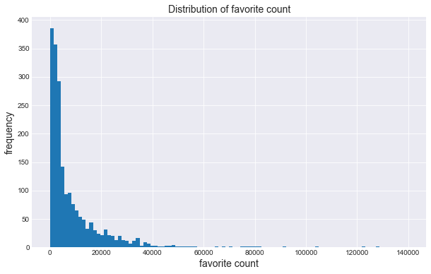

```python
bin_boundaries = np.linspace(0,140000, 101)
plt.hist(df.favorite_count, bins=bin_boundaries)
plt.xlabel('favorite count')
plt.ylabel('frequency')
plt.title('Distribution of favorite count');
```

Favorite count data appear heavily right skewed.

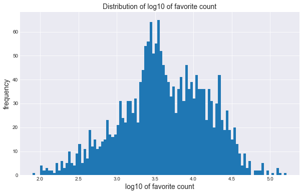

```python
log_favorite = df['favorite_count'].apply(lambda x: np.log10(x))
plt.hist(log_favorite, bins=100)
plt.xlabel('log10 of favorite count')
plt.ylabel('frequency')
plt.title('Distribution of log10 of favorite count');
```

log10 of favorite count appear somewhat normally distributed.

#### Distribution of retweet count

```python
df.retweet_count.describe()
```

```
count     1993.000000
mean      2672.776719
std       4759.302485
min         12.000000
25%        596.000000
50%       1286.000000
75%       3059.000000
max      84221.000000
Name: retweet_count, dtype: float64
```

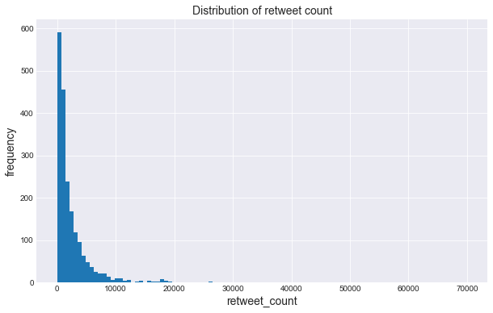

```python
plt.hist(df.retweet_count, bins=np.linspace(0,70000, 101))
plt.xlabel('retweet_count')
plt.ylabel('frequency')
plt.title('Distribution of retweet count');
```

Similar to favorite count, retweet count data appear heavily right skewed.

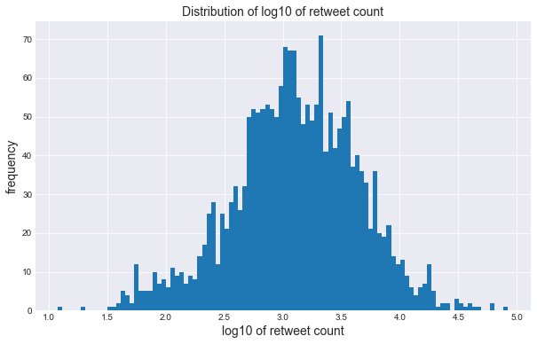

```python
log_retweet = df['retweet_count'].apply(lambda x: np.log10(x))
plt.hist(log_retweet, bins=100)
plt.xlabel('log10 of retweet count')
plt.ylabel('frequency')
plt.title('Distribution of log10 of retweet count');
```

log10 of retweet count appear somewhat normally distributed.

#### Distribution of rating numerator

```python
df.rating_numerator.describe()
```

```
count    1993.000000
mean       12.225178
std        41.481672
min         0.000000
25%        10.000000
50%        11.000000
75%        12.000000
max      1776.000000
Name: rating_numerator, dtype: float64
```

```python
rating_counts = df.groupby(['rating_numerator']).count()['tweet_id']
rating_counts
```

```
rating_numerator
0.00         3
1.00         5
2.00         9
3.00        19
4.00        16
5.00        32
6.00        32
7.00        52
8.00        95
9.00       151
9.75         1
10.00      419
11.00      396
11.26        1
11.27        1
12.00      449
13.00      261
13.50        1
14.00       35
44.00        1
45.00        1
50.00        1
60.00        1
80.00        1
84.00        1
88.00        1
99.00        1
121.00       1
143.00       1
144.00       1
165.00       1
204.00       1
420.00       1
1776.00      1
Name: tweet_id, dtype: int64
```

Most ratings are integers that are 14 and below. By checking the tweets, ratings above 20 are usually given to images that contain more than one dog.

```python
# subset dataframe to obtain rows that have ratings 14 and below and are integers
df_integer_ratings_14 = df[(df.rating_numerator <= 14) & (df.rating_numerator.apply(float.is_integer))]

# get the rating counts of the subset
subset_rating_counts = df_integer_ratings_14.groupby(['rating_numerator']).count()['tweet_id']
subset_rating_counts
```

```
rating_numerator
0.0       3
1.0       5
2.0       9
3.0      19
4.0      16
5.0      32
6.0      32
7.0      52
8.0      95
9.0     151
10.0    419
11.0    396
12.0    449
13.0    261
14.0     35
Name: tweet_id, dtype: int64
```

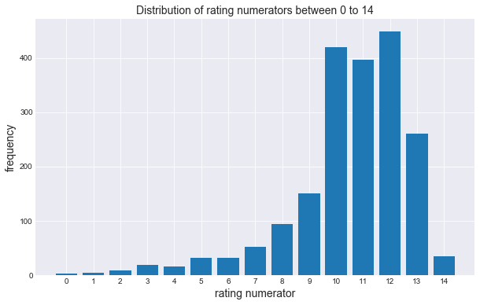

```python
# plot the bar charts for distribution of rating numerators between 0 to 14
plt.bar(np.arange(15), subset_rating_counts)
plt.xticks(np.arange(15))
plt.xlabel('rating numerator')
plt.ylabel('frequency')
plt.title('Distribution of rating numerators between 0 to 14');
```

Most images are given a rating between 10 to 13.

### Bivariate Analysis

#### Favorite count over time

```python
# The date of origin of "they're good dogs Brent" meme
good_dogs_meme_date = pd.to_datetime('2016-9-12')
```

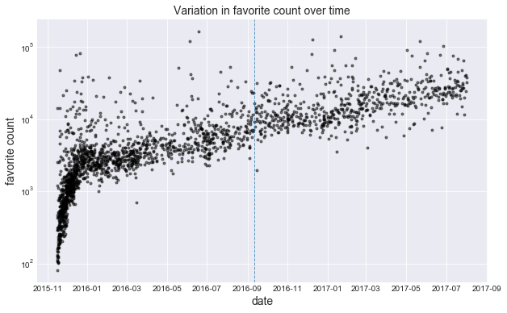

```python
fig, ax = plt.subplots()
ax.plot_date(df.timestamp, df.favorite_count, alpha=0.5, ms=3, c='black')
# log transform the scale
ax.set_yscale('log')
plt.xlabel('date')
plt.ylabel('favorite count')
plt.title('Variation in favorite count over time')
plt.axvline(good_dogs_meme_date, lw=1, ls='dashed', alpha=0.7);
```

Favorite count of the tweets in the WeRateDogs page increased rapidly between November 2015 and January 2016. Afterwards, there has been a steady increase over time. The date of origin of the ["they're good dogs Brent"](https://knowyourmeme.com/memes/theyre-good-dogs-brent) meme is represented by the dash line. It seems that the appearance of the meme does not really affect the rate of increase in favorite count.

#### Retweet count over time

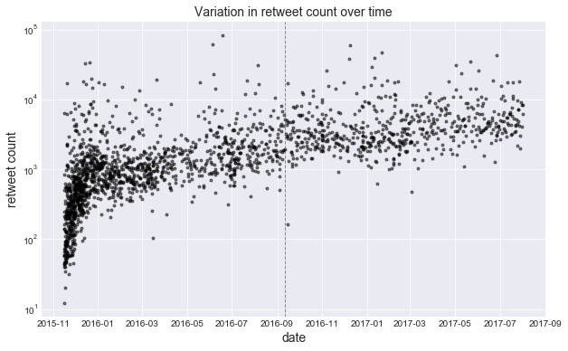

```python
fig, ax = plt.subplots()
ax.plot_date(df.timestamp, df.retweet_count, alpha=0.5, ms=3, c='black')
# log transform the scale
ax.set_yscale('log')
plt.xlabel('date')
plt.ylabel('retweet count')
plt.title('Variation in retweet count over time')
plt.axvline(good_dogs_meme_date, lw=1, ls='dashed', alpha=0.7);
```

Similar to favorite counts, retweet counts increased rapidly between November 2015 and January 2016 and afterwards show a steady increase. The date of origin of the ["they're good dogs Brent"](https://knowyourmeme.com/memes/theyre-good-dogs-brent) meme is represented by the dash line. It seems that the appearance of the meme also does not seem to affect the rate of increase in retweet count.

#### Ratings numerator over time

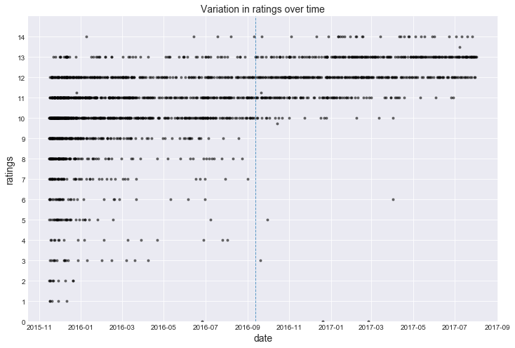

```python
plt.figure(figsize=(12,8))
plt.plot_date(df.timestamp, df.rating_numerator, alpha=0.5, ms=3, c='black')
plt.ylim(0, 15)
plt.yticks(np.arange(15))
plt.xlabel('date')
plt.ylabel('ratings')
plt.title('Variation in ratings over time')
plt.axvline(good_dogs_meme_date, lw=1, ls='dashed', alpha=0.7);
```

In general, the ratings seem to increase over time. Interestingly, since the "they're good dogs Brent" incident, almost all dogs are given a rating above 10.

# References

Convert Tweepy Status Object into JSON https://stackoverflow.com/questions/27900451/convert-tweepy-status-object-into-json

The structure of the Status object of Tweepy https://gist.github.com/dev-techmoe/ef676cdd03ac47ac503e856282077bf2

Twitter API - get tweets with specific id https://stackoverflow.com/questions/28384588/twitter-api-get-tweets-with-specific-id

Tweepy documentation http://tweepy.readthedocs.io/en/v3.5.0/index.html

Reading and Writing JSON to a File in Python http://stackabuse.com/reading-and-writing-json-to-a-file-in-python/

Clear cell output in a loop https://stackoverflow.com/questions/24816237/ipython-notebook-clear-cell-output-in-code

Use astype() when NaN is present in pandas series https://stackoverflow.com/questions/41550746/error-using-astype-when-nan-exists-in-a-dataframe